# TeilB

### Name: Nikoleta van Welbergen

Praktische Prüfung im Prüfungsfach Actuarial Data Science Immersion  
Zeitraum: 05.04.2026 – 05.05.2026,  
Teil B  
"Tarifierung & Modellierung"

Dieser Teil umfasst die praktische Umsetzung statistischer und maschineller Lernverfahren zur Modellierung von Schadenhäufigkeit (Frequency), Schadendurchschnitt (Severity) sowie Schadenbedarf (Pure Premium) auf Basis des in Teil A aufbereiteten Datensatzes.

### Layout-Vorbereitung

Hier bereite ich das Layout für die Aufgaben und das Inhaltsverzeichnis der HTML-Datei vor, die als Ergebnis dieses Notebooks generiert wird.

Dieser Schritt ist kein notwendiger Teil der Prüfung. Er dient jedoch dazu, das Layout mit meinem Teil A der Prüfung zu synchronisieren.

```python
# --- Jupyter-Komfort ---
from IPython.display import HTML, display,Image

display(HTML("""
<style>
#toc {
    width: 230px;
    left: 10px;
}

body {
    margin-left: 260px;
    margin-right: 20px;
    max-width: calc(100vw - 300px);
}
/* TOC Sidebar */
#toc {
    position: fixed;
    left: 10px;
    top: 20px;
    width: 230px;
    max-height: 90%;
    overflow-y: auto;
    padding: 10px;
    background: #f7f7f7;
    border-radius: 10px;
    box-shadow: 2px 2px 6px rgba(0,0,0,0.2);
    font-size: 11pt;
}

#toc h2 {
    font-size: 13pt;
}

#toc a {
    text-decoration: none;
    color: #2b8cbe;
}

#toc a:hover {
    text-decoration: underline;
}

/* Section spacing */
.section {
    margin-top: 40px;
}

</style>
"""))


from IPython.display import HTML, display

# CSS + Funktionen
display(HTML("""
<style>
.exercise {
    display: block;
    font-style: italic;
    font-size: 12pt;
    font-family: "Times New Roman", Times, serif;
    text-align: justify;
    color: black;
    border-radius: 10px;
    background-color: rgb(236,231,242);
    box-shadow: 5px 10px 8px #888888;
    margin: 18px 0 22px 0;
    overflow: hidden;
}

.exercise-header {
    font-weight: bold;
    font-style: normal;
    text-align: left;
    color: white;
    padding: 10px 15px 8px 15px;
    background-color: rgb(43,140,190);
    border-radius: 10px 10px 0 0;
    font-size: 13pt;
}

.exercise-body {
    padding: 15px 18px 18px 18px;
}

.exercise-part {
    display: block;
    font-style: italic;
    font-size: 12pt;
    font-family: "Times New Roman", Times, serif;
    text-align: justify;
    color: black;
    border-radius: 10px;
    background-color: rgb(236,231,242);
    box-shadow: 5px 10px 8px #888888;
    padding: 15px 18px 18px 18px;
    margin: 14px 0;
}

.exercise-part-title {
    font-weight: bold;
    font-style: normal;
    margin-bottom: 8px;
    color: black;
    font-size: 12.5pt;
}
</style>
"""))

###Warnings ausschalten
import warnings
warnings.filterwarnings("ignore")
```

B1: Regressionsmodelle für die Schadenhäufigkeit

*[Lernziele: 2.1, 2.2, 3.4 & 5.1 | Punkte: 29]*  
Ziel dieses Abschnittes ist es, die Schadenanzahl bzw. Schadenfrequenz (Frequency) des in Teil A aufbereiteten Datensatzes mit verschiedenen statistischen und maschinellen Lernverfahren zu modellieren. Aufgabe B1 konzentriert sich dabei auf Regressionsmodelle. Bearbeiten Sie die Teilaufgaben in der angegebenen Reihenfolge und dokumentieren Sie Ihre Vorgehensweise nachvollziehbar (insb. Datenaufbereitung, Modellannahmen, Tuning und Evaluation).  
Referenzen:  
[1][https://aktuar.de/de/wissen/fachinformationen/detail/schadenhaeufigkeitsmodellierungin- der-schadentarifierung-mit-glm-deep-learning-und-gradient-boosting-2/ (DE)](https://aktuar.de/de/wissen/fachinformationen/detail/schadenhaeufigkeitsmodellierung-in-der-schadentarifierung-mit-glm-deep-learning-und-gradient-boosting-2/)  
[2][https://aktuar.de/en/knowledge/specialist-information/detail/claim-frequency-modelingin-insurance-pricing-using-glm-deep-learning-and-gradient-boosting/ (EN)](https://aktuar.de/en/knowledge/specialist-information/detail/claim-frequency-modeling-in-insurance-pricing-using-glm-deep-learning-and-gradient-boosting/)

a) Vorbereitungen

Binden Sie die verwendeten Bibliotheken ein bzw. installieren Sie diese bei Bedarf. Achten Sie darauf, nur Pakete zu verwenden, die im Verlauf des Notebooks tatsächlich benötigt werden, und stellen Sie die Reproduzierbarkeit sicher. Lesen Sie anschließend den in Teil A aufbereiteten Datensatz ein. Geben Sie die ersten zehn Zeilen des Datensatzes aus und prüfen Sie anhand von mindestens zwei Kennzahlen, dass das Einlesen erfolgreich war (z. B. Dimensionen, fehlende Werte, Datentypen, einfache Summen-/Mittelwertchecks). Diskutieren Sie, welche Features für ein Tarifierungsmodell sinnvoll verwendet werden können und welche auszuschließen sind. Entfernen Sie ungeeignete Features anschließend aus dem Datensatz. Geben Sie für jedes verbleibende Feature den Datentyp sowie die Anzahl eindeutiger Ausprägungen an. Passen Sie die Datentypen bei Bedarf an; falls erforderlich, transformieren Sie den Datensatz so, dass dieser nur noch numerische Features enthält. Definieren Sie abschließend die beiden Variablen var_cat und var_num, indem – var_cat alle kategorialen Features und – var_num alle numerischen Features enthält. Geben Sie var_cat und var_num aus und begründen Sie Ihre Zuordnung. Gehen Sie insbesondere darauf ein, worauf bei kategorialen Features zu achten ist, und nehmen Sie ggf. Anpassungen vor.

## **Lösung:**

### Bibliotheken ( Binden & bei Bedarf Installieren) & Reproduzierbarkeit

#### Prüfung und Installation benötigter Pakete

In dieser Code-Zelle wird überprüft, ob die für das Notebook benötigten Python-Pakete installiert sind und ob sie in den gewünschten Versionen vorliegen.

```python
import importlib
import subprocess  # Für Shell-Commands wie pip install
import sys

# ===============================
# Pakete + gewünschte Versionen
# ===============================
required_packages = {
    "numpy": "1.24.3",
    "pandas": "2.0.3",
    "graphviz": "0.21",
    "matplotlib": "3.7.2",
    "pydot": "1.4.2",
    "seaborn": "0.12.2",
    "scikit-learn": "1.3.0",
    "statsmodels": "0.14.0",
    "pygam": "0.12.0",
    "catboost": "1.2.10",
    "lightgbm": "4.6.0",
    "xgboost": "2.1.1",
    "optuna": "4.8.0",
    "keras": "2.15.0",
    "tensorflow": "2.15.0"

}

# ===============================
# Zuordnung: Paketname für pip / Importname für Python
# ===============================
import_names = {
    "scikit-learn": "sklearn",
}

# ===============================
# Funktion
# ===============================
def install_if_needed(pkg, version):
    import_name = import_names.get(pkg, pkg)

    try:
        module = importlib.import_module(import_name)
        installed_version = getattr(module, "__version__", "unknown")

        if installed_version != version:
            print(f"{pkg}: Version {installed_version} gefunden, benötige aber {version}")
            subprocess.check_call([
                sys.executable, "-m", "pip", "install", f"{pkg}=={version}"
            ])
        else:
            print(f"{pkg}=={version} korrekt installiert")

    except ImportError:
        print(f"{pkg} fehlt: installiere Version {version} ...")
        subprocess.check_call([
            sys.executable, "-m", "pip", "install", f"{pkg}=={version}"
        ])

# ===============================
# Ausführen
# ===============================
for pkg, ver in required_packages.items():
    install_if_needed(pkg, ver)
```

```
numpy==1.24.3 korrekt installiert
pandas==2.0.3 korrekt installiert
graphviz==0.21 korrekt installiert
matplotlib==3.7.2 korrekt installiert
pydot==1.4.2 korrekt installiert
seaborn==0.12.2 korrekt installiert
scikit-learn==1.3.0 korrekt installiert
statsmodels==0.14.0 korrekt installiert
pygam==0.12.0 korrekt installiert
catboost==1.2.10 korrekt installiert
lightgbm==4.6.0 korrekt installiert
xgboost==2.1.1 korrekt installiert
optuna==4.8.0 korrekt installiert
WARNING:tensorflow:From C:\Users\nvanw\anaconda3\Lib\site-packages\keras\src\losses.py:2976: The name tf.losses.sparse_softmax_cross_entropy is deprecated. Please use tf.compat.v1.losses.sparse_softmax_cross_entropy instead.

keras==2.15.0 korrekt installiert
tensorflow==2.15.0 korrekt installiert
```

Im nächsten Schritt werden alle Bibliotheken importiert, die für Teil B des Notebooks benötigt werden. Die Importe sind nach Themenbereichen sortiert, damit die Struktur übersichtlich bleibt.

```python
# ===============================
# Bibliotheken importieren
# ===============================

# Standardbibliotheken
import os
import platform
import random
import sys
import time
from importlib.metadata import PackageNotFoundError, version
from pathlib import Path
from itertools import product

# Datenverarbeitung
import numpy as np
import pandas as pd


# Visualisierung
import graphviz
import matplotlib.pyplot as plt #B1d
import pydot
import seaborn as sns           #B1f

# Machine Learning: Scikit-Learn
from sklearn.ensemble import RandomForestRegressor  # B2a), B3c)
from sklearn.model_selection import train_test_split  # B1b) Zerlegung in Training, Validierung, Test
from sklearn.preprocessing import MinMaxScaler, QuantileTransformer, StandardScaler  # B1e), B1f)
from sklearn.pipeline import Pipeline  #B4 b)
from sklearn.linear_model import TweedieRegressor #B4b)
from sklearn.metrics import auc #Bae)


# Statistik / klassische Modelle
import statsmodels.api as sm  # B1c), B1d)
import statsmodels.formula.api as smf  # B1c) GLM mit R-like Formula
from pygam import GammaGAM, l, s  # B3d)

# Gradient-Boosting-Modelle
from catboost import CatBoostRegressor  # B3c)
import lightgbm as lgb  # B2b)
import xgboost as xgb  # B2b)
from lightgbm import LGBMRegressor #B4c)
from xgboost import XGBRegressor #B4d)

# Hyperparameter-Optimierung
import optuna  # B2b)

# Deep Learning
import keras             # B1f)
import tensorflow as tf  # B1f)
from keras import layers, regularizers
from tensorflow.keras.utils import plot_model  # B1f) Visualisierung
from tensorflow.keras import initializers

# ===============================
# verwendete Pakete
# ===============================
packages = [
    "numpy",
    "pandas",
    "graphviz",
    "matplotlib",
    "pydot",
    "seaborn",
    "scikit-learn",
    "statsmodels",
    "pygam",
    "catboost",
    "lightgbm",
    "xgboost",
    "optuna",
    "keras",
    "tensorflow"
]

# ===============================
# Ausgabe
# ===============================
print("=== Systeminformationen ===")
print("Python:", sys.version)
print("Plattform:", platform.platform())

print("\n=== Paketversionen ===")
for pkg in packages:
    try:
        print(f"{pkg}: {version(pkg)}")
    except PackageNotFoundError:
        print(f"{pkg}: NICHT installiert")
```

```
=== Systeminformationen ===
Python: 3.11.5 | packaged by Anaconda, Inc. | (main, Sep 11 2023, 13:26:23) [MSC v.1916 64 bit (AMD64)]
Plattform: Windows-10-10.0.26200-SP0

=== Paketversionen ===
numpy: 1.24.3
pandas: 2.0.3
graphviz: 0.21
matplotlib: 3.7.2
pydot: 1.4.2
seaborn: 0.12.2
scikit-learn: 1.3.0
statsmodels: 0.14.0
pygam: 0.12.0
catboost: 1.2.10
lightgbm: 4.6.0
xgboost: 2.1.1
optuna: 4.8.0
keras: 2.15.0
tensorflow: 2.15.0
```

#### Reproduzierbarkeit

Diese Zelle legt einen festen Zufallswert (`RANDOM_SEED`) fest, damit zufallsbasierte Berechnungen mit `numpy`, `random` und `tensorflow` möglichst reproduzierbar ausgeführt werden.

```python
# Sicherstellung der Reproduzierbarkeit
RANDOM_SEED = 2484
np.random.seed(RANDOM_SEED)
random.seed(RANDOM_SEED)
tf.random.set_seed(RANDOM_SEED)
os.environ["PYTHONHASHSEED"] = str(RANDOM_SEED)
```

Diese Zelle passt die Anzeigeoptionen von `pandas` so an, dass Fließkommazahlen mit sechs Nachkommastellen und ohne wissenschaftliche Notation dargestellt werden.

```python
# --- Anzeigeoptionen ---
pd.set_option('display.float_format', '{:.6f}'.format) #kein wisseschaftliche Notation der Zahlen
```

### Daten einlesen aus Aufgabe A4b

Der aufbereitete Datensatz wurde im Ordner `data` unter dem Namen `Prepared_Data.csv` gespeichert. In diesem Abschnitt wird die Datei als DataFrame mit dem Namen `Input_Data` eingelesen. Zur Überprüfung des erfolgreichen Einlesens werden die ersten zehn Zeilen des Datensatzes angezeigt. Zusätzlich werden die Dimensionen des Datensatzes sowie mögliche fehlende Werte betrachtet.

```python
file_path = Path("Data") / "Prepared_data.csv"

Input_data = pd.read_csv(file_path, sep=";", decimal=".")
file_path = Path("Data") / "dim_sum_check.csv"
dim_sum_check =pd.read_csv(file_path, sep=";", decimal=".")

Input_data.head(10)
```

|  | Distribution_channel | Seniority | Lapse | Payment | Premium | Cost_claims_year | N_claims_year | Area | Second_driver | Power | Cylinder_capacity | Value_vehicle | N_doors | Type_fuel | Weight | DrivAge | DrivLicenceAge | VehAge | Exposure |
| --- | --- | --- | --- | --- | --- | --- | --- | --- | --- | --- | --- | --- | --- | --- | --- | --- | --- | --- | --- |
| 0 | 0 | 15 | 0 | 0 | 393.500000 | 0.000000 | 0 | 0 | 0 | 85 | 1229 | 16030.000000 | 5 | P | 1105 | 41 | 21 | 3 | 1.000000 |
| 1 | 0 | 13 | 0 | 0 | 250.520000 | 0.000000 | 0 | 0 | 0 | 87 | 1598 | 9927.000000 | 4 | P | 1055 | 49 | 25 | 10 | 1.000000 |
| 2 | 1 | 3 | 0 | 0 | 340.430000 | 2162.890000 | 3 | 0 | 0 | 109 | 1396 | 16550.000000 | 5 | P | 1168 | 69 | 15 | 7 | 1.000000 |
| 3 | 0 | 18 | 0 | 0 | 335.820000 | 0.000000 | 0 | 0 | 0 | 130 | 1984 | 27330.000000 | 4 | P | 1310 | 75 | 53 | 15 | 1.000000 |
| 4 | 1 | 6 | 0 | 0 | 259.120000 | 0.000000 | 0 | 0 | 1 | 65 | 1870 | 13140.000000 | 5 | D | 1125 | 67 | 21 | 3 | 1.000000 |
| 5 | 0 | 3 | 0 | 0 | 248.680000 | 0.000000 | 0 | 1 | 0 | 75 | 1390 | 8548.000000 | 4 | P | 1050 | 65 | 39 | 9 | 1.000000 |
| 6 | 1 | 4 | 0 | 1 | 437.320000 | 0.000000 | 0 | 1 | 1 | 90 | 1396 | 19390.000000 | 5 | D | 1355 | 65 | 44 | 1 | 1.000000 |
| 7 | 1 | 4 | 0 | 1 | 314.300000 | 0.000000 | 0 | 0 | 0 | 100 | 1396 | 16190.000000 | 5 | P | 1110 | 70 | 41 | 1 | 1.000000 |
| 8 | 0 | 19 | 0 | 0 | 461.410000 | 0.000000 | 0 | 0 | 0 | 103 | 1596 | 15205.610000 | 3 | P | 1145 | 61 | 25 | 15 | 1.000000 |
| 9 | 0 | 10 | 0 | 1 | 347.280000 | 0.000000 | 0 | 1 | 0 | 110 | 1590 | 17000.000000 | 3 | P | 1154 | 58 | 38 | 15 | 1.000000 |

```python
print("Dimensionen des Datensatzes:")
print(f"Zeilen: {Input_data.shape[0]}, Spalten: {Input_data.shape[1]}")
```

```
Dimensionen des Datensatzes:
Zeilen: 15874, Spalten: 19
```

```python
print("\nFehlende Werte pro Spalte:")
print(Input_data.isna().sum())
```

```
Fehlende Werte pro Spalte:
Distribution_channel    0
Seniority               0
Lapse                   0
Payment                 0
Premium                 0
Cost_claims_year        0
N_claims_year           0
Area                    0
Second_driver           0
Power                   0
Cylinder_capacity       0
Value_vehicle           0
N_doors                 0
Type_fuel               0
Weight                  0
DrivAge                 0
DrivLicenceAge          0
VehAge                  0
Exposure                0
dtype: int64
```

Wir zeigen die Datentypen aller Spalten von `Input_data` an, um die Struktur des eingelesenen Datensatzes zu überprüfen.

```python
print(Input_data.dtypes)
```

```
Distribution_channel      int64
Seniority                 int64
Lapse                     int64
Payment                   int64
Premium                 float64
Cost_claims_year        float64
N_claims_year             int64
Area                      int64
Second_driver             int64
Power                     int64
Cylinder_capacity         int64
Value_vehicle           float64
N_doors                   int64
Type_fuel                object
Weight                    int64
DrivAge                   int64
DrivLicenceAge            int64
VehAge                    int64
Exposure                float64
dtype: object
```

Hier führen wir eine schnelle Plausibilitätsprüfung des Datensatzes mit der Funktion `describe()` durch:

```python
Input_data.describe()
```

|  | Distribution_channel | Seniority | Lapse | Payment | Premium | Cost_claims_year | N_claims_year | Area | Second_driver | Power | Cylinder_capacity | Value_vehicle | N_doors | Weight | DrivAge | DrivLicenceAge | VehAge | Exposure |
| --- | --- | --- | --- | --- | --- | --- | --- | --- | --- | --- | --- | --- | --- | --- | --- | --- | --- | --- |
| count | 15874.000000 | 15874.000000 | 15874.000000 | 15874.000000 | 15874.000000 | 15874.000000 | 15874.000000 | 15874.000000 | 15874.000000 | 15874.000000 | 15874.000000 | 15874.000000 | 15874.000000 | 15874.000000 | 15874.000000 | 15874.000000 | 15874.000000 | 15874.000000 |
| mean | 0.451178 | 7.490425 | 0.047625 | 0.346038 | 335.254700 | 304.107634 | 0.638906 | 0.300617 | 0.116858 | 98.384213 | 1663.413884 | 18670.896788 | 4.460060 | 1212.715258 | 45.579501 | 22.886607 | 10.940280 | 0.977735 |
| std | 0.497626 | 6.451712 | 0.213274 | 0.475720 | 131.893257 | 2687.679498 | 1.199609 | 0.458541 | 0.321261 | 29.405793 | 367.404956 | 7782.031160 | 0.844458 | 216.612307 | 13.011982 | 12.258755 | 5.339311 | 0.106023 |
| min | 0.000000 | 1.000000 | 0.000000 | 0.000000 | 44.420000 | 0.000000 | 0.000000 | 0.000000 | 0.000000 | 13.000000 | 479.000000 | 270.460000 | 2.000000 | 380.000000 | 18.000000 | 0.000000 | 0.000000 | 0.010929 |
| 25% | 0.000000 | 3.000000 | 0.000000 | 0.000000 | 258.205000 | 0.000000 | 0.000000 | 0.000000 | 0.000000 | 75.000000 | 1398.000000 | 13650.000000 | 4.000000 | 1060.000000 | 35.000000 | 13.000000 | 8.000000 | 1.000000 |
| 50% | 0.000000 | 5.000000 | 0.000000 | 0.000000 | 301.650000 | 0.000000 | 0.000000 | 0.000000 | 0.000000 | 95.000000 | 1598.000000 | 17529.840000 | 5.000000 | 1199.000000 | 44.000000 | 21.000000 | 11.000000 | 1.000000 |
| 75% | 1.000000 | 9.000000 | 0.000000 | 1.000000 | 366.225000 | 81.607500 | 1.000000 | 1.000000 | 0.000000 | 110.000000 | 1896.000000 | 21955.000000 | 5.000000 | 1340.000000 | 55.000000 | 32.000000 | 14.000000 | 1.000000 |
| max | 1.000000 | 40.000000 | 2.000000 | 1.000000 | 2797.510000 | 260853.240000 | 10.000000 | 1.000000 | 1.000000 | 480.000000 | 5987.000000 | 170323.000000 | 6.000000 | 2602.000000 | 95.000000 | 61.000000 | 62.000000 | 1.000000 |

#### Datentypen anpassen

In diesem Abschnitt passen wir die Datentypen an, indem wir die kategorialen Merkmale entsprechend definieren.

```python
categorical_cols = [
    "Distribution_channel",
    "Payment",
    "Area",
    "Second_driver",
    "N_doors",
    "Type_fuel"
]

Input_data[categorical_cols] =Input_data[categorical_cols].astype("category")
print(Input_data.dtypes)
```

```
Distribution_channel    category
Seniority                  int64
Lapse                      int64
Payment                 category
Premium                  float64
Cost_claims_year         float64
N_claims_year              int64
Area                    category
Second_driver           category
Power                      int64
Cylinder_capacity          int64
Value_vehicle            float64
N_doors                 category
Type_fuel               category
Weight                     int64
DrivAge                    int64
DrivLicenceAge             int64
VehAge                     int64
Exposure                 float64
dtype: object
```

#### Erfolg des Einlesen messen

Um den Erfolg des Einlesens zu überprüfen, führen wir folgende Schritte aus:

1. Wir berechnen die Summen aller numerischen Spalten von `Input_data` und geben sie als übersichtliche Tabelle mit der Spalte `Summe` aus.
2. Wir vergleichen diese berechneten Summen mit den gelieferten Summen aus der Datei `dim_sum_check` aus Aufgabe A4b.
3. Anschließend zeigen wir, dass die Summen übereinstimmen.

```python
numeric_sums_df = Input_data.sum(numeric_only=True).to_frame(name="Summe")
# Zeilen- und Spaltenanzahl ergänzen
numeric_sums_df.loc["rows", "Summe"] = Input_data.shape[0]
numeric_sums_df.loc["columns", "Summe"] = Input_data.shape[1]
print(numeric_sums_df)
```

```
                             Summe
Seniority            118903.000000
Lapse                   756.000000
Premium             5321833.110000
Cost_claims_year    4827404.580000
N_claims_year         10142.000000
Power               1561751.000000
Cylinder_capacity  26405032.000000
Value_vehicle     296381815.610000
Weight             19250642.000000
DrivAge              723529.000000
DrivLicenceAge       363302.000000
VehAge               173666.000000
Exposure              15520.571151
rows                  15874.000000
columns                  19.000000
```

Die gelieferte Summen aus der Datei `dim_sum_check` aus Aufgabe A4b sind:

```python
# dim_sum_check transponieren und Spalte umbenennen
dim_sum_check_t = dim_sum_check.T.rename(columns={0: "Summe_Check"})
dim_sum_check_t
```

|  | Summe_Check |
| --- | --- |
| rows | 15874.000000 |
| columns | 19.000000 |
| Distribution_channel | NaN |
| Seniority | 118903.000000 |
| Lapse | 756.000000 |
| Payment | NaN |
| Premium | 5321833.110000 |
| Cost_claims_year | 4827404.580000 |
| N_claims_year | 10142.000000 |
| Area | NaN |
| Second_driver | NaN |
| Power | 1561751.000000 |
| Cylinder_capacity | 26405032.000000 |
| Value_vehicle | 296381815.610000 |
| N_doors | NaN |
| Type_fuel | NaN |
| Weight | 19250642.000000 |
| DrivAge | 723529.000000 |
| DrivLicenceAge | 363302.000000 |
| VehAge | 173666.000000 |
| Exposure | 15520.571151 |

Die gelieferten Summen und Dimensionen aus `dim_sum_check` werden mit den direkt aus den eingelesenen Daten `Input_data` berechneten Summen und Dimensionen verglichen.

```python
# Nur Indices verwenden, die in dim_sum_check_t nicht NaN sind
valid_indices = dim_sum_check_t.index[dim_sum_check_t["Summe_Check"].notna()]


# Vergleichstabelle erstellen
comparison_df = numeric_sums_df.loc[valid_indices].join(
    dim_sum_check_t.loc[valid_indices],
    how="inner"
)

comparison_df["Differenz"] = comparison_df["Summe"] - comparison_df["Summe_Check"]

comparison_df["Gleich"] = np.isclose(
    comparison_df["Summe"],
    comparison_df["Summe_Check"],
    equal_nan=True
)

comparison_df
```

|  | Summe | Summe_Check | Differenz | Gleich |
| --- | --- | --- | --- | --- |
| rows | 15874.000000 | 15874.000000 | 0.000000 | True |
| columns | 19.000000 | 19.000000 | 0.000000 | True |
| Seniority | 118903.000000 | 118903.000000 | 0.000000 | True |
| Lapse | 756.000000 | 756.000000 | 0.000000 | True |
| Premium | 5321833.110000 | 5321833.110000 | -0.000000 | True |
| Cost_claims_year | 4827404.580000 | 4827404.580000 | 0.000000 | True |
| N_claims_year | 10142.000000 | 10142.000000 | 0.000000 | True |
| Power | 1561751.000000 | 1561751.000000 | 0.000000 | True |
| Cylinder_capacity | 26405032.000000 | 26405032.000000 | 0.000000 | True |
| Value_vehicle | 296381815.610000 | 296381815.610000 | 0.000000 | True |
| Weight | 19250642.000000 | 19250642.000000 | 0.000000 | True |
| DrivAge | 723529.000000 | 723529.000000 | 0.000000 | True |
| DrivLicenceAge | 363302.000000 | 363302.000000 | 0.000000 | True |
| VehAge | 173666.000000 | 173666.000000 | 0.000000 | True |
| Exposure | 15520.571151 | 15520.571151 | 0.000000 | True |

Damit wurde das Einlesen des Datensatzes erfolgreich abgeschlossen.

### Diskussion über geeignete Features für ein Tarifierungsmodell

Für ein Tarifierungsmodell werden ausschließlich exogene Risikomerkmale verwendet. Variablen, die Informationen über bereits eingetretene Schäden oder Zielgrößen (Schadenanzahl bzw. Schadenfrequency) enthalten, werden ausgeschlossen, um Datenleakage zu vermeiden.

Die folgenden Variablen werden ausgeschlossen:

- `Cost_claims_year`: enthält direkte Schadenkosten ( Data Leakage)
- `N_claims_year` : Zielvariable
- `Premium` : wird basierend auf Schadenzahlen berechnet also es ist bereits berechnete Tarifgröße (endogen)

Diese Variablen würden zu unrealistisch guten Modellen führen.

Typischerweise sinnvoll für Tarifierung sind folgende Merkmale, die wir dann behalten wollen:

- Fahrerdaten: `DrivAge`, `DrivLicenceAge`
- Fahrzeugsdaten: `Power`, `Value_vehicle`, `Weight`,`Cylinder_capacity`,`N_doors`, `Type_fuel`,`VehAge`
- Vertragsdaten & Nutzung: `Distribution_channel`(Vertriebsweg), `Payment`(Zahlweise), `Area` (vereinfachte Regionalklasse), `Second_driver` (Zweitfahrer vorhanden Ja/Nein).
- **Exposure** wird nicht als Feature benutzt sondern als Offset und Gewichtung bei Evaluation

### Vorbereitungen des selektierten Features

#### Die Auswahl

```python
#Zielvariable definieren
target = "N_claims_year"

# zu entfernende Variablen
drop_cols = ["Cost_claims_year", "Premium"]

df_freq_model = Input_data.drop(columns=drop_cols)
```

#### Datentypen & Ausprägungen

```python
summary = []

for col in df_freq_model.columns:
    summary.append({
        "Feature": col,
        "Datentyp": str(df_freq_model[col].dtype),
        "Anzahl_Ausprägungen": df_freq_model[col].nunique()
    })
summary_df = pd.DataFrame(summary)

summary_df
```

|  | Feature | Datentyp | Anzahl_Ausprägungen |
| --- | --- | --- | --- |
| 0 | Distribution_channel | category | 2 |
| 1 | Seniority | int64 | 40 |
| 2 | Lapse | int64 | 3 |
| 3 | Payment | category | 2 |
| 4 | N_claims_year | int64 | 11 |
| 5 | Area | category | 2 |
| 6 | Second_driver | category | 2 |
| 7 | Power | int64 | 185 |
| 8 | Cylinder_capacity | int64 | 326 |
| 9 | Value_vehicle | float64 | 4198 |
| 10 | N_doors | category | 5 |
| 11 | Type_fuel | category | 2 |
| 12 | Weight | int64 | 841 |
| 13 | DrivAge | int64 | 62 |
| 14 | DrivLicenceAge | int64 | 60 |
| 15 | VehAge | int64 | 50 |
| 16 | Exposure | float64 | 197 |

Die Datentypen sind richtig, da wir schon beim Einlesen die Datentypen angepasst haben.

#### var_cat und var_num definieren

Wir haben die kategorialen Variablen bereits zuvor mit `categorical_cols` definiert. Da keine kategoriale Variable ausgeschlossen wurde, bleibt die Menge der kategorialen Variablen unverändert.

Das heißt, die folgenden Variablen sind kategorial:

```python
var_cat = categorical_cols
print("Kategoriale Features:")
print(var_cat)
```

```
Kategoriale Features:
['Distribution_channel', 'Payment', 'Area', 'Second_driver', 'N_doors', 'Type_fuel']
```

Die restliche Variablen sind numerisch:

```python
var_num = [
    col for col in df_freq_model.columns
    if col not in categorical_cols and col != target
]

print("Numerische Features:")
print(var_num)
```

```
Numerische Features:
['Seniority', 'Lapse', 'Power', 'Cylinder_capacity', 'Value_vehicle', 'Weight', 'DrivAge', 'DrivLicenceAge', 'VehAge', 'Exposure']
```

Die kategorialen Variablen (`var_cat`) enthalten diskrete Ausprägungen ohne sinnvolle metrische Ordnung, zum Beispiel `Type_fuel` oder `Area`. Besonders wichtig ist, dass kategoriale Variablen nicht fälschlicherweise als numerisch interpretiert werden, da metrische Operationen wie Addition, Subtraktion oder Mittelwertbildung für solche Merkmale nicht sinnvoll interpretierbar sind und zu verzerrten Modellannahmen führen können.

**Die Zielvariable `N_claims_year` wird nicht in `var_num` aufgenommen, da sie die zu modellierende Größe darstellt.**

b)Datenaufbereitung

Führen Sie für die in Teilaufgabe a) identifizierten kategorialen Merkmale eine One- Hot-Kodierung durch. Berücksichtigen Sie dabei, dass die erste Kategorie als Referenzkategorie zu entfernen ist. Erzeugen Sie einen Datensatz, der – die numerischen Merkmale, – die originalen kategorialen Merkmale sowie – die One-Hot-kodierten Merkmale enthält. Sammeln Sie die Namen aller erzeugten Dummy-Merkmale in der Variablen var_cat_oh und geben Sie diese aus. Teilen Sie den Datensatz anschließend begründet in drei Teile (Training, Validierung, Test) und prüfen Sie die Zerlegung. Legen Sie eine Ergebnisdatenstruktur für die spätere Evaluation von Machine-Learning-Modellen an, die mindestens – den Modellnamen, – die Ergebnisse auf Trainings-, Validierungs- und Testdatensatz sowie – die für Modellierung bzw. Optimierung verwendete Zeit enthält. Definieren Sie zudem zwei Hilfsfunktionen, mit denen Sie (i) Einträge in diese Ergebnisdatenstruktur schreiben und (ii) die Ergebnisdatenstruktur strukturiert, kompakt und übersichtlich ausgeben können.

## **Lösung:**

Im weiteren Verlauf dieses Notebooks wird die Schadenhäufigkeit im Code mit CF abgekürzt.

### One-Hot-Kodierung

Für die kategorialen Merkmale wird eine One-Hot-Kodierung durchgeführt. Dabei wird jeweils die erste Kategorie als Referenzkategorie entfernt (`drop_first=True`).

```python
# One-Hot-Kodierung nur für die in Teil a) festgelegten kategorialen Merkmale - nur neue Merkmale und numerische Merkmale
df_freq_model_oh = pd.get_dummies(
    df_freq_model,
    columns=var_cat,
    drop_first=True,
    dtype=int
)
# Namen der erzeugten Dummy-Merkmale sammeln
original_cols = set(df_freq_model.columns)
var_cat_oh  = [col for col in df_freq_model_oh.columns if col not in original_cols]
print("Erzeugte Dummy-Merkmale:")
print(var_cat_oh)
print(f"\nAnzahl Dummy-Merkmale: {len(var_cat_oh)}")

## Originaler Datensatz + nur die Dummy-Spalten zusätzlich anhängen
df_freq_model_full = pd.concat(
    [df_freq_model.copy(), df_freq_model_oh[var_cat_oh].copy()],
    axis=1
)

print("Dimension des erweiterten Datensatzes:", df_freq_model_full.shape)
df_freq_model_full.head()
```

```
Erzeugte Dummy-Merkmale:
['Distribution_channel_1', 'Payment_1', 'Area_1', 'Second_driver_1', 'N_doors_3', 'N_doors_4', 'N_doors_5', 'N_doors_6', 'Type_fuel_P']

Anzahl Dummy-Merkmale: 9
Dimension des erweiterten Datensatzes: (15874, 26)
```

|  | Distribution_channel | Seniority | Lapse | Payment | N_claims_year | Area | Second_driver | Power | Cylinder_capacity | Value_vehicle | ... | Exposure | Distribution_channel_1 | Payment_1 | Area_1 | Second_driver_1 | N_doors_3 | N_doors_4 | N_doors_5 | N_doors_6 | Type_fuel_P |
| --- | --- | --- | --- | --- | --- | --- | --- | --- | --- | --- | --- | --- | --- | --- | --- | --- | --- | --- | --- | --- | --- |
| 0 | 0 | 15 | 0 | 0 | 0 | 0 | 0 | 85 | 1229 | 16030.000000 | ... | 1.000000 | 0 | 0 | 0 | 0 | 0 | 0 | 1 | 0 | 1 |
| 1 | 0 | 13 | 0 | 0 | 0 | 0 | 0 | 87 | 1598 | 9927.000000 | ... | 1.000000 | 0 | 0 | 0 | 0 | 0 | 1 | 0 | 0 | 1 |
| 2 | 1 | 3 | 0 | 0 | 3 | 0 | 0 | 109 | 1396 | 16550.000000 | ... | 1.000000 | 1 | 0 | 0 | 0 | 0 | 0 | 1 | 0 | 1 |
| 3 | 0 | 18 | 0 | 0 | 0 | 0 | 0 | 130 | 1984 | 27330.000000 | ... | 1.000000 | 0 | 0 | 0 | 0 | 0 | 1 | 0 | 0 | 1 |
| 4 | 1 | 6 | 0 | 0 | 0 | 0 | 1 | 65 | 1870 | 13140.000000 | ... | 1.000000 | 1 | 0 | 0 | 1 | 0 | 0 | 1 | 0 | 0 |

5 rows × 26 columns

### Aufteilung in Training, Validierung und Test

Eine fachlich sinnvolle Standardaufteilung ist wie folgt:  
Die Trainingsdaten enthalten 60 %, die Validierungsdaten 20 % und die Testdaten 20 % des gesamten verfügbaren Datensatzes.

Wie in *The Elements of Statistical Learning* (2009, Kapitel 7, S. 222) erklärt wird, gibt es zwei zentrale Ziele:

1. **Modellauswahl (Model Selection)** und Hyperparameter-Tuning
2. **Modellbewertung (Model Assessment)** des finalen Modells

Im Idealfall (bei ausreichend Daten) wird der Datensatz in drei Teile aufgeteilt:

- **Trainingsdaten** : zum Trainieren der Modelle
- **Validierungsdaten** : für Modellauswahl und Hyperparameter-Tuning
- **Testdaten**: zur Bewertung des final ausgewählten Modells

> *"The training set is used to fit the models; the validation set is used to estimate prediction error for model selection; the test set is used for assessment of the generalization error of the final chosen model."*

**Wichtig:**  
Der Testdatensatz sollte nur **einmal** verwendet werden, um eine unverzerrte Schätzung der Generalisierungsfähigkeit zu erhalten.

#### 1. Modellauswahl und Hyperparameter-Tuning

Das Modell wird auf den Trainingsdaten trainiert und auf den Validierungsdaten bewertet.

- **Hyperparameter-Tuning:**  
  Die optimalen Hyperparameter werden anhand der Validierungsleistung ausgewählt.
- **Modellauswahl:**  
  Es wird das Modell mit der besten Performance (z. B. niedrigste Fehlerfunktion) auf den Validierungsdaten gewählt.

#### 2. Modellbewertung des finalen Modells

Zur Bewertung der Generalisierungsfähigkeit wird das finale Modell auf dem Testdatensatz angewendet.

Dabei wird der Vorhersagefehler gemessen.

**Hinweis (Refit):**  
In der Literatur ist nicht einheitlich geregelt, ob das finale Modell für die Vorhersage auf die Testadaten:

- nur auf den Trainingsdaten trainiert wird oder
- nach der Modellauswahl auf **Trainings + Validierungsdaten** neu trainiert wird (*Refit*)

In vielen Machine-Learning-Frameworks wie `sklearn` (z. B. `GridSearchCV`) oder R-Paketen wie `caret` wird standardmäßig ein Refit durchgeführt, bei dem das Modell nach der Hyperparameteroptimierung auf allen verfügbaren Trainings + Validierungsdaten neu trainiert wird.

**Hinweis -Weitere Aufteilungstrategien**

Bei Schadenfrequenzdaten ist die Zielvariable häufig **stark unbalanciert**. Das bedeutet, dass sehr viele Verträge keine oder nur sehr wenige Schäden aufweisen, während nur ein kleiner Anteil der Beobachtungen eine höhere Schadenanzahl besitzt.

Dieses Muster ist in Versicherungdaten typisch: Die meisten Versicherungsnehmer verursachen im Beobachtungszeitraum keinen Schaden, wodurch die Zielvariable viele Nullwerte enthält. Gleichzeitig können einzelne Beobachtungen mit mehreren Schäden auftreten. Dadurch entsteht eine schiefe und unausgeglichene Verteilung.

Eine mögliche Vorgehensweise wäre eine stratifizierte Aufteilung, bei der die Verteilung der Zielvariable in Trainings-, Validierungs- und Testdaten gezielt ähnlich gehalten wird. Bei einer Zählvariable wie `N_claims_year` ist dies jedoch nicht immer sinnvoll oder stabil, insbesondere wenn einige Schadenanzahlen nur sehr selten vorkommen.

Daher führen wir hier keine zusätzliche Balancierung oder spezielle stratifizierte Aufteilung durch. Stattdessen verwenden wir eine zufällige, reproduzierbare Zerlegung des Datensatzes und prüfen anschließend, ob die Verteilung der Zielvariable in den drei Teilmengen plausibel vergleichbar bleibt.

Diese Vorgehensweise ist für die Modellierung mit Poisson- bzw. Frequenzmodellen angemessen, da die unausgeglichene Struktur der Schadenanzahl ein natürlicher Bestandteil der Daten ist und nicht künstlich verändert werden soll.

```python
# Features und Ziel
X = df_freq_model_full.drop(columns=[target])
y = df_freq_model_full[target]

# 1. Schritt: Train (60%) und Temp (40%)
X_train, X_temp, y_train, y_temp = train_test_split(
    X, y,
    test_size=0.40,
    random_state=RANDOM_SEED
)

# 2. Schritt: Temp in Validierung (20%) und Test (20%) teilen
X_valid, X_test, y_valid, y_test = train_test_split(
    X_temp, y_temp,
    test_size=0.50,
    random_state=RANDOM_SEED
)

print("Dimensionen der Datensätze:")
print("X_train:", X_train.shape, "| y_train:", y_train.shape)
print("X_valid:", X_valid.shape, "| y_valid:", y_valid.shape)
print("X_test: ", X_test.shape,  "| y_test: ", y_test.shape)
print("X_train-Spalten:",X_train.columns)
```

```
Dimensionen der Datensätze:
X_train: (9524, 25) | y_train: (9524,)
X_valid: (3175, 25) | y_valid: (3175,)
X_test:  (3175, 25) | y_test:  (3175,)
X_train-Spalten: Index(['Distribution_channel', 'Seniority', 'Lapse', 'Payment', 'Area',
       'Second_driver', 'Power', 'Cylinder_capacity', 'Value_vehicle',
       'N_doors', 'Type_fuel', 'Weight', 'DrivAge', 'DrivLicenceAge', 'VehAge',
       'Exposure', 'Distribution_channel_1', 'Payment_1', 'Area_1',
       'Second_driver_1', 'N_doors_3', 'N_doors_4', 'N_doors_5', 'N_doors_6',
       'Type_fuel_P'],
      dtype='object')
```

```python
def check_split(X_df,y, name):
    print(f"\n{name}")
    print("N:", len(X_df))
    print("Median Claims:", y.median())
    print("Sum Exposure:", X_df["Exposure"].sum())
    print(f"CF: {(y.sum()/X_df['Exposure'].sum())*100:.4f}%")

check_split(X_train,y_train, "Train")
check_split(X_valid,y_valid, "Validation")
check_split(X_test,y_test,"Test")
```

```
Train
N: 9524
Median Claims: 0.0
Sum Exposure: 9311.669024627592
CF: 67.2597%

Validation
N: 3175
Median Claims: 0.0
Sum Exposure: 3096.3577662998728
CF: 59.1986%

Test
N: 3175
Median Claims: 0.0
Sum Exposure: 3112.544359607755
CF: 65.7340%
```

#### Prüfung der Verteilung der Zielvariable

In diesem Schritt untersuchen wir die Verteilung der Zielvariable in den Daten, um ein mögliches Ungleichgewicht (*Imbalance*) zu erkennen.

Dazu berechnen wir für den gesamten Datensatz sowie für die Trainings- und Validierungsdaten die relativen Häufigkeiten der einzelnen Ausprägungen der Zielvariable in Prozent. Dadurch können wir prüfen, ob die zufällige Aufteilung die Struktur der Zielvariable plausibel beibehält.

Diese Prüfung ist insbesondere bei Schadenfrequenzdaten wichtig, da typischerweise sehr viele Beobachtungen keine Schäden aufweisen und nur wenige Beobachtungen eine positive Schadenanzahl besitzen.

Die Umsetzung orientiert sich an der Case Study aus Referenz [1].

```python
# imbalancing: check
#Quelle https://htmlpreview.github.io/?https://github.com/JSchelldorfer/ActuarialDataScience/blob/master/4%20-%20On%20Boosting%20Theory%20and%20Applications/Boosting_PS_Case_Study.html
lev_target = ( pd.crosstab(index = df_freq_model_full[target], columns = 'count') /df_freq_model_full.shape[0] ) * 100
lev_target_train = ( pd.crosstab(index = y_train, columns = 'count') / y_train.shape[0] ) * 100
lev_target_test = ( pd.crosstab(index = y_valid, columns = 'count') / y_test.shape[0] ) * 100

print('target class imbalance data:')
print(lev_target)
print()
print('target class imbalance train:')
print(lev_target_train)
print()
print('target class imbalance test:')
print(lev_target_test)
```

```
target class imbalance data:
col_0             count
N_claims_year
0             67.752299
1             15.730125
2              8.422578
3              4.523120
4              1.833186
5              0.900844
6              0.333879
7              0.270883
8              0.119693
9              0.081895
10             0.031498

```

[output cut: 28 more lines]

Die Aufteilung sieht relativ plausibel aus, obwohl es sich um eine einfache zufällige Aufteilung handelt.

### Ergebnisstruktur für spätere Evaluation von Machine-Learnig-Modellen (ML-Modellen)

#### Die Struktur

Für den Vergleich der verschiedenen Modelle wird die Ergebnisdatenstruktur `model_results_df` verwendet. In dieser Tabelle werden für jedes Modell zentrale Informationen gespeichert, zum Beispiel der Modellname, die verwendete Evaluationsmetrik, die Metrikergebnisse auf Trainings-, Validierungs- und Testdaten sowie Laufzeiten und Schadenfrequenzen.

Die Spalte `metric_name` enthält den Namen der ausgewählten Evaluationsmetrik.

Die Spalten `metric_train`, `metric_valid` und `metric_test` enthalten die Ergebnisse dieser Evaluationsmetrik auf dem Trainings-, Validierungs- bzw. Testdatensatz.

Die Spalte `fit_time_sec` enthält die reine Trainingszeit eines Modells in Sekunden. Dabei wird gemessen, wie lange das Modell auf dem Trainingsdatensatz benötigt, um angepasst zu werden.

Die Spalte `fit_and_predict_time_sec` enthält die gesamte Laufzeit aus Modellanpassung und Vorhersage in Sekunden. Dabei wird gemessen, wie lange das Modell für das Fitten auf dem Trainingsdatensatz und das anschließende Erzeugen der Vorhersagen jeweils separat auf dem Trainingsdatensatz und auf dem Validierungsdatensatz benötigt.

Die Spalten mit dem Präfix `CF` beschreiben die Schadenfrequenz. Dabei steht `CF` für *Claim Frequency*.

Dabei stehen `train`, `valid` und `test` für den jeweiligen Datensatz, auf dem die Schadenfrequenz gemessen wurde. Die Endung `act` bezeichnet den tatsächlich beobachteten Wert (*actual*), während `pred` den vom Modell vorhergesagten Wert (*predicted*) angibt.

```python
model_results_df = pd.DataFrame(columns=[
    "model_name",
    "metric_name",
    "metric_train",
    "metric_valid",
    "metric_test",
    "fit_time_sec",
    "fit_and_predict_time_sec",
    "CF_train_act",
    "CF_train_pred",
    "CF_valid_act",
    "CF_valid_pred",
    "CF_test_act",
     "CF_test_pred",
    "notes"
])
model_results_df
```

|  | model_name | metric_name | metric_train | metric_valid | metric_test | fit_time_sec | fit_and_predict_time_sec | CF_train_act | CF_train_pred | CF_valid_act | CF_valid_pred | CF_test_act | CF_test_pred | notes |
| --- | --- | --- | --- | --- | --- | --- | --- | --- | --- | --- | --- | --- | --- | --- |

#### Zwei Hilfsfuktionen

Damit neue Ergebnisse einheitlich ergänzt und anschließend übersichtlich dargestellt werden können, definieren wir zwei Hilfsfunktionen:

1. `add_model_result()` fügt eine neue Ergebniszeile zu `model_results_df` hinzu. Dabei werden alle relevanten Kennzahlen eines Modells gesammelt und in der vorgesehenen Tabellenstruktur gespeichert.
2. `show_model_results()` gibt die Ergebnisdatenstruktur strukturiert und kompakt aus. Die Funktion erlaubt es, die Ergebnisse nach einer bestimmten Metrik zu filtern, numerische Werte einheitlich zu runden, Schadenfrequenzen als Prozentwerte darzustellen und die Tabelle nach einer gewünschten Spalte zu sortieren.

Durch diese beiden Funktionen können die Modellresultate konsistent dokumentiert, miteinander verglichen und übersichtlich präsentiert werden.

```python
def add_model_result(model_results_df, model_name,metric_name,metric_train, metric_valid, metric_test, fit_time_sec,
                     fit_and_predict_time_sec,CF_train_act,CF_train_pred,CF_valid_act,CF_valid_pred,CF_test_act,CF_test_pred, notes=""):
    """
    Fügt eine Ergebniszeile zur Ergebnisdatenstruktur hinzu.
    """
    new_row = pd.DataFrame([{
        "model_name": model_name,
        "metric_name": metric_name,
        "metric_train": metric_train,
        "metric_valid": metric_valid,
        "metric_test": metric_test,
        "fit_time_sec": fit_time_sec,
        "fit_and_predict_time_sec":fit_and_predict_time_sec,
        "CF_train_act":CF_train_act,
        "CF_train_pred":CF_train_pred,
        "CF_valid_act":CF_valid_act,
        "CF_valid_pred":CF_valid_pred,
        "CF_test_act":CF_test_act,
        "CF_test_pred":CF_test_pred,
        "notes": notes
    }])

    return pd.concat([model_results_df, new_row], ignore_index=True)

def show_model_results(model_results_df, metric="Alle", sort_by="metric_valid", ascending=True, digits=4):
    """
    Gibt die Ergebnisdatenstruktur strukturiert, kompakt und übersichtlich aus.

    Optional kann nach einer bestimmten Evaluationsmetrik gefiltert werden.
    Numerische Kennzahlen und Laufzeiten werden gerundet dargestellt.
    Schadenfrequenzen werden als Prozentwerte formatiert.
    Zusätzlich kann die Ausgabe nach einer gewünschten Spalte sortiert werden.
    """
    if model_results_df.empty:
        print("Die Ergebnisdatenstruktur ist aktuell leer.")
        return

    df_out = model_results_df.copy()

    # ===============================
    # Filter nach Metrik
    # ===============================
    if metric != "Alle":
        if "metric_name" in df_out.columns:
            df_out = df_out[df_out["metric_name"] == metric]
        else:
            print("Warnung: Spalte 'metric_name' nicht gefunden. Keine Filterung durchgeführt.")

    # ===============================
    #  Numerische Spalten vorbereiten
    # ===============================
    metric_cols = ["metric_train", "metric_valid", "metric_test"]
    time_cols = ["fit_time_sec", "fit_and_predict_time_sec"]

    for col in time_cols:
        if col in df_out.columns:
            df_out[col] = pd.to_numeric(df_out[col], errors="coerce").round(digits)

    # ===============================
    #  Metriken formatieren
    # ===============================
    for col in metric_cols:
        if col in df_out.columns:
            df_out[col] = pd.to_numeric(df_out[col], errors="coerce")

           # if metric == "PDW":
           #     df_out[col] = df_out[col].apply(
           #         lambda x: f"{round(x*100, digits)} %" if pd.notna(x) else np.nan
           #     )
           # else:
            df_out[col] = df_out[col].round(digits)

    # ===============================
    # Claim Frequencies als Prozent (nur wenn nicht NA)
    # ===============================
    cf_cols = [
        "CF_train_act", "CF_train_pred",
        "CF_valid_act", "CF_valid_pred",
        "CF_test_act", "CF_test_pred"
    ]

    for col in cf_cols:
        if col in df_out.columns:
            df_out[col] = pd.to_numeric(df_out[col], errors="coerce")

            df_out[col] = df_out[col].apply(
                lambda x: f"{round(x*100, digits)} %" if pd.notna(x) else np.nan
            )

    # ===============================
    #  Sortierung
    # ===============================
    if sort_by in model_results_df.columns:
        df_out = df_out.sort_values(by=sort_by, ascending=ascending).reset_index(drop=True)
    else:
        print(f"Warnung: Spalte '{sort_by}' nicht gefunden. Keine Sortierung durchgeführt.")

    # ===============================
    #  Ausgabe
    # ===============================
    display(df_out)
```

c) Basismodell Schadenhäufigkeit (Intercept-Only)

Implementieren Sie Hilfsfunktionen zur Berechnung der Poisson-Devianz (orientieren Sie sich dazu an Referenz [1]) und passen Sie diese so an, dass die Ergebnisse in die Ergebnisdatenstruktur geschrieben werden können. Trainieren Sie ein Intercept-Only- Baseline-Modell. Erläutern Sie den Zusammenhang zwischen der (durchschnittlichen) Schadenhäufigkeit in den Trainingsdaten und dem Intercept. Evaluieren Sie das Basismodell (mindestens auf Training und Validierung), fügen Sie die Ergebnisse der Ergebnisdatenstruktur hinzu und kommentieren Sie diese kurz.

## **Lösung:**

### Berechnung der Poisson-Devianz und Schadenfrequenz

In diesem Notebook definiere die Funktion `PDW` berechnet die mittlere Poisson-Devianz manuell analog zu der Referenz [1]. Dabei wird optional die Exposure als Gewichtung berücksichtigt. Falls keine Exposure übergeben wird, wird angenommen, dass alle Beobachtungen gleich gewichtet sind. Der Term für Beobachtungen mit $act = 0$ wird separat behandelt, da der Ausdruck $act \cdot \log(act / pred)$ in diesem Fall mathematisch als $0$ definiert ist.

Zusätzlich wird die Funktion `CF_calculate` definiert. Sie berechnet die aggregierte Schadenfrequenz als Verhältnis aus der Summe der Schäden und der Summe der Exposure:

$$ \text{CF} = \frac{\sum_i \text{N_claims_year}_i}{\sum_i \text{exposure}_i} $$

```python
def PDW(pred, act, ex=None):# PDW steht für Poisson-Deviance_Weighted, wie in Referenz [1]
    if ex is None:
        ex = np.ones(len(act)) #Als ob alle Verträge einjährig sind
    deviance = 2 * np.sum(ex * (pred - act+ np.log((act / pred) ** act))) / np.sum(ex)
    return deviance
def CF_calculate(claims, exposure):
    """
    Berechnet die aggregierte Schadenfrequenz als Summe der Schäden
    dividiert durch die Summe der Exposure.
    """
    return np.sum(claims) / np.sum(exposure)
```

### Das Intercept-Only-Baseline-Modell

Zur Modellierung der Schadenanzahl (`N_claims_year`) wird ein generalisiertes lineares Modell (GLM) mit Poisson-Familie und Log-Link-Funktion verwendet. Dabei wird die Schadenanzahl $ N_i $ als Poisson-verteilte Zufallsvariable modelliert:

$$ N_i \sim \text{Poisson}(\mu_i), $$

wo $N_i$ die Schadenanzahl ist.

Im Intercept-Only-Poisson-GLM mit Offset gilt:

$$ \qquad \log(\mu_i) = \beta_0 + \log(\text{Exposure}_i), $$

wo $\mu_i=E[N_i|X]$ .

Durch Umformen erhält man:

$$ \mu_i = \text{Exposure}_i \cdot e^{\beta_0} $$

Das bedeutet, dass die (bedingte) erwartete Schadenanzahl proportional zur Exposure ist, wobei $ e^{\beta_0} $ eine konstante Schadenfrequenz darstellt.

Da im Intercept-Only-Modell keine weiteren Kovariaten enthalten sind, ist diese Frequenz für alle Beobachtungen identisch. Die Maximum-Likelihood-Schätzung ergibt in diesem Fall:

$$ e^{\hat{\beta}_0} = \frac{\sum_i N_i}{\sum_i \text{Exposure}_i} $$

Somit entspricht die geschätzte Schadenfrequenz genau dem Verhältnis aus der gesamten Schadenanzahl zur gesamten Exposure im Trainingsdatensatz.

Das Intercept $ \hat{\beta}_0 $ ist daher nichts anderes als der Logarithmus dieser Schadenfrequenz:

$$ \hat{\beta}_0 = \log\left(\frac{\sum_i N_i}{\sum_i \text{Exposure}_i}\right) $$

Daraus folgt, dass das Intercept-Only-GLM exakt dieselben Vorhersagen liefert wie die manuelle Berechnung einer konstanten Schadenfrequenz. Es handelt sich somit um ein Referenz- bzw. Basismodell ohne Berücksichtigung individueller Risikomerkmale.

#### Zusammenfassung des Intercept-Only-Modells

Das Intercept-Only-Modell schätzt eine konstante Schadenfrequenz. Diese ergibt sich als Quotient aus der gesamten beobachteten Schadenanzahl und der gesamten Exposure im Trainingsdatensatz. Das zugehörige Intercept entspricht dem Logarithmus dieser Schadenfrequenz.

Das Modell berücksichtigt keine individuellen Risikomerkmale und dient daher ausschließlich als Baseline. Entsprechend ist zu erwarten, dass die Modellgüte begrenzt ist. Die Poisson-Devianz auf Trainings- und Validierungsdaten liefert einen Referenzwert, an dem sich komplexere Modelle messen lassen.

```python
#Intercept-Only Basis Modell
#Stopp-Uhr:START#
start_time = time.time()

exposure_train = X_train["Exposure"].to_numpy()
exposure_valid = X_valid["Exposure"].to_numpy()
exposure_test = X_test["Exposure"].to_numpy()

obs_train = y_train.to_numpy()
obs_valid = y_valid.to_numpy()
obs_test = y_test.to_numpy()

baseline_frequency = CF_calculate(obs_train, exposure_train)
baseline_intercept = np.log(baseline_frequency)
fit_time_sec = time.time() - start_time
#Stopp-Uhr:FIT STOPP#
#Predictions
pred_train = exposure_train * baseline_frequency
pred_valid = exposure_valid * baseline_frequency
fit_and_predict_time_sec=time.time() - start_time
#Stopp-Uhr:FIT&PREDICT STOPP#

pdw_train = PDW(pred_train, obs_train,exposure_train)
pdw_valid = PDW(pred_valid, obs_valid,exposure_valid)

cf_train_act=baseline_frequency
cf_train_pred=CF_calculate(pred_train, exposure_train)#=baseline_frequency,da es Intercept-Only Basis Modell ist
cf_valid_act=CF_calculate(obs_valid, exposure_valid)
cf_valid_pred=CF_calculate(pred_valid, exposure_valid)#=baseline_frequency,da es Intercept-Only Basis Modell ist


print(f"Baseline-Frequenz: {baseline_frequency*100:.4f}%")
print(f"Intercept:         {baseline_intercept:.4f}")

model_results_df = add_model_result(
    model_results_df=model_results_df,
    model_name="Intercept-Only Baseline(INT)",
    metric_name="PDW",
    metric_train=pdw_train,
    metric_valid=pdw_valid,
    metric_test=np.nan,
    fit_time_sec=fit_time_sec,
    fit_and_predict_time_sec=fit_and_predict_time_sec,
    CF_train_act=cf_train_act,
    CF_train_pred=cf_train_pred,
    CF_valid_act=cf_valid_act,
    CF_valid_pred=cf_valid_pred,
    CF_test_act=np.nan,
    CF_test_pred=np.nan,
    notes=f"baseline_frequency={baseline_frequency*100:.4f}%, intercept={baseline_intercept:.4f}"
)
```

```
Baseline-Frequenz: 67.2597%
Intercept:         -0.3966
```

```python
show_model_results(model_results_df,metric="PDW")
```

|  | model_name | metric_name | metric_train | metric_valid | metric_test | fit_time_sec | fit_and_predict_time_sec | CF_train_act | CF_train_pred | CF_valid_act | CF_valid_pred | CF_test_act | CF_test_pred | notes |
| --- | --- | --- | --- | --- | --- | --- | --- | --- | --- | --- | --- | --- | --- | --- |
| 0 | Intercept-Only Baseline(INT) | PDW | 1.716800 | 1.633900 | NaN | 0.004100 | 0.004100 | 67.2597 % | 67.2597 % | 59.1986 % | 67.2597 % | NaN | NaN | baseline_frequency=67.2597%, intercept=-0.3966 |

#### Intercept-Only-Basismodell mit GLM

In diesem Schritt wird das Intercept-Only-Basismodell alternativ über ein Poisson-GLM mit Offset geschätzt. Das Modell enthält keine erklärenden Variablen, sondern nur einen Intercept-Term und berücksichtigt die Exposure über den Offset.

```python
# Anderer Weg
#Intercept-Only Basis Modell über die glm Funktion
#  X_train enthält die die Zielvariable nicht:
train_glm= X_train.copy()
train_glm["N_claims_year"] = y_train

# Intercept-Only-GLM mit Offset und R-like smf.glm
#Stopp-Uhr:START#
start_time = time.time()
glm0 = smf.glm(
    formula="N_claims_year ~ 1",
    data=train_glm,
    family=sm.families.Poisson(),
    offset=np.log(train_glm["Exposure"])
).fit()
fit_time_sec = time.time() - start_time
#Stopp-Uhr: FIT-STOPP#
#Predicitons
pred_train_int= glm0.predict(X_train, offset=np.log(X_train["Exposure"]))
pred_valid_int= glm0.predict(X_valid, offset=np.log(X_valid["Exposure"]))
fit_and_predict_time_sec=time.time() - start_time
#Stopp-Uhr:FIT&PREDICT STOPP#
#PDW Berechnen,Intercept und abgelietete Schadenhäufigkeit
pdw_train = PDW(pred_train_int, obs_train,exposure_train)
pdw_valid = PDW(pred_valid_int, obs_valid,exposure_valid)

cf_train_act=baseline_frequency
cf_train_pred=CF_calculate(pred_train_int, exposure_train)#=baseline_frequency,da es Intercept-Only Basis Modell ist
cf_valid_act=CF_calculate(obs_valid, exposure_valid)
cf_valid_pred=CF_calculate(pred_valid_int, exposure_valid)#=baseline_frequency,da es Intercept-Only Basis Modell ist
# GLM Extrahierung Intercept und Frequenz
glm0_intercept = glm0.params["Intercept"] # beta_0 aus dem Text oben
glm0_frequency= np.exp(glm0_intercept)

model_results_df = add_model_result(
    model_results_df=model_results_df,
    model_name="Intercept-Only Baseline(mit GLM)",
    metric_name="PDW",
    metric_train=pdw_train,
    metric_valid=pdw_valid,
    metric_test=np.nan,
    fit_time_sec=fit_time_sec,
    fit_and_predict_time_sec=fit_and_predict_time_sec,
    CF_train_act=cf_train_act,
    CF_train_pred=cf_train_pred,
    CF_valid_act=cf_valid_act,
    CF_valid_pred=cf_valid_pred,
    CF_test_act=np.nan,
    CF_test_pred=np.nan,
    notes=f"baseline_frequency={glm0_frequency*100:.4f}%, intercept={glm0_intercept:.4f}"
)
```

```python
show_model_results(model_results_df,metric="PDW")
```

|  | model_name | metric_name | metric_train | metric_valid | metric_test | fit_time_sec | fit_and_predict_time_sec | CF_train_act | CF_train_pred | CF_valid_act | CF_valid_pred | CF_test_act | CF_test_pred | notes |
| --- | --- | --- | --- | --- | --- | --- | --- | --- | --- | --- | --- | --- | --- | --- |
| 0 | Intercept-Only Baseline(INT) | PDW | 1.716800 | 1.633900 | NaN | 0.004100 | 0.004100 | 67.2597 % | 67.2597 % | 59.1986 % | 67.2597 % | NaN | NaN | baseline_frequency=67.2597%, intercept=-0.3966 |
| 1 | Intercept-Only Baseline(mit GLM) | PDW | 1.716800 | 1.633900 | NaN | 0.042900 | 0.046700 | 67.2597 % | 67.2597 % | 59.1986 % | 67.2597 % | NaN | NaN | baseline_frequency=67.2597%, intercept=-0.3966 |

Die Vorhersagen des GLM-Modells sind daher identisch mit den Vorhersagen des manuell berechneten Basismodells. Der Unterschied liegt nur in der technischen Umsetzung: Im ersten Ansatz wird die Basisfrequenz direkt berechnet, während sie hier über ein Poisson-GLM mit Offset geschätzt wird.

d) Generalisiertes Lineares Modell (GLM)

Schätzen Sie ein GLM mit Poisson-Familie und Log-Link- Funktion. Trainieren Sie ein GLM mit vollständigem Featureset (kategoriale + numerische Merkmale) und verwenden Sie Exposure als Offset. Geben Sie die Modellzusammenfassung aus und dokumentieren Sie die Trainingszeit. Führen Sie eine kurze Modelldiagnostik durch: – Prüfen Sie Modellannahmen mithilfe geeigneter Kennzahlen oder Diagnoseplots. – Identifizieren Sie signifikante und nicht-signifikante Features. – Diskutieren Sie, welche kategorialen bzw. numerischen Features den stärksten Einfluss auf die Schadenfrequenz haben. – Erläutern Sie mögliche Konsequenzen identifizierter Abweichungen von Modellannahmen für die Interpretation. Vergleichen Sie die Poisson-Devianz auf Trainings- und Validierungsdaten (und später auf dem Testdatensatz) und fügen Sie die Ergebnisse der Ergebnisdatenstruktur hinzu. Interpretieren Sie die Ergebnisse und geben Sie eine kurze Einschätzung zum Trade-off zwischen Modellkomplexität und Modellgüte.

## **Lösung:**

### GLM Theorie: Der Vergleich zu dem Basismodell

Die bedingte erwartete Schadenanzahl $\mu_i$ wird über die Link-Funktion wie folgt beschrieben:

$$ \log(\mu_i) = \beta_0 + \sum_j \beta_j x_{ij} + \log(\text{Exposure}_i) $$

Der Term $ \log(\text{Exposure}_i) $ wird als Offset in das Modell integriert und stellt sicher, dass unterschiedliche Beobachtungszeiträume (z. B. Vertragslaufzeiten) korrekt berücksichtigt werden.

Durch Umformung ergibt sich:

$$ \mu_i = \text{Exposure}_i \cdot \exp\left(\beta_0 + \sum_j \beta_j x_{ij}\right) $$

Damit wird die erwartete Schadenanzahl als Produkt aus Exposure und einer risikoabhängigen Schadenfrequenz modelliert. Das Modell beschreibt somit die Schadenfrequenz als Funktion der erklärenden Variablen, während die Exposure die Skalierung auf die beobachtete Zeitperiode übernimmt.

Die Koeffizienten $\beta_j$ können dabei multiplikativ interpretiert werden: Ein Anstieg eines Merkmals um eine Einheit verändert die erwartete Schadenfrequenz um den Faktor $\exp(\beta_j)$, wobei kategoriale Variablen relativ zu einer Referenzkategorie interpretiert werden.

### Das GLM Modell schätzen

```python
# Ohne Dummy Variablen da die smf.glm die Dummy Variable selber intern erzeugt
#Dieser Schritt ist nicht notwendig
X_train_glm=X_train.drop(columns=var_cat_oh)
X_valid_glm=X_valid.drop(columns=var_cat_oh)
X_test_glm=X_valid.drop(columns=var_cat_oh)
print("X_train glm-Spalten:",X_train_glm.columns)
```

```
X_train glm-Spalten: Index(['Distribution_channel', 'Seniority', 'Lapse', 'Payment', 'Area',
       'Second_driver', 'Power', 'Cylinder_capacity', 'Value_vehicle',
       'N_doors', 'Type_fuel', 'Weight', 'DrivAge', 'DrivLicenceAge', 'VehAge',
       'Exposure'],
      dtype='object')
```

```python
#Formula aufbauen
cat_features_glm=var_cat
num_features_glm = [col for col in var_num if col not in ["N_claims_year", "Exposure"]]
formula_terms = num_features_glm + [f"C({col})" for col in var_cat]
glm_formula = "N_claims_year ~ " + " + ".join(formula_terms)

print(glm_formula)
```

```
N_claims_year ~ Seniority + Lapse + Power + Cylinder_capacity + Value_vehicle + Weight + DrivAge + DrivLicenceAge + VehAge + C(Distribution_channel) + C(Payment) + C(Area) + C(Second_driver) + C(N_doors) + C(Type_fuel)
```

```python
#Model trainieren und Zusammenfassung und Traningzeiten ausgeben

#Stopp-Uhr:START#
start_time = time.time()
glm_full = smf.glm(
    formula=glm_formula,
    data=train_glm,
    family=sm.families.Poisson(),
    offset=np.log(train_glm["Exposure"])
).fit()
#Stopp-Uhr: FIT-STOPP#
fit_time_sec = time.time() - start_time

#Predictions
pred_train_glm = glm_full.predict(X_train, offset=np.log(X_train["Exposure"]))
pred_valid_glm = glm_full.predict(X_valid, offset=np.log(X_valid["Exposure"]))
fit_and_predict_time_sec=time.time() - start_time
#Stopp-Uhr:FIT&PREDICT STOPP#
#PDW Berechnen,Intercept und abgelietete Schadenhäufigkeit
pdw_train = PDW(pred_train_glm, obs_train,exposure_train)
pdw_valid = PDW(pred_valid_glm, obs_valid,exposure_test)

cf_train_act=baseline_frequency
cf_train_pred=CF_calculate(pred_train_glm, exposure_train)
cf_valid_act=CF_calculate(obs_valid, exposure_valid)
cf_valid_pred=CF_calculate(pred_valid_glm, exposure_valid)



model_results_df = add_model_result(
    model_results_df=model_results_df,
    model_name="GLM",
    metric_name="PDW",
    metric_train=pdw_train,
    metric_valid=pdw_valid,
    metric_test=np.nan,
    fit_time_sec=fit_time_sec,
    fit_and_predict_time_sec=fit_and_predict_time_sec,
    CF_train_act=cf_train_act,
    CF_train_pred=cf_train_pred,
    CF_valid_act=cf_valid_act,
    CF_valid_pred=cf_valid_pred,
    CF_test_act=np.nan,
    CF_test_pred=np.nan,
    notes="Poisson-GLM mit vollständigem Featureset und Offset log(Exposure)"
)
```

```python
print(f"Trainingszeit: {fit_time_sec:.4f} Sekunden")
print(f"Trainings- und Vorhersagezeit(Train+Valid): {fit_and_predict_time_sec:.4f} Sekunden")
print(glm_full.summary())
```

```
Trainingszeit: 0.2343 Sekunden
Trainings- und Vorhersagezeit(Train+Valid): 0.4184 Sekunden
                 Generalized Linear Model Regression Results
==============================================================================
Dep. Variable:          N_claims_year   No. Observations:                 9524
Model:                            GLM   Df Residuals:                     9505
Model Family:                 Poisson   Df Model:                           18
Link Function:                    Log   Scale:                          1.0000
Method:                          IRLS   Log-Likelihood:                -11670.
Date:                Tue, 05 May 2026   Deviance:                       15616.
Time:                        22:24:28   Pearson chi2:                 2.16e+04
No. Iterations:                     5   Pseudo R-squ. (CS):            0.06877
Covariance Type:            nonrobust
================================================================================================
                                   coef    std err          z      P>|z|      [0.025      0.975]
------------------------------------------------------------------------------------------------
Intercept                       -1.0897      0.162     -6.735      0.000      -1.407      -0.773
C(Distribution_channel)[T.1]     0.0757      0.027      2.833      0.005       0.023       0.128
C(Payment)[T.1]                  0.3739      0.026     14.131      0.000       0.322       0.426
C(Area)[T.1]                     0.0833      0.027      3.031      0.002       0.029       0.137
C(Second_driver)[T.1]            0.1367      0.037      3.647      0.000       0.063       0.210
C(N_doors)[T.3]                  0.2014      0.112      1.802      0.071      -0.018       0.420
C(N_doors)[T.4]                  0.0928      0.112      0.829      0.407      -0.127       0.312
C(N_doors)[T.5]                  0.1385      0.109      1.265      0.206      -0.076       0.353
C(N_doors)[T.6]                  1.6121      1.010      1.597      0.110      -0.367       3.591
C(Type_fuel)[T.P]               -0.1855      0.035     -5.342      0.000      -0.254      -0.117
Seniority                       -0.0278      0.003    -10.400      0.000      -0.033      -0.023
Lapse                           -0.0255      0.072     -0.353      0.724      -0.167       0.116
Power                            0.0036      0.001      3.674      0.000       0.002       0.006
Cylinder_capacity             -4.48e-05   7.01e-05     -0.639      0.523      -0.000    9.26e-05
Value_vehicle                -8.342e-06    3.9e-06     -2.138      0.033    -1.6e-05   -6.93e-07
Weight                           0.0002      0.000      2.010      0.044     5.7e-06       0.000
DrivAge                          0.0079      0.002      3.982      0.000       0.004       0.012
DrivLicenceAge                  -0.0098      0.002     -4.662      0.000      -0.014      -0.006
VehAge                           0.0038      0.003      1.205      0.228      -0.002       0.010
================================================================================================
```

### Modelldiagnostik

#### Poisson Annnahme - Erwartungs und Varianz

Bei einer Zufallsvariable mit Poisson Verteilung, sind Erwartungswert und Varianz identisch. Deswegen prüfen wir hier ob die Erwartungswert und Varianz ähnlich skaliert sind. Ein einfacher Indikator ist Pearson-Dispersion

Die Pearson-Dispersion ist ein Maß zur Bewertung der Angemessenheit der Varianzannahme im Poisson-Modell. Sie basiert auf den Pearson-Residuen und misst, wie stark die beobachtete Streuung der Daten von der modellierten Streuung abweicht.

Im Poisson-Modell wird angenommen, dass der Erwartungswert und die Varianz der Zielvariable übereinstimmen:

$$ \mathbb{E}(N_i) = \mu_i, \qquad \text{Var}(N_i) = \mu_i $$

Die Pearson-Dispersion schätzt einen möglichen Abweichungsfaktor $ \phi $, sodass gilt:

$$ \text{Var}(N_i) = \phi \cdot \mu_i $$

Ein Wert von $ \phi \approx 1 $ spricht für eine gute Modellanpassung, während Werte größer als 1 auf Überdispersion hinweisen, d. h. die Varianz der Daten ist größer als vom Modell angenommen.

```python
pearson_dispersion = glm_full.pearson_chi2 / glm_full.df_resid
deviance_ratio = glm_full.deviance / glm_full.df_resid

print(f"Pearson-Dispersion: {pearson_dispersion:.4f}")
print(f"Deviance / df_resid: {deviance_ratio:.4f}")
```

```
Pearson-Dispersion: 2.2776
Deviance / df_resid: 1.6430
```

In unserem Fall beträgt die Pearson-Dispersion $2{,}2776$ und das Verhältnis

$ \frac{\text{Deviance}}{\text{df_resid}} = 1{,}6430. $

Beide Werte liegen über $1$. Dies deutet darauf hin, dass die reine Poisson-Annahme nur eingeschränkt erfüllt ist und Overdispersion in den Daten vorliegen könnte.

Für die weitere Modellierung bedeutet dies, dass die Ergebnisse des Poisson-GLM zwar als Referenzmodell verwendet werden können, die Modellgüte und mögliche Alternativen jedoch kritisch geprüft werden sollten.

#### Signifikante Merkmale mit stärkestem Einfluss

Wir beurteilen die Signifikanz der Features über die Koeffizenten (und definieren die Signifikanz bei 5%-Niveau):

```python
coef_table = pd.DataFrame({
    "coef": glm_full.params,
    "std_err": glm_full.bse,
    "z_value": glm_full.tvalues,
    "p_value": glm_full.pvalues,
    "exp_coef": np.exp(glm_full.params)
}).sort_values("p_value")
print("Alle Koeffizienten (sortiert nach p-value):")
display(coef_table)

effect_table = coef_table.copy()
effect_table["abs_coef"] = effect_table["coef"].abs()
effect_table = effect_table.sort_values("abs_coef", ascending=False)

print("Signifikante Merkmale mit stärkestem Einfluss (p_value<0.05):")
display(effect_table[effect_table["p_value"] < 0.05].head(5))
```

```
Alle Koeffizienten (sortiert nach p-value):
```

|  | coef | std_err | z_value | p_value | exp_coef |
| --- | --- | --- | --- | --- | --- |
| C(Payment)[T.1] | 0.373893 | 0.026459 | 14.130970 | 0.000000 | 1.453382 |
| Seniority | -0.027756 | 0.002669 | -10.399571 | 0.000000 | 0.972626 |
| Intercept | -1.089657 | 0.161794 | -6.734851 | 0.000000 | 0.336332 |
| C(Type_fuel)[T.P] | -0.185466 | 0.034720 | -5.341728 | 0.000000 | 0.830717 |
| DrivLicenceAge | -0.009840 | 0.002111 | -4.661576 | 0.000003 | 0.990208 |
| DrivAge | 0.007869 | 0.001976 | 3.982384 | 0.000068 | 1.007900 |
| Power | 0.003620 | 0.000985 | 3.673615 | 0.000239 | 1.003626 |
| C(Second_driver)[T.1] | 0.136692 | 0.037478 | 3.647276 | 0.000265 | 1.146475 |
| C(Area)[T.1] | 0.083278 | 0.027477 | 3.030805 | 0.002439 | 1.086844 |
| C(Distribution_channel)[T.1] | 0.075692 | 0.026718 | 2.833017 | 0.004611 | 1.078630 |
| Value_vehicle | -0.000008 | 0.000004 | -2.137523 | 0.032555 | 0.999992 |
| Weight | 0.000228 | 0.000113 | 2.010239 | 0.044406 | 1.000228 |
| C(N_doors)[T.3] | 0.201397 | 0.111736 | 1.802435 | 0.071477 | 1.223111 |
| C(N_doors)[T.6] | 1.612135 | 1.009786 | 1.596511 | 0.110375 | 5.013503 |
| C(N_doors)[T.5] | 0.138524 | 0.109474 | 1.265358 | 0.205743 | 1.148577 |
| VehAge | 0.003764 | 0.003124 | 1.205038 | 0.228189 | 1.003771 |
| C(N_doors)[T.4] | 0.092771 | 0.111918 | 0.828912 | 0.407154 | 1.097210 |
| Cylinder_capacity | -0.000045 | 0.000070 | -0.639160 | 0.522719 | 0.999955 |
| Lapse | -0.025454 | 0.072074 | -0.353165 | 0.723965 | 0.974867 |

```
Signifikante Merkmale mit stärkestem Einfluss (p_value<0.05):
```

|  | coef | std_err | z_value | p_value | exp_coef | abs_coef |
| --- | --- | --- | --- | --- | --- | --- |
| Intercept | -1.089657 | 0.161794 | -6.734851 | 0.000000 | 0.336332 | 1.089657 |
| C(Payment)[T.1] | 0.373893 | 0.026459 | 14.130970 | 0.000000 | 1.453382 | 0.373893 |
| C(Type_fuel)[T.P] | -0.185466 | 0.034720 | -5.341728 | 0.000000 | 0.830717 | 0.185466 |
| C(Second_driver)[T.1] | 0.136692 | 0.037478 | 3.647276 | 0.000265 | 1.146475 | 0.136692 |
| C(Area)[T.1] | 0.083278 | 0.027477 | 3.030805 | 0.002439 | 1.086844 | 0.083278 |

Die Tabelle zeigt die signifikanten Modellparameter mit den größten absoluten Koeffizienten bei einem Signifikanzniveau von $p < 0{,}05$. Die Spalte `coef` enthält den geschätzten Effekt auf der Log-Skala, während `exp_coef` den multiplikativen Effekt auf die erwartete Schadenhäufigkeit beschreibt.

Der Intercept ist negativ und entspricht der Basis-Schadenfrequenz der Referenzgruppe. Da `exp_coef` für den Intercept etwa $0{,}3363$ beträgt, liegt die geschätzte Basisfrequenz der Referenzgruppe bei etwa $33{,}63\%$, bezogen auf eine Exposure-Einheit.

Die stärksten positiven Effekte zeigen sich bei `Payment[T.1]`, `Second_driver[T.1]` und `Area[T.1]`. Ein positiver Koeffizient bedeutet, dass die erwartete Schadenhäufigkeit gegenüber der jeweiligen Referenzkategorie steigt. Beispielsweise erhöht `Payment[T.1]` die erwartete Schadenhäufigkeit um den Faktor $1{,}4534$, also um etwa $45{,}34\%$.

Der Effekt von `Type_fuel[T.P]` ist negativ. Der Wert `exp_coef`$= 0{,}8307$ bedeutet, dass diese Kategorie im Vergleich zur Referenzkategorie(D) mit einer niedrigeren erwarteten Schadenhäufigkeit verbunden ist, ungefähr um $17\%$. Dies könnte auf unterschiedliche Nutzungs- oder Fahrverhaltenseigenschaften (beeinflusst durch normalerweise höheren Benzinpreis im Vergleich zu Diesel) hinweisen.

#### Konsequenzen der Abweichung von der Poisson-Annahme

Die berechnete Pearson-Dispersion liegt mit etwa 2.28 deutlich über 1, was auf eine ausgeprägte Überdispersion hinweist. Dies bedeutet, dass die Varianz der Schadenanzahl deutlich größer ist als im Poisson-Modell angenommen.

Auch das Verhältnis von Devianz zu Freiheitsgraden liegt mit etwa 1.64 über 1 und bestätigt somit die Abweichung von der Poisson-Annahme.

Diese Ergebnisse deuten darauf hin, dass das Modell die Variabilität der Daten nicht vollständig erfasst. Mögliche Ursachen sind fehlende erklärende Variablen, nicht berücksichtigte Interaktionseffekte oder inhärente Heterogenität in den Daten. Ein möglicher Grund dafür ist, dass das Modell zu einfach spezifiziert ist. Das Poisson-Modell kann die zugrunde liegende Datenstruktur nicht vollständig erfassen, wenn wichtige erklärende Variablen fehlen. Ebenso kann es sein, dass nichtlineare Zusammenhänge in den Daten bestehen, die im Modell nicht berücksichtigt werden. Darüber hinaus können Interaktionseffekte zwischen Variablen eine Rolle spielen, die ebenfalls nicht modelliert wurden. Ein weiterer Aspekt ist die Existenz heterogener Gruppen innerhalb der Daten, die unterschiedliche Risikoprofile aufweisen, aber im Modell nicht getrennt behandelt werden. In der Folge bleibt ein Teil der systematischen Struktur in den Residuen enthalten, was zu einer erhöhten Varianz führt.

Ein weiterer wichtiger Grund für Überdispersion ist die inhärente Streuung der Daten selbst. Dies ist insbesondere in Versicherungsdaten häufig zu beobachten. In solchen Datensätzen treten oft sehr viele Beobachtungen ohne Schäden auf, während gleichzeitig wenige Beobachtungen mit sehr hohen Schäden existieren. Zusätzlich unterscheiden sich die individuellen Risiken stark voneinander. Diese Eigenschaften führen dazu, dass die Annahme des Poisson-Modells, wonach Varianz und Erwartungswert gleich sind, verletzt wird.

Die beobachtete Überdispersion deutet darauf hin, dass entweder das Modell erweitert werden sollte, beispielsweise durch zusätzliche Variablen oder komplexere Modellstrukturen, oder dass ein alternatives Modell besser geeignet ist, um die Daten adäquat zu beschreiben.

Eine wichtige Konsequenz ist, dass die geschätzten Standardfehler im Poisson-Modell unterschätzt sein können. Dadurch erscheinen p-Werte möglicherweise zu optimistisch, sodass die statistische Signifikanz einzelner Merkmale mit Vorsicht interpretiert werden sollte.

#### Poisson Deviance auf Trainings- und Validierungsdaten

```python
 print("Poisson Deviance Train/Valid: %.4f / %.4f" %
    (pdw_train,pdw_valid))
```

```
Poisson Deviance Train/Valid: 1.6436 / 1.5329
```

```python
show_model_results(model_results_df, metric="PDW", sort_by="metric_valid", ascending=True, digits=4)
```

|  | model_name | metric_name | metric_train | metric_valid | metric_test | fit_time_sec | fit_and_predict_time_sec | CF_train_act | CF_train_pred | CF_valid_act | CF_valid_pred | CF_test_act | CF_test_pred | notes |
| --- | --- | --- | --- | --- | --- | --- | --- | --- | --- | --- | --- | --- | --- | --- |
| 0 | GLM | PDW | 1.643600 | 1.532900 | NaN | 0.234300 | 0.418400 | 67.2597 % | 67.2597 % | 59.1986 % | 66.2701 % | NaN | NaN | Poisson-GLM mit vollständigem Featureset und O... |
| 1 | Intercept-Only Baseline(INT) | PDW | 1.716800 | 1.633900 | NaN | 0.004100 | 0.004100 | 67.2597 % | 67.2597 % | 59.1986 % | 67.2597 % | NaN | NaN | baseline_frequency=67.2597%, intercept=-0.3966 |
| 2 | Intercept-Only Baseline(mit GLM) | PDW | 1.716800 | 1.633900 | NaN | 0.042900 | 0.046700 | 67.2597 % | 67.2597 % | 59.1986 % | 67.2597 % | NaN | NaN | baseline_frequency=67.2597%, intercept=-0.3966 |

### Interpretation der Modellergebnisse

Die Tabelle vergleicht das vollständige `GLM` mit dem Intercept-Only-Basismodell. Als Evaluationsmetrik wird die Poisson-Devianz (`PDW`) verwendet. Kleinere Werte bedeuten dabei eine bessere Modellgüte.

Insgesamt zeigt die Tabelle, dass das vollständige `GLM` gegenüber dem einfachen Basismodell eine Verbesserung erzielt. Es nutzt zusätzliche erklärende Variablen und kann dadurch die Schadenfrequenz differenzierter modellieren.

#### Trade-off zwischen Modellkomplexität und Modellgüte

Das vollständige GLM ist deutlich komplexer als das Intercept-Only-Modell, da es zahlreiche kategoriale und numerische Merkmale berücksichtigt. Diese höhere Komplexität führt jedoch zu einer klar verbesserten Modellgüte, wie die niedrigere Poisson-Devianz zeigt.

Da sich die Verbesserung nicht nur auf den Trainingsdatensatz beschränkt, sondern auch auf Validierungsdaten stabil bleibt, ist die erhöhte Modellkomplexität in diesem Fall gerechtfertigt.

Insgesamt zeigt sich, dass die zusätzlichen Merkmale die Schadenfrequenz sinnvoll erklären, ohne dass das Modell zu stark auf die Trainingsdaten angepasst ist.

e) LASSO

Erstellen Sie eine geeignete Feature-Matrix und Zielvariable für ein LASSO-Modell unter Verwendung aller numerischen und (One-Hot-kodierten) kategorialen Merkmale. Begründen Sie, warum eine Standardisierung der Features bei LASSO-Modellen erforderlich ist, und standardisieren Sie die Features für Trainings- und Validierungsdaten. Führen Sie eine Grid-Search über die Regularisierungsstärke alpha und das L1-Gewicht durch. Wählen Sie begründet geeignete Wertebereiche für beide Parameter. Bestimmen Sie die optimalen Hyperparameter anhand der Poisson-Devianz auf dem Validierungsdatensatz. Stellen Sie die Grid-Search-Ergebnisse tabellarisch dar und dokumentieren Sie die besten Parameterkombinationen. Trainieren Sie das finale LASSO-Modell mit den optimalen Hyperparametern. Geben Sie die geschätzten Koeffizienten aus und identifizieren Sie Features, die auf exakt Null regularisiert wurden. Interpretieren Sie die Sparsity (Anzahl nicht-null Koeffizienten):Welche Features wurden als irrelevant identifiziert und ist dies inhaltlich plausibel?

## **Lösung:**

### LASSO-Modell für die Schadenhäufigkeit

Für das LASSO-Modell wird eine Feature-Matrix verwendet, die alle numerischen Merkmale sowie die One-Hot-kodierten kategorialen Merkmale enthält. Die Zielvariable ist die Schadenanzahl `N_claims_year`. Die unterschiedliche Beobachtungsdauer wird weiterhin über `Exposure` als Offset berücksichtigt.

### Feature-Matrix und Zielvariable aufbauen

Für das LASSO nehmen wir:

- numerische Merkmale ohne Zielvariable und ohne Exposure
- One-Hot-kodierte kategoriale Merkmale var_cat_oh

Exposure wird nicht als normales Feature verwendet, sondern wieder als Offset.

```python
lasso_features = [col for col in var_num if col not in ["N_claims_year", "Exposure"]] + var_cat_oh
lasso_features
```

```
['Seniority',
 'Lapse',
 'Power',
 'Cylinder_capacity',
 'Value_vehicle',
 'Weight',
 'DrivAge',
 'DrivLicenceAge',
 'VehAge',
 'Distribution_channel_1',
 'Payment_1',
 'Area_1',
 'Second_driver_1',
 'N_doors_3',
 'N_doors_4',
 'N_doors_5',
 'N_doors_6',
 'Type_fuel_P']
```

```python
X_train_lasso = X_train[lasso_features].copy()
X_valid_lasso = X_valid[lasso_features].copy()
X_test_lasso = X_test[lasso_features].copy()

y_train_lasso = y_train.copy()
y_valid_lasso = y_valid.copy()
y_test_lasso =y_test.copy()

offset_train = np.log(X_train["Exposure"])
offset_valid = np.log(X_valid["Exposure"])
offset_test = np.log(X_test["Exposure"])

print("X_train Lasso-Spalten:",X_train_lasso.columns)
```

```
X_train Lasso-Spalten: Index(['Seniority', 'Lapse', 'Power', 'Cylinder_capacity', 'Value_vehicle',
       'Weight', 'DrivAge', 'DrivLicenceAge', 'VehAge',
       'Distribution_channel_1', 'Payment_1', 'Area_1', 'Second_driver_1',
       'N_doors_3', 'N_doors_4', 'N_doors_5', 'N_doors_6', 'Type_fuel_P'],
      dtype='object')
```

### Standardisierung

Eine Standardisierung der Features ist bei LASSO-Modellen erforderlich, da die L1-Strafe auf alle Koeffizienten gleichermaßen wirkt. Liegen Merkmale auf sehr unterschiedlichen Skalen vor, würde die Regularisierung große skalierte Variablen anders bestrafen als kleine, sodass die Variablenselektion verzerrt wäre. Durch die Standardisierung werden alle Features auf eine vergleichbare Skala gebracht, wodurch die Regularisierung fair und interpretierbar wird.

```python
scaler = StandardScaler()

X_train_lasso_scaled = pd.DataFrame(
    scaler.fit_transform(X_train_lasso), # nur auf Train gefittet
    columns=lasso_features,
    index=X_train_lasso.index
)

X_train_lasso
```

|  | Seniority | Lapse | Power | Cylinder_capacity | Value_vehicle | Weight | DrivAge | DrivLicenceAge | VehAge | Distribution_channel_1 | Payment_1 | Area_1 | Second_driver_1 | N_doors_3 | N_doors_4 | N_doors_5 | N_doors_6 | Type_fuel_P |
| --- | --- | --- | --- | --- | --- | --- | --- | --- | --- | --- | --- | --- | --- | --- | --- | --- | --- | --- |
| 15072 | 3 | 0 | 150 | 1970 | 22000.000000 | 1250 | 41 | 10 | 13 | 0 | 1 | 0 | 0 | 1 | 0 | 0 | 0 | 1 |
| 3303 | 18 | 0 | 110 | 2184 | 17949.000000 | 1260 | 46 | 25 | 15 | 0 | 0 | 0 | 0 | 0 | 1 | 0 | 0 | 0 |
| 5502 | 3 | 0 | 112 | 2184 | 22800.000000 | 1420 | 68 | 28 | 12 | 1 | 0 | 0 | 0 | 0 | 0 | 1 | 0 | 0 |
| 9672 | 7 | 0 | 105 | 1896 | 22000.000000 | 1251 | 32 | 13 | 11 | 0 | 1 | 0 | 0 | 1 | 0 | 0 | 0 | 0 |
| 1048 | 3 | 0 | 110 | 1560 | 20580.000000 | 1205 | 71 | 52 | 10 | 0 | 0 | 0 | 0 | 1 | 0 | 0 | 0 | 0 |
| ... | ... | ... | ... | ... | ... | ... | ... | ... | ... | ... | ... | ... | ... | ... | ... | ... | ... | ... |
| 3621 | 31 | 0 | 115 | 1596 | 23900.000000 | 1245 | 61 | 36 | 11 | 0 | 0 | 0 | 0 | 0 | 0 | 1 | 0 | 1 |
| 4210 | 4 | 0 | 109 | 1461 | 26490.010000 | 1320 | 39 | 19 | 9 | 1 | 0 | 1 | 0 | 0 | 0 | 1 | 0 | 0 |
| 11781 | 3 | 0 | 90 | 1461 | 20250.000000 | 1170 | 52 | 32 | 1 | 0 | 1 | 0 | 1 | 0 | 0 | 1 | 0 | 0 |
| 1102 | 7 | 0 | 65 | 1461 | 11591.720000 | 975 | 62 | 42 | 13 | 0 | 0 | 0 | 0 | 1 | 0 | 0 | 0 | 0 |
| 10129 | 7 | 0 | 100 | 1753 | 19100.000000 | 1251 | 35 | 17 | 13 | 1 | 0 | 0 | 0 | 0 | 1 | 0 | 0 | 0 |

9524 rows × 18 columns

```python
X_train_lasso_scaled
```

|  | Seniority | Lapse | Power | Cylinder_capacity | Value_vehicle | Weight | DrivAge | DrivLicenceAge | VehAge | Distribution_channel_1 | Payment_1 | Area_1 | Second_driver_1 | N_doors_3 | N_doors_4 | N_doors_5 | N_doors_6 | Type_fuel_P |
| --- | --- | --- | --- | --- | --- | --- | --- | --- | --- | --- | --- | --- | --- | --- | --- | --- | --- | --- |
| 15072 | -0.697556 | -0.222176 | 1.753607 | 0.847436 | 0.426522 | 0.172572 | -0.349030 | -1.045673 | 0.393663 | -0.910536 | 1.371431 | -0.655112 | -0.363767 | 2.123296 | -0.380229 | -1.441257 | -0.010247 | 1.254613 |
| 3303 | 1.624704 | -0.222176 | 0.392986 | 1.437099 | -0.097406 | 0.218915 | 0.035595 | 0.181872 | 0.772126 | -0.910536 | -0.729165 | -0.655112 | -0.363767 | -0.470966 | 2.629995 | -1.441257 | -0.010247 | -0.797058 |
| 5502 | -0.697556 | -0.222176 | 0.461017 | 1.437099 | 0.529989 | 0.960397 | 1.727946 | 0.427381 | 0.204431 | 1.098254 | -0.729165 | -0.655112 | -0.363767 | -0.470966 | -0.380229 | 0.693839 | -0.010247 | -0.797058 |
| 9672 | -0.078286 | -0.222176 | 0.222908 | 0.643534 | 0.426522 | 0.177207 | -1.041355 | -0.800164 | 0.015200 | -0.910536 | 1.371431 | -0.655112 | -0.363767 | 2.123296 | -0.380229 | -1.441257 | -0.010247 | -0.797058 |
| 1048 | -0.697556 | -0.222176 | 0.392986 | -0.282291 | 0.242869 | -0.035970 | 1.958721 | 2.391454 | -0.174032 | -0.910536 | -0.729165 | -0.655112 | -0.363767 | 2.123296 | -0.380229 | -1.441257 | -0.010247 | -0.797058 |
| ... | ... | ... | ... | ... | ... | ... | ... | ... | ... | ... | ... | ... | ... | ... | ... | ... | ... | ... |
| 3621 | 3.637328 | -0.222176 | 0.563063 | -0.183096 | 0.672255 | 0.149401 | 1.189471 | 1.082072 | 0.015200 | -0.910536 | -0.729165 | -0.655112 | -0.363767 | -0.470966 | -0.380229 | 0.693839 | -0.010247 | 1.254613 |
| 4210 | -0.542738 | -0.222176 | 0.358970 | -0.555079 | 1.007229 | 0.496971 | -0.502880 | -0.309146 | -0.363264 | 1.098254 | -0.729165 | 1.526457 | -0.363767 | -0.470966 | -0.380229 | 0.693839 | -0.010247 | -0.797058 |
| 11781 | -0.697556 | -0.222176 | -0.287325 | -0.555079 | 0.200189 | -0.198169 | 0.497145 | 0.754726 | -1.877117 | -0.910536 | 1.371431 | -0.655112 | 2.749009 | -0.470966 | -0.380229 | 0.693839 | -0.010247 | -0.797058 |
| 1102 | -0.078286 | -0.222176 | -1.137713 | -0.555079 | -0.919612 | -1.101851 | 1.266396 | 1.573090 | 0.393663 | -0.910536 | -0.729165 | -0.655112 | -0.363767 | 2.123296 | -0.380229 | -1.441257 | -0.010247 | -0.797058 |
| 10129 | -0.078286 | -0.222176 | 0.052831 | 0.249507 | 0.051457 | 0.177207 | -0.810580 | -0.472819 | 0.393663 | 1.098254 | -0.729165 | -0.655112 | -0.363767 | -0.470966 | 2.629995 | -1.441257 | -0.010247 | -0.797058 |

9524 rows × 18 columns

```python
X_valid_lasso_scaled = pd.DataFrame(
    scaler.transform(X_valid_lasso), # nicht gefittet
    columns=lasso_features,
    index=X_valid_lasso.index
)
X_test_lasso_scaled = pd.DataFrame(
    scaler.transform(X_test_lasso), # nicht gefittet
    columns=lasso_features,
    index=X_test_lasso.index
)
#Intercept hizufügen
X_train_lasso_scaled_const = sm.add_constant(X_train_lasso_scaled, has_constant="add")
X_valid_lasso_scaled_const = sm.add_constant(X_valid_lasso_scaled, has_constant="add")
X_test_lasso_scaled_const = sm.add_constant(X_test_lasso_scaled, has_constant="add")
```

```python
X_train_lasso_scaled_const
```

|  | const | Seniority | Lapse | Power | Cylinder_capacity | Value_vehicle | Weight | DrivAge | DrivLicenceAge | VehAge | Distribution_channel_1 | Payment_1 | Area_1 | Second_driver_1 | N_doors_3 | N_doors_4 | N_doors_5 | N_doors_6 | Type_fuel_P |
| --- | --- | --- | --- | --- | --- | --- | --- | --- | --- | --- | --- | --- | --- | --- | --- | --- | --- | --- | --- |
| 15072 | 1.000000 | -0.697556 | -0.222176 | 1.753607 | 0.847436 | 0.426522 | 0.172572 | -0.349030 | -1.045673 | 0.393663 | -0.910536 | 1.371431 | -0.655112 | -0.363767 | 2.123296 | -0.380229 | -1.441257 | -0.010247 | 1.254613 |
| 3303 | 1.000000 | 1.624704 | -0.222176 | 0.392986 | 1.437099 | -0.097406 | 0.218915 | 0.035595 | 0.181872 | 0.772126 | -0.910536 | -0.729165 | -0.655112 | -0.363767 | -0.470966 | 2.629995 | -1.441257 | -0.010247 | -0.797058 |
| 5502 | 1.000000 | -0.697556 | -0.222176 | 0.461017 | 1.437099 | 0.529989 | 0.960397 | 1.727946 | 0.427381 | 0.204431 | 1.098254 | -0.729165 | -0.655112 | -0.363767 | -0.470966 | -0.380229 | 0.693839 | -0.010247 | -0.797058 |
| 9672 | 1.000000 | -0.078286 | -0.222176 | 0.222908 | 0.643534 | 0.426522 | 0.177207 | -1.041355 | -0.800164 | 0.015200 | -0.910536 | 1.371431 | -0.655112 | -0.363767 | 2.123296 | -0.380229 | -1.441257 | -0.010247 | -0.797058 |
| 1048 | 1.000000 | -0.697556 | -0.222176 | 0.392986 | -0.282291 | 0.242869 | -0.035970 | 1.958721 | 2.391454 | -0.174032 | -0.910536 | -0.729165 | -0.655112 | -0.363767 | 2.123296 | -0.380229 | -1.441257 | -0.010247 | -0.797058 |
| ... | ... | ... | ... | ... | ... | ... | ... | ... | ... | ... | ... | ... | ... | ... | ... | ... | ... | ... | ... |
| 3621 | 1.000000 | 3.637328 | -0.222176 | 0.563063 | -0.183096 | 0.672255 | 0.149401 | 1.189471 | 1.082072 | 0.015200 | -0.910536 | -0.729165 | -0.655112 | -0.363767 | -0.470966 | -0.380229 | 0.693839 | -0.010247 | 1.254613 |
| 4210 | 1.000000 | -0.542738 | -0.222176 | 0.358970 | -0.555079 | 1.007229 | 0.496971 | -0.502880 | -0.309146 | -0.363264 | 1.098254 | -0.729165 | 1.526457 | -0.363767 | -0.470966 | -0.380229 | 0.693839 | -0.010247 | -0.797058 |
| 11781 | 1.000000 | -0.697556 | -0.222176 | -0.287325 | -0.555079 | 0.200189 | -0.198169 | 0.497145 | 0.754726 | -1.877117 | -0.910536 | 1.371431 | -0.655112 | 2.749009 | -0.470966 | -0.380229 | 0.693839 | -0.010247 | -0.797058 |
| 1102 | 1.000000 | -0.078286 | -0.222176 | -1.137713 | -0.555079 | -0.919612 | -1.101851 | 1.266396 | 1.573090 | 0.393663 | -0.910536 | -0.729165 | -0.655112 | -0.363767 | 2.123296 | -0.380229 | -1.441257 | -0.010247 | -0.797058 |
| 10129 | 1.000000 | -0.078286 | -0.222176 | 0.052831 | 0.249507 | 0.051457 | 0.177207 | -0.810580 | -0.472819 | 0.393663 | 1.098254 | -0.729165 | -0.655112 | -0.363767 | -0.470966 | 2.629995 | -1.441257 | -0.010247 | -0.797058 |

9524 rows × 19 columns

### Grid Search über `alpha` und L1-Gewicht `L1_wt`

Der Parameter $ L1\_wt $ steuert die Gewichtung zwischen L1- und L2-Regularisierung im Elastic-Net-Ansatz. Die zu minimierende Zielfunktion lautet:

$$ \mathcal{L}(\beta) + \alpha \cdot \left( L1\_wt \cdot \sum_j |\beta_j| + (1 - L1\_wt) \cdot \frac{1}{2} \sum_j \beta_j^2 \right) $$

Ein Wert von $ L1\_wt = 1 $ entspricht einem reinen LASSO-Modell, das eine starke Variablenselektion durchführt, indem es Koeffizienten exakt auf Null setzt. Ein Wert von $ L1\_wt = 0 $ entspricht einem Ridge-Modell, das keine Variablen eliminiert, sondern lediglich die Koeffizienten schrumpft. Zwischenwerte führen zu einem Elastic-Net-Modell,das beide Effekte kombiniert.

Für `L1_wt` werden wir den Wert auf 1 fixieren, da es in Teilaufgabe gefragt wurde, ein LASSO-Modell zu tranieren (und kein Elastic Net-Modell).

Da die Koeffizienten des unregularisierten GLM überwiegend moderate bis kleine Beträge aufweisen, wird für die Regularisierungsstärke `alpha` ein logarithmisches Grid mit kleinen Werten gewählt. Dadurch wird vermieden, dass fachlich relevante Variablen bereits durch eine zu starke Regularisierung auf Null gesetzt werden. Gleichzeitig erlaubt das Grid zu prüfen, ab welcher Regularisierungsstärke eine sinnvolle Sparsity entsteht.

```python
alpha_grid = [1e-6,1e-5, 5e-5, 1e-4, 5e-4, 1e-3, 5e-3, 1e-2, 5e-2]
l1_wt = 1.0 #das Lasso-Modell

grid_results = []

for alpha in alpha_grid:
        start_time = time.time()
        model = sm.GLM(
            y_train_lasso,
            X_train_lasso_scaled_const,
            family=sm.families.Poisson(),
            offset=offset_train
        )

        result = model.fit_regularized(
            method="elastic_net",
            alpha=alpha,
            L1_wt=l1_wt,
            maxiter=500
        )
        fit_time_sec = time.time() - start_time

        pred_train = result.predict(X_train_lasso_scaled_const, offset=offset_train)
        pred_valid = result.predict(X_valid_lasso_scaled_const, offset=offset_valid)

        pdw_train = PDW(pred_train, y_train_lasso,exposure_train)
        pdw_valid = PDW(pred_valid, y_valid_lasso,exposure_valid)

        n_nonzero = int(np.sum(np.abs(result.params.drop("const", errors="ignore")) > 1e-8))

        grid_results.append({
            "alpha": alpha,
           "alpha_e_display": f"{alpha:.1e}",
            "l1_wt": l1_wt,
            "pdw_train": pdw_train,
            "pdw_valid": pdw_valid,
            "fit_time_sec": fit_time_sec,
            "n_nonzero_coef": n_nonzero
        })
grid_results_sorted = pd.DataFrame(grid_results).sort_values(
    by=["pdw_valid", "pdw_train"]
).reset_index(drop=True)
print("Trainierte LASSO-Modelle und deren Resultate (mit Hyperparameter alpha)- sortiert nach PDW_valid(absteigend)")
display(grid_results_sorted)
```

[output not shown]

|  | alpha | alpha_e_display | l1_wt | pdw_train | pdw_valid | fit_time_sec | n_nonzero_coef |
| --- | --- | --- | --- | --- | --- | --- | --- |
| 0 | 0.000500 | 5.0e-04 | 1.000000 | 1.643668 | 1.541007 | 4.239436 | 17 |
| 1 | 0.001000 | 1.0e-03 | 1.000000 | 1.643763 | 1.541155 | 4.255685 | 17 |
| 2 | 0.000100 | 1.0e-04 | 1.000000 | 1.643576 | 1.541717 | 14.622895 | 18 |
| 3 | 0.000050 | 5.0e-05 | 1.000000 | 1.643575 | 1.541777 | 14.652615 | 18 |
| 4 | 0.000010 | 1.0e-05 | 1.000000 | 1.643574 | 1.541826 | 13.840108 | 18 |
| 5 | 0.000001 | 1.0e-06 | 1.000000 | 1.643574 | 1.541837 | 15.704235 | 18 |
| 6 | 0.005000 | 5.0e-03 | 1.000000 | 1.645657 | 1.543189 | 2.551808 | 14 |
| 7 | 0.010000 | 1.0e-02 | 1.000000 | 1.648272 | 1.548014 | 1.250031 | 10 |
| 8 | 0.050000 | 5.0e-02 | 1.000000 | 1.669783 | 1.586051 | 0.240009 | 4 |

### Das beste LASSO Modell

```python
#Das beste Lasso _Modell
best_row = grid_results_sorted.iloc[0]
best_alpha = best_row["alpha"]
print("Beste Hyperparameter (basiered auf PDW-Wert auf Validierungsdatensatz):")
print(f"alpha = {best_alpha}")
print(f"l1_wt = {l1_wt} (fixiert, da Lasso-Modell gefragt)")
#Stopp-Uhr:Start#
start_time = time.time()
lasso_final_model = sm.GLM(
    y_train_lasso,
    X_train_lasso_scaled_const,
    family=sm.families.Poisson(),
    offset=offset_train
)
lasso_final_result = lasso_final_model.fit_regularized(
    method="elastic_net",
    alpha=best_alpha,
    L1_wt=l1_wt,
    maxiter=1000
)
fit_time_sec = time.time() - start_time
#Stopp-Uhr:FIT STOPP#
pred_train_lasso = lasso_final_result.predict(X_train_lasso_scaled_const, offset=offset_train)
pred_valid_lasso= lasso_final_result.predict(X_valid_lasso_scaled_const, offset=offset_valid)
fit_and_predict_time_sec=time.time() - start_time
#Stopp-Uhr:FIT&PREDICT STOPP#
pdw_train = PDW(pred_train_lasso, y_train_lasso,exposure_train)
pdw_valid = PDW(pred_valid_lasso, y_valid_lasso,exposure_valid)

cf_train_actual = CF_calculate(y_train_lasso, X_train["Exposure"])
cf_train_pred   = CF_calculate(pred_train_lasso, X_train["Exposure"])
cf_valid_actual = CF_calculate(y_valid_lasso, X_valid["Exposure"])
cf_valid_pred   = CF_calculate(pred_valid_lasso, X_valid["Exposure"])

coef_lasso = pd.DataFrame({
    "feature": lasso_final_result.params.index,
    "coef": lasso_final_result.params.values
})
coef_lasso["abs_coef"] = coef_lasso["coef"].abs()
coef_lasso = coef_lasso.sort_values(by="abs_coef", ascending=False).reset_index(drop=True)
```

```
Beste Hyperparameter (basiered auf PDW-Wert auf Validierungsdatensatz):
alpha = 0.0005
l1_wt = 1.0 (fixiert, da Lasso-Modell gefragt)
```

Alle Koeffizienten im besten Modell:

|  | feature | coef | abs_coef |
| --- | --- | --- | --- |
| 0 | const | -0.444647 | 0.444647 |
| 1 | Seniority | -0.178114 | 0.178114 |
| 2 | Payment_1 | 0.177477 | 0.177477 |
| 3 | DrivLicenceAge | -0.114611 | 0.114611 |
| 4 | Power | 0.096791 | 0.096791 |
| 5 | DrivAge | 0.096460 | 0.096460 |
| 6 | Type_fuel_P | -0.088239 | 0.088239 |
| 7 | Value_vehicle | -0.060683 | 0.060683 |
| 8 | Weight | 0.047618 | 0.047618 |
| 9 | Second_driver_1 | 0.043267 | 0.043267 |
| 10 | N_doors_3 | 0.042534 | 0.042534 |
| 11 | Area_1 | 0.037397 | 0.037397 |
| 12 | Distribution_channel_1 | 0.037183 | 0.037183 |
| 13 | N_doors_5 | 0.022858 | 0.022858 |
| 14 | VehAge | 0.016370 | 0.016370 |
| 15 | N_doors_6 | 0.014969 | 0.014969 |
| 16 | Cylinder_capacity | -0.009809 | 0.009809 |
| 17 | Lapse | -0.004056 | 0.004056 |
| 18 | N_doors_4 | 0.000000 | 0.000000 |

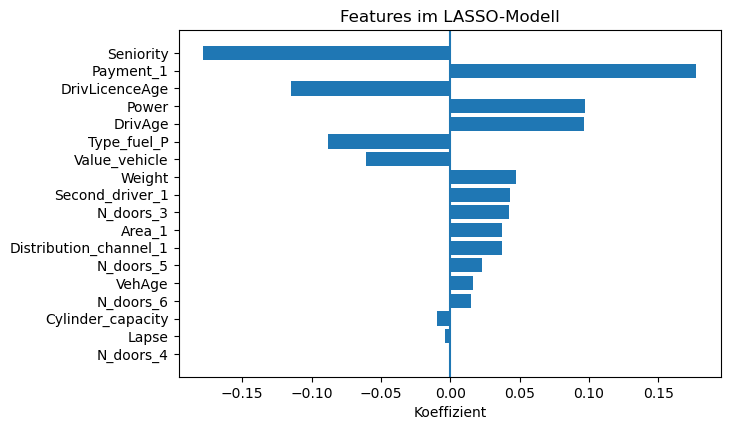

```python
display(coef_lasso)
#Auf 0 gesetzte Features
zero_coef_features = coef_lasso[
    (coef_lasso["feature"] != "const") & (np.abs(coef_lasso["coef"]) <= 1e-8)
]["feature"].tolist()
#Visualisierung
coef2 = coef_lasso[coef_lasso["feature"] != "const"].sort_values(
    by="abs_coef", ascending=False
)
plt.figure(figsize=(7, 4.5))
plt.barh(coef2["feature"], coef2["coef"])
plt.axvline(0)
plt.xlabel("Koeffizient")
plt.title("Features im LASSO-Modell")
plt.gca().invert_yaxis()
plt.show()
```

Features, die auf exakt Null regularisiert wurden:

```python
print(f"Anzahl Null-Koeffizienten: {len(zero_coef_features)}")
print("Auf Null regularisierte Features:")
print(zero_coef_features)
```

```
Anzahl Null-Koeffizienten: 1
Auf Null regularisierte Features:
['N_doors_4']
```

Die Analyse zeigt, dass **eine Dummy-Variable** im besten Modell durch die Regularisierung vollständig auf null gesetzt wurde:

- `N_doors_4`

Dabei handelt es sich nicht um das ursprüngliche Feature `N_doors`, sondern um eine einzelne Ausprägung dieses Features nach dem One-Hot-Encoding.

Da weitere Dummy-Variablen von `N_doors` im Modell Koeffizienten ungleich null besitzen, wurde das ursprüngliche Feature `N_doors` **nicht vollständig aus dem Modell entfernt**. Lediglich die Kategorie `4 Türen` liefert im Vergleich zur Referenzkategorie(2 Türen) und unter Kontrolle der übrigen Variablen keinen zusätzlichen Beitrag zur Vorhersage im finalen Modell.

```python
model_results_df = add_model_result(
    model_results_df=model_results_df,
    model_name="LASSO",
    metric_name="PDW",
    metric_train=pdw_train,
    metric_valid=pdw_valid,
    metric_test=np.nan,
    fit_time_sec=fit_time_sec,
    fit_and_predict_time_sec=fit_and_predict_time_sec,
    CF_train_act=cf_train_actual,
    CF_train_pred=cf_train_pred,
    CF_valid_act=cf_valid_actual,
    CF_valid_pred=cf_valid_pred,
    CF_test_act=np.nan,
    CF_test_pred=np.nan,
    notes=f"alpha={best_alpha}, l1_wt=1.0 (fixiert)"
)
```

```python
show_model_results(model_results_df, metric="PDW", sort_by="metric_valid", ascending=True)
```

|  | model_name | metric_name | metric_train | metric_valid | metric_test | fit_time_sec | fit_and_predict_time_sec | CF_train_act | CF_train_pred | CF_valid_act | CF_valid_pred | CF_test_act | CF_test_pred | notes |
| --- | --- | --- | --- | --- | --- | --- | --- | --- | --- | --- | --- | --- | --- | --- |
| 0 | GLM | PDW | 1.643600 | 1.532900 | NaN | 0.234300 | 0.418400 | 67.2597 % | 67.2597 % | 59.1986 % | 66.2701 % | NaN | NaN | Poisson-GLM mit vollständigem Featureset und O... |
| 1 | LASSO | PDW | 1.643700 | 1.541000 | NaN | 4.322000 | 4.323500 | 67.2597 % | 67.3108 % | 59.1986 % | 66.347 % | NaN | NaN | alpha=0.0005, l1_wt=1.0 (fixiert) |
| 2 | Intercept-Only Baseline(INT) | PDW | 1.716800 | 1.633900 | NaN | 0.004100 | 0.004100 | 67.2597 % | 67.2597 % | 59.1986 % | 67.2597 % | NaN | NaN | baseline_frequency=67.2597%, intercept=-0.3966 |
| 3 | Intercept-Only Baseline(mit GLM) | PDW | 1.716800 | 1.633900 | NaN | 0.042900 | 0.046700 | 67.2597 % | 67.2597 % | 59.1986 % | 67.2597 % | NaN | NaN | baseline_frequency=67.2597%, intercept=-0.3966 |

#### Interpretation der Sparsity im LASSO-Modell

Die Sparsity des Modells beschreibt, wie viele Koeffizienten durch die Regularisierung exakt auf null gesetzt wurden. Koeffizienten mit dem Wert null werden vom Modell effektiv nicht mehr genutzt und können daher als Hinweise auf irrelevante oder redundante Prädiktoren interpretiert werden.

Im besten Modell wurde **nur ein Koeffizient exakt auf null regularisiert**:

- `N_doors_4`

Dabei ist wichtig, dass `N_doors_4` keine eigenständige ursprüngliche Variable ist, sondern eine **Dummy-Variable**, die durch das One-Hot-Encoding des ursprünglichen Features `N_doors` entstanden ist. Da andere Dummy-Variablen von `N_doors` weiterhin Koeffizienten ungleich null besitzen, wurde das Feature `N_doors` insgesamt **nicht vollständig als irrelevant identifiziert**.

Die Regularisierung identifiziert lediglich die Ausprägung `4 Türen` als nicht zusätzlich erklärungsrelevant im finalen Modell. Das bedeutet, dass diese Kategorie im Vergleich zur Referenzkategorie (`2 Türen`) und unter Berücksichtigung der übrigen Variablen keinen eigenständigen Beitrag zur Vorhersage liefert.

Inhaltlich ist das plausibel, wenn die Information „4 Türen“ entweder bereits durch andere Fahrzeugdatenmerkmale mit abgebildet wird oder sich in ihrem Einfluss auf die Zielvariable kaum von der Referenzkategorie unterscheidet.

##### Zusammenfassung

Es wurde **kein ursprüngliches Feature vollständig als irrelevant entfernt**. Stattdessen wurde nur eine einzelne Dummy-Ausprägung (`N_doors_4`) auf null gesetzt. Die Sparsity des besten Modells ist daher sehr gering: Das Modell nutzt nahezu alle Features bzw. Dummy-Variablen weiterhin für die Vorhersage. Inhaltlich spricht dies dafür, dass die meisten Merkmale im Datensatz zumindest einen gewissen zusätzlichen Erklärungsbeitrag leisten.

f) Künstliches neuronales Netz optimieren

Entwickeln Sie ein künstliches neuronales Netz zur Modellierung der Schadenhäufigkeit. Wählen Sie das Deep-Learning-Framework (z. B. PyTorch, TensorFlow, Keras) sowie die Netzwerkarchitektur frei und begründen Sie Ihre Designentscheidungen. Bereiten Sie die Daten für das Training vor und begründen Sie, welche Features verwendet werden. Diskutieren Sie, wie kategoriale Features für neuronale Netzwerke aufbereitet werden können (z.B. One-Hot, Entity Embeddings). Standardisieren bzw. normalisieren Sie die numerischen Features geeignet und berücksichtigen Sie die Exposure-Variable im Modelldesign. Entwerfen Sie eine geeignete Architektur für Zähldaten und begründen Sie:

- Anzahl und Größe der Hidden Layers,
- Aktivierungsfunktionen,
- Regularisierungstechniken (z. B. Dropout, Batch Normalization),
- Output-Layer und Aktivierungsfunktion.

Wählen Sie eine geeignete Loss-Funktion zur Modellierung Poisson-verteilter Zähldaten und erläutern Sie, wie die Exposure-Variable integriert wird. Definieren Sie eine Trainingstrategie (Optimizer, Learning Rate, ggf. Scheduling, Batch Size, Epochenzahl), implementieren Sie Early Stopping anhand der Validierungsdaten und dokumentieren Sie den Trainingsverlauf (z. B. Loss-Kurven). Berechnen Sie die Poisson-Devianz auf Trainings- und Validierungsdatensatz, fügen Sie die Ergebnisse der Ergebnisdatenstruktur hinzu und vergleichen Sie diese mit bisherigen Modellen. Interpretieren Sie Anzeichen von Overfitting bzw. Underfitting. Anforderung: Das Modell soll mindestens so gut sein wie das Intercept-Only-Baseline-Modell; dokumentieren Sie die Trainingszeit.

## **Lösung:**

### Künstliches neuronales Netz: Combined Actuarial Neural Network (CANN)

Zur Modellierung der Schadenhäufigkeit wird ein künstliches neuronales Netz verwendet, das sich am Combined Actuarial Neural Network (CANN) orientiert. Dabei wird eine GLM-Basisprognose aus Teilaufgabe d) mit einem neuronalen Netz kombiniert.

Als Referenzmodell gilt das Modell aus dem Kapitel 9 in dem folgenden Projekt:

[Case Study 3: Nesting Classical Actuarial Models into Neural Networks](https://htmlpreview.github.io/?https://github.com/JSchelldorfer/ActuarialDataScience/blob/master/3%20-%20Nesting%20Classical%20Actuarial%20Models%20into%20Neural%20Networks/freMTPLfreq_cann.html)

Die erwartete Schadenanzahl wird modelliert als:

$$ \hat{\mu}_i = \exp\left(\log(\hat{\mu}_{GLM,i}) + f_\theta(x_i)\right) $$

Dabei ist:

- $ \hat{\mu}_{GLM,i} $: erwartete Schadenanzahl aus dem GLM
- $f_\theta(x_i) $: neuronale Korrektur auf der Log-Skala
- $ \hat{\mu}_i $: finale erwartete Schadenanzahl des CANN

Wenn $ f_\theta(x_i)=0 $, entspricht das CANN exakt dem GLM. Das neuronale Netz lernt somit nur zusätzliche Strukturen, die vom GLM nicht erklärt werden.

In dieser Umsetzung werden keine Embeddings verwendet.

#### Feature-Verarbeitung

1. **Numerische Variablen**
   1. **Wenn Ausreißer vorhanden sind**
      1. `QuantileTransformer`
      2. Danach `MinMaxScaler` auf `[-1, +1]`
   2. **Wenn keine Ausreißer vorhanden sind**
      1. Nur `MinMaxScaler` auf `[-1, +1]`
2. **Die kategoriale Variable `N_doors` wird als numerische Variable verarbeitet** Verarbeitung wie unter Punkt 1 beschrieben.
3. **Alle anderen kategorialen Variablen**
   1. Da diese Variablen binär sind, werden sie auf `{−1/2, +1/2}` kodiert.
   2. Die Zuordnung erfolgt automatisch wie folgt:
      1. `"D"` → `-0.5`
      2. `"P"` → `+0.5`

##### Warum `N_doors` als numerische Variable und kein Embedding?

Ein zentrales Argument ergibt sich aus der Struktur der Variable selbst:  
`N_doors` besitzt eine **natürliche Ordnung** (2 < 3 < 4 < 5).

Gemäß der [Case Study 3: Nesting Classical Actuarial Models into Neural Networks](https://htmlpreview.github.io/?https://github.com/JSchelldorfer/ActuarialDataScience/blob/master/3%20-%20Nesting%20Classical%20Actuarial%20Models%20into%20Neural%20Networks/freMTPLfreq_cann.html) werden geordnete kategoriale Variablen im CANN-Ansatz wie kontinuierliche Variablen behandelt:

> "Ordered categorical feature components are treated like continuous ones, where we simply replace the ordered categorical labels by integers."

Daher ist es methodisch sinnvoll, `N_doors` direkt als numerisches Merkmal zu verwenden, anstatt ein Embedding zu lernen.

```python
df_model_positive = df_freq_model[df_freq_model["N_claims_year"] > 0]
counts_df = (
    df_model_positive["N_doors"]
    .value_counts()
    .sort_index()
    .reset_index()
)

counts_df.columns = ["N_doors", "count"]

display(counts_df)
```

|  | N_doors | count |
| --- | --- | --- |
| 0 | 2 | 93 |
| 1 | 3 | 887 |
| 2 | 4 | 698 |
| 3 | 5 | 3440 |
| 4 | 6 | 1 |

Zusätzlich zeigt die Verteilung der Beobachtungen, dass die Kategorien stark ungleich besetzt sind:

- 2 Türen: 93 Beobachtungen
- 3 Türen: 887 Beobachtungen
- 4 Türen: 698 Beobachtungen
- 5 Türen: 3440 Beobachtungen
- 6 Türen: 1 Beobachtung

Zusammenfassend sprechen folgende Punkte gegen ein Embedding:

- geringe Anzahl an Kategorien
- natürliche Ordnung der Ausprägungen
- unausgeglichene Fallzahlen (insbesondere kleine Gruppen)

Die Modellierung von `N_doors` als numerische Variable ist daher sowohl aus methodischer als auch aus empirischer Sicht die geeignetere Wahl im CANN-Modell.

##### Warum alle andere kategoriele Merkmale entweder -0.5 oder +0,5?

Die restliche kategoriele Merkmale in dem Datensatz sind:`Distribution_channel`,`Payment`,`Area`,`Second_driver` und `Type_fuel` und sie sind alle binary/dichotom (nur 2 Klassen vorhanden). Gemäß der [Case Study 3: Nesting Classical Actuarial Models into Neural Networks](https://htmlpreview.github.io/?https://github.com/JSchelldorfer/ActuarialDataScience/blob/master/3%20-%20Nesting%20Classical%20Actuarial%20Models%20into%20Neural%20Networks/freMTPLfreq_cann.html)

und zwar unter 5.1.3 steht:

> "We observe that binary feature components (e.g. gender) are often embedded in the ML literature into a higher-dimensional space. However, we are of the opinion that this does not make sense. Hence, we suggest to set binary categorical feature components to ±1/2."

werden wir sie entsprechend für CANN vorbereiten.

#### Code Vorbereitung & Features vorbereiten

```python
# ===============================
# Variablen definieren
# ===============================

nn_features = (
    [col for col in var_num if col not in ["N_claims_year", "Exposure"]] +
    [col for col in var_cat_oh if not col.startswith("N_doors_")]
)
 #N_doors wird als numerisch-ordinales Merkmal verarbeitet
ordinal_num_col = "N_doors"

# binäre kategoriale Variablen ohne N_doors
cat_binary_cols = [
    col for col in var_cat
    if col != ordinal_num_col
]

# numerische Variablen ohne Zielvariable und ohne Exposure
num_cols = [
    col for col in var_num
    if col not in [target, "Exposure"]
]
# N_doors ergänzen, falls nicht bereits enthalten
num_cols.append(ordinal_num_col)

print("Alle numerische Merkmale inklusiv N_doors die standardisiert werden:")
print(num_cols)
print("Alle kategoriele Merkmale, die Werte -0.5/+0.5 haben werden:")
print(cat_binary_cols)
```

```
Alle numerische Merkmale inklusiv N_doors die standardisiert werden:
['Seniority', 'Lapse', 'Power', 'Cylinder_capacity', 'Value_vehicle', 'Weight', 'DrivAge', 'DrivLicenceAge', 'VehAge', 'N_doors']
Alle kategoriele Merkmale, die Werte -0.5/+0.5 haben werden:
['Distribution_channel', 'Payment', 'Area', 'Second_driver', 'Type_fuel']
```

```python
# ===============================
# Kopien erstellen
# ===============================

X_train_cann = X_train.copy()
X_valid_cann = X_valid.copy()
X_test_cann = X_test.copy()
y_train_cann = y_train.values.astype("float32")
y_valid_cann = y_valid.values.astype("float32")
y_test_cann = y_test.values.astype("float32")
# ===============================
# N_doors numerisch machen
# ===============================

X_train_cann[ordinal_num_col] = pd.to_numeric(X_train_cann[ordinal_num_col], errors="coerce")
X_valid_cann[ordinal_num_col] = pd.to_numeric(X_valid_cann[ordinal_num_col], errors="coerce")
X_test_cann[ordinal_num_col] = pd.to_numeric(X_test_cann[ordinal_num_col], errors="coerce")
```

#### Kategoriele Variable: Werte -0.5 oder +0.5

```python
# ===============================
# Binäre kategoriale Variablen {-0.5, +0.5}
# Mapping wird aus Trainingsdaten gelernt
# Speziell: "D" -> -0.5, "P" -> +0.5
# ===============================

binary_mappings = {}

for col in cat_binary_cols:
    values = sorted(X_train_cann[col].dropna().unique())
     #Type_fuel
    if set(values) == {"D", "P"}:
        mapping = {"D": -0.5, "P": 0.5}
    elif len(values) == 2:
        mapping = {values[0]: -0.5, values[1]: 0.5}
    else:
        raise ValueError(f"{col} hat nicht genau zwei Kategorien: {values}")

    binary_mappings[col] = mapping

    X_train_cann[col] = X_train_cann[col].map(mapping)
    X_valid_cann[col] = X_valid_cann[col].map(mapping)
    X_test_cann[col] = X_test_cann[col].map(mapping)
```

#### Numerische Merkmale und `N_doors`: Auf Skala [-1,+1]

```python
# ===============================
# Ausreißerprüfung - Definition wie in Teil A
# ===============================
def has_outliers_quantile(series, lower_q=0.025, upper_q=0.975):
    """
    Bestimmt Ausreißer basierend auf Quantilen:
    Outliers = x < Q(2.5%) oder x > Q(97.5%)

    Gibt zurück:
    - has_outliers (bool)
    - Anzahl Ausreißer
    - lower_bound
    - upper_bound
    """

    series_clean = series.dropna()

    lower_bound = series_clean.quantile(lower_q)
    upper_bound = series_clean.quantile(upper_q)

    mask = (series < lower_bound) | (series > upper_bound)

    return mask.any(), mask.sum(), lower_bound, upper_bound
# ===============================
# Custom MinMax [-1, +1] - Wie in der
#https://htmlpreview.github.io/?https://github.com/JSchelldorfer/ActuarialDataScience/blob/master/3%20-%20Nesting%20Classical%20Actuarial%20Models%20into%20Neural%20Networks/freMTPLfreq_cann.html
# ===============================

class MinMaxMinusOnePlusOne:
    def fit(self, X):
        self.min_ = np.nanmin(X, axis=0)
        self.max_ = np.nanmax(X, axis=0)
        return self

    def transform(self, X):
        return 2 * (X - self.min_) / (self.max_ - self.min_) - 1


# ===============================
# Transformation Pipeline für numerische Variablen
# ===============================

transformers = {}
outlier_report = []

for col in num_cols:

    has_outlier, n_outliers, lower, upper = has_outliers_quantile(X_train_cann[col])

    X_train_col = X_train_cann[[col]].values
    X_valid_col = X_valid_cann[[col]].values
    X_test_col = X_test_cann[[col]].values
    # ---------- Schritt 1: Quantile (nur wenn Ausreißer)
    if has_outlier:
        qt = QuantileTransformer(
            output_distribution="normal",
            n_quantiles=min(1000, len(X_train_col)),
            random_state=RANDOM_SEED
        )
        X_train_col = qt.fit_transform(X_train_col)
        X_valid_col = qt.transform(X_valid_col)
        X_test_col = qt.transform(X_test_col)
    else:
        qt = None

    # ---------- Schritt 2: MinMax [-1, +1]
    mm = MinMaxMinusOnePlusOne()
    X_train_col = mm.fit(X_train_col).transform(X_train_col)
    X_valid_col = mm.transform(X_valid_col) #nur transformieren!
    X_test_col = mm.transform(X_test_col) #nur transformieren!

    # zurück in DataFrame
    X_train_cann[col] = X_train_col.flatten()
    X_valid_cann[col] = X_valid_col.flatten()
    X_test_col = mm.transform(X_test_col)

    transformers[col] = {
        "quantile": qt,
        "minmax": mm
    }

    outlier_report.append({
        "feature": col,
        "has_outliers": has_outlier,
        "n_outliers": n_outliers,
        "transformation": "Quantile + MinMax[-1,1]" if has_outlier else "MinMax[-1,1]"
    })


# ===============================
# Outlier
# ===============================
outlier_report_df = pd.DataFrame(outlier_report)

display(outlier_report_df)
```

|  | feature | has_outliers | n_outliers | transformation |
| --- | --- | --- | --- | --- |
| 0 | Seniority | True | 341 | Quantile + MinMax[-1,1] |
| 1 | Lapse | True | 1 | Quantile + MinMax[-1,1] |
| 2 | Power | True | 443 | Quantile + MinMax[-1,1] |
| 3 | Cylinder_capacity | True | 408 | Quantile + MinMax[-1,1] |
| 4 | Value_vehicle | True | 475 | Quantile + MinMax[-1,1] |
| 5 | Weight | True | 469 | Quantile + MinMax[-1,1] |
| 6 | DrivAge | True | 452 | Quantile + MinMax[-1,1] |
| 7 | DrivLicenceAge | True | 395 | Quantile + MinMax[-1,1] |
| 8 | VehAge | True | 333 | Quantile + MinMax[-1,1] |
| 9 | N_doors | True | 163 | Quantile + MinMax[-1,1] |

#### Finale Feature-Matrix

```python
# ===============================
# Finale Feature-Matrix
# ===============================

final_features = num_cols + cat_binary_cols

X_train_cann = X_train_cann[final_features].astype("float32")
X_valid_cann = X_valid_cann[final_features].astype("float32")
X_test_cann = X_test_cann[final_features].astype("float32")
```

```python
# ===============================
# Kontrolle
# ===============================

print("Numerische standardisierte Variablen:")
print(num_cols)

print("\nBinär kodierte kategoriale Variablen:")
print(cat_binary_cols)

print("\nVerwendete Mappings:")
print(binary_mappings)

print("\nShape X_train_final:", X_train_cann.shape)
print("Shape X_valid_final:", X_valid_cann.shape)
print("Shape X_valid_final:", X_test_cann.shape)
```

```
Numerische standardisierte Variablen:
['Seniority', 'Lapse', 'Power', 'Cylinder_capacity', 'Value_vehicle', 'Weight', 'DrivAge', 'DrivLicenceAge', 'VehAge', 'N_doors']

Binär kodierte kategoriale Variablen:
['Distribution_channel', 'Payment', 'Area', 'Second_driver', 'Type_fuel']

Verwendete Mappings:
{'Distribution_channel': {0: -0.5, 1: 0.5}, 'Payment': {0: -0.5, 1: 0.5}, 'Area': {0: -0.5, 1: 0.5}, 'Second_driver': {0: -0.5, 1: 0.5}, 'Type_fuel': {'D': -0.5, 'P': 0.5}}

Shape X_train_final: (9524, 15)
Shape X_valid_final: (3175, 15)
Shape X_valid_final: (3175, 15)
```

```python
print("Trainingsdatensatz für CANN(X_train_cann):Erste 6 Zeilen:")
display(X_train_cann.head(6))
print("Trainingsdatensatz für CANN(X_train_cann):Statistik")
X_train_cann.describe()
```

```
Trainingsdatensatz für CANN(X_train_cann):Erste 6 Zeilen:
```

|  | Seniority | Lapse | Power | Cylinder_capacity | Value_vehicle | Weight | DrivAge | DrivLicenceAge | VehAge | N_doors | Distribution_channel | Payment | Area | Second_driver | Type_fuel |
| --- | --- | --- | --- | --- | --- | --- | --- | --- | --- | --- | --- | --- | --- | --- | --- |
| 15072 | -0.161390 | -1.000000 | 0.340025 | 0.179870 | 0.130181 | 0.045296 | -0.039856 | -0.190745 | 0.080203 | -0.238367 | -0.500000 | 0.500000 | -0.500000 | -0.500000 | 0.500000 |
| 3303 | 0.255998 | -1.000000 | 0.112225 | 0.329074 | 0.010767 | 0.057299 | 0.020549 | 0.046041 | 0.157646 | -0.122693 | -0.500000 | -0.500000 | -0.500000 | -0.500000 | -0.500000 |
| 5502 | -0.161390 | -1.000000 | 0.141642 | 0.329074 | 0.153629 | 0.202127 | 0.294963 | 0.084700 | 0.039856 | 0.080466 | 0.500000 | -0.500000 | -0.500000 | -0.500000 | -0.500000 |
| 9672 | 0.072371 | -1.000000 | 0.061602 | 0.109377 | 0.130181 | 0.049275 | -0.188392 | -0.122693 | -0.000965 | -0.238367 | -0.500000 | 0.500000 | -0.500000 | -0.500000 | -0.500000 |
| 1048 | -0.161390 | -1.000000 | 0.112225 | -0.052524 | 0.087294 | 0.010139 | 0.341182 | 0.463242 | -0.042819 | -0.238367 | -0.500000 | -0.500000 | -0.500000 | -0.500000 | -0.500000 |
| 136 | 0.141958 | -1.000000 | -0.044304 | 0.010864 | -0.083903 | -0.137871 | 0.198392 | 0.165895 | 0.327008 | 0.080466 | -0.500000 | -0.500000 | -0.500000 | -0.500000 | 0.500000 |

```
Trainingsdatensatz für CANN(X_train_cann):Statistik
```

|  | Seniority | Lapse | Power | Cylinder_capacity | Value_vehicle | Weight | DrivAge | DrivLicenceAge | VehAge | N_doors | Distribution_channel | Payment | Area | Second_driver | Type_fuel |
| --- | --- | --- | --- | --- | --- | --- | --- | --- | --- | --- | --- | --- | --- | --- | --- |
| count | 9524.000000 | 9524.000000 | 9524.000000 | 9524.000000 | 9524.000000 | 9524.000000 | 9524.000000 | 9524.000000 | 9524.000000 | 9524.000000 | 9524.000000 | 9524.000000 | 9524.000000 | 9524.000000 | 9524.000000 |
| mean | -0.004908 | -0.934784 | 0.000165 | -0.000041 | -0.000139 | -0.000037 | -0.000443 | -0.002298 | -0.006439 | -0.021359 | -0.046724 | -0.152877 | -0.199706 | -0.383137 | -0.111508 |
| std | 0.212883 | 0.293282 | 0.191718 | 0.192283 | 0.193395 | 0.192625 | 0.193750 | 0.202255 | 0.215130 | 0.182350 | 0.497842 | 0.476084 | 0.458421 | 0.321287 | 0.487417 |
| min | -1.000000 | -1.000000 | -1.000000 | -1.000000 | -1.000000 | -1.000000 | -1.000000 | -1.000000 | -1.000000 | -1.000000 | -0.500000 | -0.500000 | -0.500000 | -0.500000 | -0.500000 |
| 25% | -0.161390 | -1.000000 | -0.142911 | -0.125964 | -0.129662 | -0.129777 | -0.133538 | -0.122693 | -0.121513 | -0.122693 | -0.500000 | -0.500000 | -0.500000 | -0.500000 | -0.500000 |
| 50% | 0.001930 | -1.000000 | -0.002413 | 0.010864 | -0.000132 | 0.001206 | -0.002896 | -0.000965 | -0.000965 | 0.080466 | -0.500000 | -0.500000 | -0.500000 | -0.500000 | -0.500000 |
| 75% | 0.141958 | -1.000000 | 0.112225 | 0.109377 | 0.129928 | 0.128668 | 0.131397 | 0.132007 | 0.117998 | 0.080466 | 0.500000 | 0.500000 | 0.500000 | -0.500000 | 0.500000 |
| max | 1.000000 | 1.000000 | 1.000000 | 1.000000 | 1.000000 | 1.000000 | 1.000000 | 1.000000 | 1.000000 | 1.000000 | 0.500000 | 0.500000 | 0.500000 | 0.500000 | 0.500000 |

```python
print("Validierungsdatensatz für CANN(X_valid_cann):Erste 6 Zeilen:")
display(X_valid_cann.head(6))
print("Validierungsdatensatz für CANN(X_valid_cann):Statistik")
X_valid_cann.describe()
```

```
Validierungsdatensatz für CANN(X_valid_cann):Erste 6 Zeilen:
```

|  | Seniority | Lapse | Power | Cylinder_capacity | Value_vehicle | Weight | DrivAge | DrivLicenceAge | VehAge | N_doors | Distribution_channel | Payment | Area | Second_driver | Type_fuel |
| --- | --- | --- | --- | --- | --- | --- | --- | --- | --- | --- | --- | --- | --- | --- | --- |
| 15762 | -0.057299 | -1.000000 | 0.306427 | 0.206797 | 0.348281 | 0.190745 | 0.067473 | -0.026384 | -0.298131 | -0.122693 | -0.500000 | -0.500000 | 0.500000 | 0.500000 | -0.500000 |
| 2651 | 0.163112 | -1.000000 | 0.080203 | 0.027358 | -0.094620 | 0.068244 | -0.254253 | -0.164847 | -0.084700 | -0.238367 | -0.500000 | 0.500000 | -0.500000 | -0.500000 | 0.500000 |
| 2128 | -0.161390 | -1.000000 | -0.044304 | 0.047283 | 0.046917 | 0.193927 | 0.234261 | 0.292638 | 0.247474 | 0.080466 | 0.500000 | -0.500000 | -0.500000 | -0.500000 | -0.500000 |
| 10751 | 0.041830 | -1.000000 | 0.222070 | 0.206797 | 0.243396 | 0.245282 | -0.014733 | -0.164847 | -0.121513 | 0.080466 | 0.500000 | -0.500000 | -0.500000 | -0.500000 | -0.500000 |
| 378 | 0.178876 | -1.000000 | 0.277448 | 0.398982 | 0.285183 | 0.417302 | 0.145789 | 0.214714 | 0.080203 | 0.080466 | -0.500000 | -0.500000 | -0.500000 | -0.500000 | -0.500000 |
| 2616 | 0.255998 | -1.000000 | 0.277448 | 0.344731 | 0.165610 | 0.143866 | -0.133538 | -0.071336 | -0.084700 | 0.080466 | 0.500000 | -0.500000 | -0.500000 | -0.500000 | -0.500000 |

```
Validierungsdatensatz für CANN(X_valid_cann):Statistik
```

|  | Seniority | Lapse | Power | Cylinder_capacity | Value_vehicle | Weight | DrivAge | DrivLicenceAge | VehAge | N_doors | Distribution_channel | Payment | Area | Second_driver | Type_fuel |
| --- | --- | --- | --- | --- | --- | --- | --- | --- | --- | --- | --- | --- | --- | --- | --- |
| count | 3175.000000 | 3175.000000 | 3175.000000 | 3175.000000 | 3175.000000 | 3175.000000 | 3175.000000 | 3175.000000 | 3175.000000 | 3175.000000 | 3175.000000 | 3175.000000 | 3175.000000 | 3175.000000 | 3175.000000 |
| mean | -0.002103 | -0.926876 | -0.002111 | -0.004342 | -0.004052 | -0.002183 | -0.000738 | 0.001805 | -0.004128 | -0.021755 | -0.060315 | -0.163622 | -0.203937 | -0.376220 | -0.094016 |
| std | 0.217959 | 0.309407 | 0.193238 | 0.194074 | 0.193718 | 0.193272 | 0.193495 | 0.202178 | 0.214928 | 0.187962 | 0.496427 | 0.472546 | 0.456587 | 0.329380 | 0.491151 |
| min | -1.000000 | -1.000000 | -1.000000 | -1.000000 | -0.664654 | -0.729410 | -1.000000 | -1.000000 | -1.000000 | -1.000000 | -0.500000 | -0.500000 | -0.500000 | -0.500000 | -0.500000 |
| 25% | -0.161390 | -1.000000 | -0.142911 | -0.139436 | -0.135078 | -0.135696 | -0.133538 | -0.122693 | -0.121513 | -0.122693 | -0.500000 | -0.500000 | -0.500000 | -0.500000 | -0.500000 |
| 50% | 0.001930 | -1.000000 | -0.006033 | -0.006516 | -0.003781 | -0.002896 | -0.002896 | -0.000965 | -0.000965 | 0.080466 | -0.500000 | -0.500000 | -0.500000 | -0.500000 | -0.500000 |
| 75% | 0.141958 | -1.000000 | 0.112225 | 0.109377 | 0.128801 | 0.132313 | 0.131397 | 0.132007 | 0.117998 | 0.080466 | 0.500000 | 0.500000 | 0.500000 | -0.500000 | 0.500000 |
| max | 1.000000 | 0.381948 | 1.000000 | 0.647086 | 1.000000 | 0.598911 | 1.000000 | 1.000000 | 0.604626 | 0.080466 | 0.500000 | 0.500000 | 0.500000 | 0.500000 | 0.500000 |

Die Transformation der numerischen Variablen ist erfolgreich durchgeführt worden. Die Skalierung auf das Intervall [-1,1] basiert auf den Minimal- und Maximalwerten des Trainingsdatensatzes.

Da die Transformation ausschließlich auf den Trainingsdaten geschätzt und anschließend auf den Validierungsdatensatz angewendet wird, ist es zu erwarten, dass die transformierten Werte im Validierungsdatensatz nicht exakt das Intervall [-1,1] ausschöpfen.

Dies liegt daran, dass:

- die Verteilung der Validierungsdaten von den Trainingsdaten abweichen kann
- nicht alle Werte nahe den Extrempunkten liegen
- und bei Verwendung einer Quantiltransformation die Werte zusätzlich in Richtung einer gleichmäßigeren Verteilung konzentriert werden

Die beobachteten Werte sind konsistent mit einer korrekt implementierten Transformation und deuten auf eine stabile Skalierung hin.

##### Daten in Matrixform bringen

```python
# Feature-Matrizen
X_train_cann_mat = np.asarray(X_train_cann).astype("float32")
X_valid_cann_mat = np.asarray(X_valid_cann).astype("float32")
X_test_cann_mat = np.asarray(X_test_cann).astype("float32")

# Zielvariable: N_claims_year, nicht transformiert
y_train_cann = np.asarray(y_train).astype("float32")
y_valid_cann = np.asarray(y_valid).astype("float32")
y_test_cann = np.asarray(y_test).astype("float32")

print("X_train:", X_train_cann_mat.shape)
print("X_valid:", X_valid_cann_mat.shape)
print("X_test:", X_test_cann_mat.shape)
print("y_train:", y_train_cann.shape)
print("y_valid:", y_valid_cann.shape)
print("y_test:", y_valid_cann.shape)
```

```
X_train: (9524, 15)
X_valid: (3175, 15)
X_test: (3175, 15)
y_train: (9524,)
y_valid: (3175,)
y_test: (3175,)
```

##### GLM-Skip-Connection vorbereiten

Hier benutzen wir als das GLM Basisprognose das Ergebnis aus dem GLM Modell aus der Teilaufgabe d).

```python
pred_train_glm = np.asarray(glm_full.predict(X_train, offset=np.log(X_train["Exposure"]))).astype("float32")
pred_valid_glm = np.asarray(glm_full.predict(X_valid, offset=np.log(X_valid["Exposure"]))).astype("float32")

# numerische Stabilität -nicht negativ
pred_train_glm = np.clip(pred_train_glm, 1e-12, None)
pred_valid_glm = np.clip(pred_valid_glm, 1e-12, None)

# CANN verwendet log(GLM-Vorhersage) als Skip-Connection
log_pred_train_glm = np.log(pred_train_glm).reshape(-1, 1).astype("float32")
log_pred_valid_glm = np.log(pred_valid_glm).reshape(-1, 1).astype("float32")

# Initialisierung analog zur Referenz:
# lambda_hom = sum(y) / sum(GLM prediction)
lambda_hom = np.sum(y_train_cann) / np.sum(pred_train_glm)

print(f"lambda_hom: {lambda_hom:.6f}")
print(f"log(lambda_hom): {np.log(lambda_hom):.6f}")
```

```
lambda_hom: 1.000000
log(lambda_hom): 0.000000
```

#### Architektur

Bei der Architektur, der Loss-Funktion und der Trainingsstrategie orientieren wir uns an der Referenz als **Best Practice**:

[Case Study 3: Nesting Classical Actuarial Models into Neural Networks](https://htmlpreview.github.io/?https://github.com/JSchelldorfer/ActuarialDataScience/blob/master/3%20-%20Nesting%20Classical%20Actuarial%20Models%20into%20Neural%20Networks/freMTPLfreq_cann.html)

##### Hidden Layers

Das Netzwerk besteht aus drei Hidden Layers mit 20, 15 und 10 Neuronen. Diese Architektur ist bewusst einfach gewählt, da es sich um tabellarische Versicherungsdaten handelt und ein zu großes Netz schnell zu Overfitting führen kann. Die schrittweise abnehmende Layer-Größe erlaubt es dem Modell, zunächst allgemeinere Muster zu erfassen und diese anschließend zu verdichten.

##### Aktivierungsfunktionen

In den Hidden Layers wird die `tanh`-Aktivierung verwendet. Diese Aktivierung ist um Null zentriert und passt gut zu den vorbereiteten, skalierten Eingangsdaten. Dadurch können sowohl positive als auch negative Korrekturen zur Basisprognose gelernt werden.

##### Regularisierung

Das Modell wird primär durch seine einfache Architektur sowie durch Early Stopping regularisiert. Auf zusätzliche Dropout- oder Batch-Normalization-Schichten wird in dieser Variante verzichtet, da das CANN bereits durch die Skip-Connection zur Basisprognose stabilisiert wird. Die Validierungsdaten werden verwendet, um das Training rechtzeitig zu stoppen, sobald sich die Validierungs-Loss nicht weiter verbessert.

##### Output-Layer

Der Output des neuronalen Netzes ist zunächst eine lineare Korrektur auf der Log-Skala. Diese wird mit der logarithmierten Basisprognose addiert. Anschließend wird eine Exponentialfunktion angewendet, sodass die vorhergesagte Schadenanzahl strikt positiv ist. Dies ist für Poisson-verteilte Zähldaten erforderlich.

##### Loss-Funktion und Integration der Exposure

Da die Zielvariable `N_claims_year` eine Zählvariable ist, wird die Poisson-Loss-Funktion verwendet. Diese ist für nichtnegative Zähldaten geeignet und entspricht der Annahme einer Poisson-verteilten Schadenanzahl.

Die Exposure-Variable wird nicht als normales Feature in das neuronale Netz gegeben, sondern ist bereits in der Basisprognose enthalten. Die Basisprognose beschreibt die erwartete Schadenanzahl und berücksichtigt damit die unterschiedliche Beobachtungsdauer der Verträge. Durch die Skip-Connection wird diese Exposure-adjustierte Prognose direkt in das CANN übernommen.

##### Trainingsstrategie

Als Optimizer wird Nadam verwendet, eine Erweiterung von Adam mit Nesterov-Momentum. Dieser Optimizer ist für neuronale Netze gut geeignet, da er adaptive Lernraten nutzt und häufig stabil konvergiert.

Early Stopping wird anhand der Validierungs-Loss eingesetzt. Wenn sich die Validierungs-Loss über mehrere Epochen nicht verbessert, wird das Training beendet und die besten Gewichte werden wiederhergestellt. Dadurch wird Overfitting reduziert.

Der Trainingsverlauf wird über Loss-Kurven für Trainings- und Validierungsdaten dokumentiert.

```python
def build_cann(q0, lambda_hom, learning_rate=0.001):
    """
    CANN ohne Embeddings.

    Inputs:
    - Design: vorbereitete Feature-Matrix
    - LogLASSO: log(LASSO-Vorhersage)

    Output:
    - erwartete Schadenanzahl mu = exp(LogLASSO + Network)
    """

    q1 = 20
    q2 = 15
    q3 = 10


    design_input = keras.Input(shape=(q0,), dtype="float32", name="Design")
    log_glm_input = keras.Input(shape=(1,), dtype="float32", name="LogGLM")

    hidden = layers.Dense(q1, activation="tanh", name="hidden1")(design_input)
    hidden = layers.Dense(q2, activation="tanh", name="hidden2")(hidden)
    hidden = layers.Dense(q3, activation="tanh", name="hidden3")(hidden)


    # Netzwerk-Korrektur auf Log-Skala
    # Kernel wird mit 0 initialisiert, Bias mit log(lambda_hom),
    # analog zur R-Initialisierung im Tutorial.
    network_output = layers.Dense(
        1,
        activation="linear",
        name="Network",
        kernel_initializer="zeros",
        bias_initializer=keras.initializers.Constant(np.log(lambda_hom))
    )(hidden)

    # Skip-Connection: LogGLM+ Network
    additive_predictor = layers.Add(name="Add")([network_output, log_glm_input])

    # Poisson-Mittelwert muss positiv sein
    response = layers.Activation("exponential", name="Response")(additive_predictor)

    model = keras.Model(
        inputs=[design_input, log_glm_input],
        outputs=response,
        name="CANN_no_embedding"
    )

    model.compile(
        loss=keras.losses.Poisson(),
        optimizer=keras.optimizers.Nadam(learning_rate=learning_rate)
    )

    return model
```

#### Modell erstellen

```python
q0 = X_train_cann_mat.shape[1]

model_cann = build_cann(
    q0=q0,
    lambda_hom=lambda_hom,
    learning_rate=0.0005
)

model_cann.summary()
```

```
WARNING:tensorflow:From C:\Users\nvanw\anaconda3\Lib\site-packages\keras\src\backend.py:1398: The name tf.executing_eagerly_outside_functions is deprecated. Please use tf.compat.v1.executing_eagerly_outside_functions instead.

Model: "CANN_no_embedding"
__________________________________________________________________________________________________
 Layer (type)                Output Shape                 Param #   Connected to
==================================================================================================
 Design (InputLayer)         [(None, 15)]                 0         []

 hidden1 (Dense)             (None, 20)                   320       ['Design[0][0]']

 hidden2 (Dense)             (None, 15)                   315       ['hidden1[0][0]']

 hidden3 (Dense)             (None, 10)                   160       ['hidden2[0][0]']

 Network (Dense)             (None, 1)                    11        ['hidden3[0][0]']

 LogGLM (InputLayer)         [(None, 1)]                  0         []

 Add (Add)                   (None, 1)                    0         ['Network[0][0]',
                                                                     'LogGLM[0][0]']

 Response (Activation)       (None, 1)                    0         ['Add[0][0]']

==================================================================================================
Total params: 806 (3.15 KB)
Trainable params: 806 (3.15 KB)
Non-trainable params: 0 (0.00 Byte)
__________________________________________________________________________________________________
```

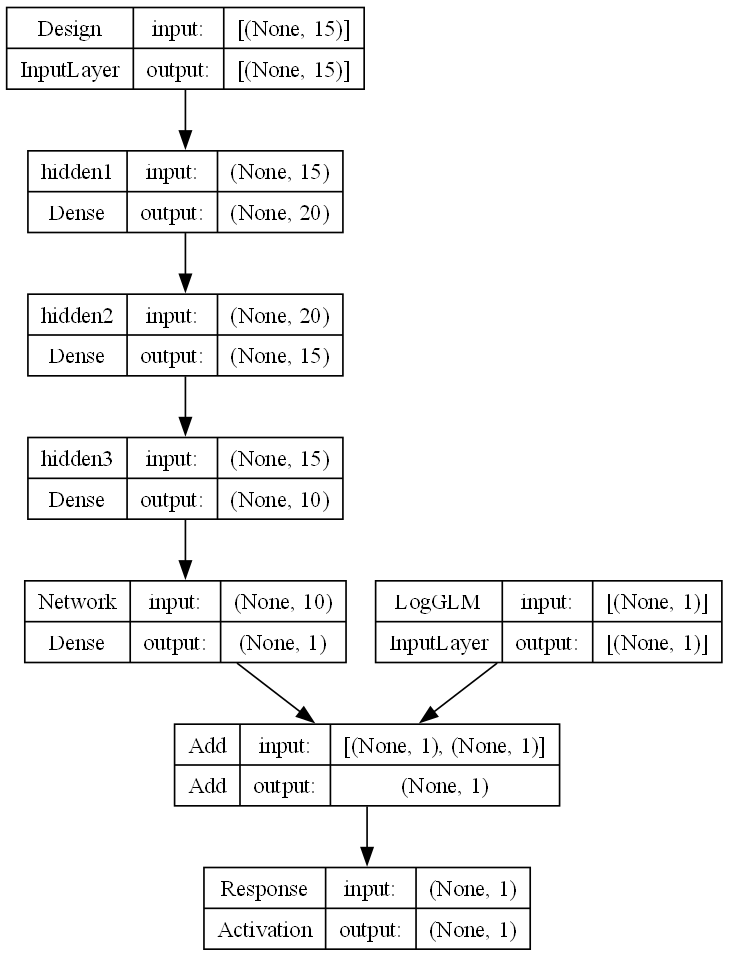

```python
#Visualisierung
#https://graphviz.org/download/
plot_model(
    model_cann,
    to_file="cann_model_architecture.png",
    show_shapes=True,
    show_layer_names=True,
    expand_nested=True,
    dpi=120
)
display(Image("cann_model_architecture.png"))
```

#### Training mit Early Stopping

```python
epochs = 500
batch_size = 512

early_stopping = keras.callbacks.EarlyStopping(
    monitor="val_loss",
    patience=20,
    restore_best_weights=True
)

reduce_lr = keras.callbacks.ReduceLROnPlateau(
    monitor="val_loss",
    factor=0.5,
    patience=10,
    min_lr=1e-5
)

start_time = time.time()

history_cann = model_cann.fit(
    x=[X_train_cann_mat, log_pred_train_glm],
    y=y_train_cann,
    validation_data=([X_valid_cann_mat, log_pred_valid_glm], y_valid_cann),
    epochs=epochs,
    batch_size=batch_size,
    callbacks=[early_stopping, reduce_lr],
    verbose=1
)

fit_time_sec = time.time() - start_time

print(f"Trainingszeit CANN: {fit_time_sec:.4f} Sekunden")
```

```
WARNING:tensorflow:From C:\Users\nvanw\anaconda3\Lib\site-packages\keras\src\utils\tf_utils.py:492: The name tf.ragged.RaggedTensorValue is deprecated. Please use tf.compat.v1.ragged.RaggedTensorValue instead.

Trainingszeit CANN: 8.0539 Sekunden
```

##### Trainingsverlauf darstellen

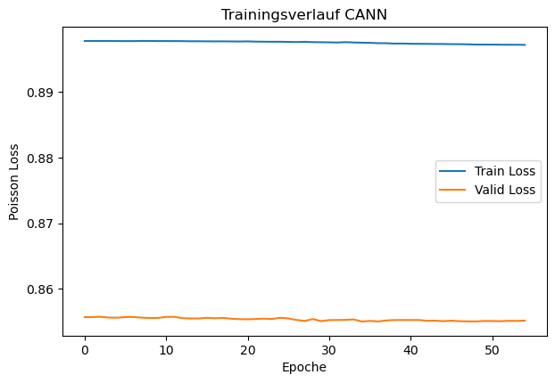

```python
history_df = pd.DataFrame(history_cann.history)

plt.figure(figsize=(7, 4.5))
plt.plot(history_df["loss"], label="Train Loss")
plt.plot(history_df["val_loss"], label="Valid Loss")
plt.xlabel("Epoche")
plt.ylabel("Poisson Loss")
plt.title("Trainingsverlauf CANN")
plt.legend()
plt.show()
```

#### Vorhersagen

```python
start_pred_time = time.time()

pred_train_cann = model_cann.predict([X_train_cann_mat, log_pred_train_glm]).reshape(-1)
pred_valid_cann = model_cann.predict([X_valid_cann_mat, log_pred_valid_glm]).reshape(-1)

fit_and_predict_time_sec = fit_time_sec + (time.time() - start_pred_time)

pred_train_cann = np.clip(pred_train_cann, 1e-12, None)
pred_valid_cann = np.clip(pred_valid_cann, 1e-12, None)
#PDW berechnen
exposure_train = np.asarray(X_train["Exposure"]).astype("float32")
exposure_valid = np.asarray(X_valid["Exposure"]).astype("float32")
pdw_train = PDW(pred_train_cann, y_train_cann,exposure_train)
pdw_valid = PDW(pred_valid_cann, y_valid_cann,exposure_valid)

cf_train_actual = CF_calculate(y_train_cann, X_train["Exposure"])
cf_train_pred   = CF_calculate(pred_train_cann, X_train["Exposure"])
cf_valid_actual = CF_calculate(y_valid_cann, X_valid["Exposure"])
cf_valid_pred   = CF_calculate(pred_valid_cann, X_valid["Exposure"])
```

#### Poisson Deviance auf Trainings- und Validierungsdaten

```python
 print("Poisson Deviance Train/Valid: %.4f / %.4f" %
    (pdw_train,pdw_valid))
```

```
Poisson Deviance Train/Valid: 1.6429 / 1.5403
```

#### Ergebnisdatenstruktur aktualisieren

```python
model_results_df = add_model_result(
    model_results_df=model_results_df,
    model_name="CANN",
    metric_name="PDW",
    metric_train=pdw_train,
    metric_valid=pdw_valid,
    metric_test=np.nan,
    fit_time_sec=fit_time_sec,
    fit_and_predict_time_sec=fit_and_predict_time_sec,
    CF_train_act=cf_train_actual,
    CF_train_pred=cf_train_pred,
    CF_valid_act=cf_valid_actual,
    CF_valid_pred=cf_valid_pred,
    CF_test_act=np.nan,
    CF_test_pred=np.nan,
    notes="CANN ohne Embeddings; GLM-Skip-Connection über log(GLM  Vorhersage)"
)
```

```python
show_model_results(
    model_results_df,
    metric="PDW",
    sort_by="metric_valid",
    ascending=True,
    digits=4
)
```

|  | model_name | metric_name | metric_train | metric_valid | metric_test | fit_time_sec | fit_and_predict_time_sec | CF_train_act | CF_train_pred | CF_valid_act | CF_valid_pred | CF_test_act | CF_test_pred | notes |
| --- | --- | --- | --- | --- | --- | --- | --- | --- | --- | --- | --- | --- | --- | --- |
| 0 | GLM | PDW | 1.643600 | 1.532900 | NaN | 0.234300 | 0.418400 | 67.2597 % | 67.2597 % | 59.1986 % | 66.2701 % | NaN | NaN | Poisson-GLM mit vollständigem Featureset und O... |
| 1 | CANN | PDW | 1.642900 | 1.540300 | NaN | 8.053900 | 8.939600 | 67.2597 % | 67.0552 % | 59.1986 % | 66.0535 % | NaN | NaN | CANN ohne Embeddings; GLM-Skip-Connection über... |
| 2 | LASSO | PDW | 1.643700 | 1.541000 | NaN | 4.322000 | 4.323500 | 67.2597 % | 67.3108 % | 59.1986 % | 66.347 % | NaN | NaN | alpha=0.0005, l1_wt=1.0 (fixiert) |
| 3 | Intercept-Only Baseline(INT) | PDW | 1.716800 | 1.633900 | NaN | 0.004100 | 0.004100 | 67.2597 % | 67.2597 % | 59.1986 % | 67.2597 % | NaN | NaN | baseline_frequency=67.2597%, intercept=-0.3966 |
| 4 | Intercept-Only Baseline(mit GLM) | PDW | 1.716800 | 1.633900 | NaN | 0.042900 | 0.046700 | 67.2597 % | 67.2597 % | 59.1986 % | 67.2597 % | NaN | NaN | baseline_frequency=67.2597%, intercept=-0.3966 |

```python
#for layer in model_cann.layers: print(layer.get_config(), layer.get_weights())
```

#### Vergleich mit bisherigen Modellen

Die Ergebnisse wurden in die bestehende Ergebnisdatenstruktur geschrieben und mit den bisherigen Modellen, insbesondere dem Intercept-Only-Modell, dem vollständigen GLM und dem LASSO-Modell, verglichen.

Das CANN erfüllt die Mindestanforderung,da es mindestens so gut ist wie das Intercept-Only-Basismodell. Das CANN Modell erreicht auf den Trainingsdaten mit einer PDW von $1.6429$ den niedrigsten Wert unter den betrachteten Modellen. Auf dem Validierungsdatensatz ist das GLM mit einer PDW von $1.5329$ jedoch besser als das CANN-Modell mit $1.5403$. Dies deutet darauf hin, dass das CANN die Trainingsdaten etwas stärker anpasst, aber keine bessere Generalisierung als das GLM erreicht. Zusätzlich ist die Trainingszeit des CANN deutlich höher, sodass das GLM in diesem Vergleich aufgrund besserer Validierungsleistung, geringerer Laufzeit und höherer Interpretierbarkeit vorzuziehen ist.

##### Schadenfrequenz Prognose

Die Modelle prognostizieren auf der Validierungsmenge jedoch höhere Schadenfrequenzen. Damit überschätzen alle Modelle die Schadenfrequenz auf den Validierungsdaten. Das CANN liegt mit `66.0535%` etwas näher an der tatsächlichen Validierungs-Schadenfrequenz als GLM und LASSO, überschätzt sie aber weiterhin deutlich. Dies kann daran liegen, dass die Schadenfrwquenz auf dem Traininfsdatensatz deutlich höher als auf dem Validierungsdatensatz.

##### Overfitting bzw. Underfitting Anzeichen

Die Lernkurve zeigt **kein klassisches Overfitting** beim CANN-Modell. Bei Overfitting würde man typischerweise erwarten, dass der Trainings-Loss weiter sinkt, während der Validierungs-Loss nach einigen Epochen wieder steigt. Das ist hier nicht der Fall: Beide Kurven verlaufen sehr stabil, und der Validierungs-Loss steigt nicht an.

Auffällig ist allerdings, dass sich sowohl Trainings- als auch Validierungs-Loss über die Epochen kaum verbessern. Das deutet eher darauf hin, dass das CANN in dieser Konfiguration nur sehr wenig zusätzlich lernt beziehungsweise die vorhandene GLM-Skip-Connection dominiert. Daher spricht die Lernkurve eher für eine stabile, aber wenig verbessernde Anpassung als für Overfitting.

Dass der Validierungs-Loss niedriger als der Trainings-Loss ist, kann zum Beispiel durch unterschiedliche Datenstruktur, Regularisierungseffekte oder die Gewichtung der Beobachtungen entstehen und ist nicht automatisch problematisch. Zusammen mit den PDW-Ergebnissen lässt sich sagen: Die Lernkurve selbst liefert keinen klaren Hinweis auf Overfitting.

B2:Ensemble-Modelle für die Schadenhäufigkeit

*[Lernziele: 2.1, 2.2, 3.4 & 5.1 | Punkte: 29]*  
Ziel von Aufgabe B2 ist es, die Schadenanzahl bzw. Schadenfrequenz (Frequency) mit Ensemble-Modellen zu modellieren.

a) Ensemble-Methoden Bagging und Random Forest

Erläutern Sie kurz die Funktionsweise von Bagging und Random Forest, arbeiten Sie Gemeinsamkeiten und Unterschiede heraus und begründen Sie, warum Ensemble-Methoden bei hochdimensionalen Datensätzen vorteilhaft sein können. Trainieren Sie beide Modelle unter Berücksichtigung der Poisson-Natur der Zielgröße: – Bagging: Alle Features stehen bei jedem Split zur Verfügung. – Random Forest: Verwenden Sie bei jedem Split nur eine zufällige Teilmenge der Features (z.B. Quadratwurzel der Gesamtzahl). Wählen Sie ein geeignetes Split-Kriterium, integrieren Sie die Exposure-Variable angemessen und definieren Sie geeignete Hyperparameter (Anzahl Bäume, maximale Tiefe, minimale Beobachtungen pro Blatt). Begründen Sie Ihre Entscheidungen kurz. Berechnen Sie die Poisson-Devianz auf Trainings- und Validierungsdaten für beide Modelle, fügen Sie die Ergebnisse der Ergebnisdatenstruktur hinzu und dokumentieren Sie die Trainingszeit. Erstellen Sie Feature-Importance-Plots für beide Modelle nebeneinander und visualisieren Sie jeweils die Top-15 wichtigsten Features. Vergleichen und interpretieren Sie die Ergebnisse (Übereinstimmungen, Rangfolgen, mögliche Gründe). *Hinweis: Für die volle Punktzahl sollten beide Modelle mindestens so gut sein wie das GLM aus Teilaufgabe B1 d).*

## **Lösung:**

### Funktionsweise von Bagging und Random Forest

Bagging und Random Forest sind Ensemble-Methoden, die mehrere Entscheidungsbäume kombinieren.

Beim **Bagging** werden viele Bäume auf unterschiedlichen Bootstrap-Stichproben trainiert. Jeder Baum sieht dabei grundsätzlich alle Features. Die finale Vorhersage ergibt sich als Durchschnitt der Einzelbaum-Vorhersagen. Dadurch wird die Varianz reduziert.

Der **Random Forest** erweitert Bagging zusätzlich dadurch, dass bei jedem Split nur eine zufällige Teilmenge der Features betrachtet wird. Dadurch werden die Bäume stärker dekorreliert, was die Generalisierungsfähigkeit verbessern kann.

Gemeinsamkeiten:

- beide bestehen aus vielen Entscheidungsbäumen
- beide reduzieren Varianz durch Mittelung
- beide können nichtlineare Zusammenhänge und Interaktionen erfassen

Unterschiede:

- Bagging nutzt bei jedem Split alle Features
- Random Forest nutzt bei jedem Split nur eine zufällige Feature-Teilmenge
- Random Forest erzeugt dadurch stärker unterschiedliche Bäume

Für hochdimensionale Datensätze sind Ensemble-Methoden vorteilhaft, weil sie viele Features verarbeiten können, automatisch Interaktionen erfassen und relativ robust gegenüber einzelnen irrelevanten Merkmalen sind. Durch Feature Importance Ergebnis kann man mit den Modellen eine Dimensionreduktion durchführen.

Da die Zielvariable eine Schadenanzahl ist, wird als Split-Kriterium die Poisson-Devianz verwendet. Die Exposure wird berücksichtigt, indem die Modelle die Schadenfrequenz

$$ Frequency_i = \frac{N\_claims\_year_i}{Exposure_i} $$

modellieren.

Die Exposure wird zusätzlich als Sample Weight verwendet. Dadurch werden Beobachtungen mit längerer Beobachtungsdauer stärker bei der Split-Auswahl und der Schätzung der Blattwerte berücksichtigt. Die finale vorhergesagte Schadenanzahl ergibt sich durch:

$$ \hat{N}_i = \widehat{Frequency}_i \cdot Exposure_i $$

Die Baum-Ensemble-Modelle werden auf der Schadenfrequenz trainiert, da diese die risikoadjustierte Zielgröße darstellt.

Für die Evaluation und den Vergleich mit anderen Modellen wird jedoch die erwartete Schadenanzahl verwendet. Dieses Vorgehen stellt sicher, dass alle Modelle eine konsistente Zielgröße liefern und die Poisson-Devianz korrekt berechnet werden kann.

#### Daten für Ensemble-Modelle aufbereiten

```python
# Zielvariable und Exposure
target_alt = "N_claims_year"
exposure_col = "Exposure"

# Für Tree-Modelle: numerische Features + One-Hot-kodierte kategoriale Features
tree_features = (
    [col for col in var_num if col not in [target, exposure_col]] +
    var_cat_oh
)
print("Ensemble Modelle-Features:",tree_features)

X_train_tree = X_train[tree_features].copy()
X_valid_tree = X_valid[tree_features].copy()
X_test_tree  = X_test[tree_features].copy()

y_train_tree = y_train.copy()
y_valid_tree = y_valid.copy()
y_test_tree  = y_test.copy()

exposure_train = X_train[exposure_col].copy()
exposure_valid = X_valid[exposure_col].copy()
exposure_test  = X_test[exposure_col].copy()

# Zielgröße für das Training: Schadenfrequenz
freq_train = y_train_tree / exposure_train
freq_valid = y_valid_tree / exposure_valid
freq_test  = y_test_tree / exposure_test

print("X_train_tree:", X_train_tree.shape)
print("X_valid_tree:", X_valid_tree.shape)
print("X_test_tree:", X_test_tree.shape)
```

```
Ensemble Modelle-Features: ['Seniority', 'Lapse', 'Power', 'Cylinder_capacity', 'Value_vehicle', 'Weight', 'DrivAge', 'DrivLicenceAge', 'VehAge', 'Distribution_channel_1', 'Payment_1', 'Area_1', 'Second_driver_1', 'N_doors_3', 'N_doors_4', 'N_doors_5', 'N_doors_6', 'Type_fuel_P']
X_train_tree: (9524, 18)
X_valid_tree: (3175, 18)
X_test_tree: (3175, 18)
```

#### Bagging Modell

Durch die "Trial & Error" Methode habe ich mich für folgende Hyperparamer entschieden:

- Anzahl Bäume : 1000
- maximale Tiefe: 6
- minimale Beobachtungen pro Blatt: 100

```python
bagging_model = RandomForestRegressor(
    n_estimators=1000,          # 500 Bäume
    criterion="poisson",       #Possion
    max_features=1.0,          # Bagging: alle Features bei jedem Split
    max_depth=6,
    min_samples_leaf=100,
    bootstrap=True,
    random_state=RANDOM_SEED, #Reproduzierbarkeit sicherstellen
    n_jobs=1 #Reproduzierbarkeit sicherstellen
)

start_time = time.time()

bagging_model.fit(
    X_train_tree,
    freq_train,
    sample_weight=exposure_train
)

fit_time_bagging = time.time() - start_time
freq_pred_train_bagging = bagging_model.predict(X_train_tree)
freq_pred_valid_bagging = bagging_model.predict(X_valid_tree)
# Frequenz darf nicht negativ sein
freq_pred_train_bagging = np.clip(freq_pred_train_bagging, 1e-12, None)
freq_pred_valid_bagging = np.clip(freq_pred_valid_bagging, 1e-12, None)
# erwartete Schadenanzahl = Frequenz * Exposure
pred_train_bagging = freq_pred_train_bagging * exposure_train
pred_valid_bagging = freq_pred_valid_bagging * exposure_valid
fit_and_predict_time_bagging = time.time() - start_time
#PDW berechnen
pdw_train_bagging = PDW(pred_train_bagging, y_train_tree,exposure_train)
pdw_valid_bagging = PDW(pred_valid_bagging, y_valid_tree,exposure_valid)

cf_train_actual = CF_calculate(y_train_tree, exposure_train)
cf_train_pred   = CF_calculate(pred_train_bagging, exposure_train)
cf_valid_actual = CF_calculate(y_valid_tree, exposure_valid)
cf_valid_pred   = CF_calculate(pred_valid_bagging, exposure_valid)
model_results_df = add_model_result(
    model_results_df=model_results_df,
    model_name="Bagging",
    metric_name="PDW",
    metric_train=pdw_train_bagging,
    metric_valid=pdw_valid_bagging,
    metric_test=np.nan,
    fit_time_sec=fit_time_bagging,
    fit_and_predict_time_sec=fit_and_predict_time_bagging,
    CF_train_act=cf_train_actual,
    CF_train_pred=cf_train_pred,
    CF_valid_act=cf_valid_actual,
    CF_valid_pred=cf_valid_pred,
    CF_test_act=np.nan,
    CF_test_pred=np.nan,
    notes="Bagging mit Poisson-Kriterium, max_features=1.0, Exposure als Gewicht"
)
```

```python
show_model_results(
    model_results_df,
    metric="PDW",
    sort_by="metric_valid",
    ascending=True,
    digits=4
)
```

|  | model_name | metric_name | metric_train | metric_valid | metric_test | fit_time_sec | fit_and_predict_time_sec | CF_train_act | CF_train_pred | CF_valid_act | CF_valid_pred | CF_test_act | CF_test_pred | notes |
| --- | --- | --- | --- | --- | --- | --- | --- | --- | --- | --- | --- | --- | --- | --- |
| 0 | Bagging | PDW | 1.580500 | 1.531100 | NaN | 26.712100 | 27.624500 | 67.2597 % | 67.2105 % | 59.1986 % | 66.5944 % | NaN | NaN | Bagging mit Poisson-Kriterium, max_features=1.... |
| 1 | GLM | PDW | 1.643600 | 1.532900 | NaN | 0.234300 | 0.418400 | 67.2597 % | 67.2597 % | 59.1986 % | 66.2701 % | NaN | NaN | Poisson-GLM mit vollständigem Featureset und O... |
| 2 | CANN | PDW | 1.642900 | 1.540300 | NaN | 8.053900 | 8.939600 | 67.2597 % | 67.0552 % | 59.1986 % | 66.0535 % | NaN | NaN | CANN ohne Embeddings; GLM-Skip-Connection über... |
| 3 | LASSO | PDW | 1.643700 | 1.541000 | NaN | 4.322000 | 4.323500 | 67.2597 % | 67.3108 % | 59.1986 % | 66.347 % | NaN | NaN | alpha=0.0005, l1_wt=1.0 (fixiert) |
| 4 | Intercept-Only Baseline(INT) | PDW | 1.716800 | 1.633900 | NaN | 0.004100 | 0.004100 | 67.2597 % | 67.2597 % | 59.1986 % | 67.2597 % | NaN | NaN | baseline_frequency=67.2597%, intercept=-0.3966 |
| 5 | Intercept-Only Baseline(mit GLM) | PDW | 1.716800 | 1.633900 | NaN | 0.042900 | 0.046700 | 67.2597 % | 67.2597 % | 59.1986 % | 67.2597 % | NaN | NaN | baseline_frequency=67.2597%, intercept=-0.3966 |

Das Bagging-Modell verbessert die PDW-Metrik gegenüber dem GLM leicht auf der Validierungsmenge und deutlich auf den Trainingsdaten. Es gibt keine klaren Hinweise auf Overfitting oder Underfitting. Die Überschätzung der Validierungs-Schadenfrequenz bleibt jedoch bestehen und scheint eher datenbedingt zu sein.

#### Random Forest

Beim Random Forest wird bei jedem Split nur eine zufällige Teilmenge der Features betrachtet. Hier verwenden wir 80% der Feature-Anzahl.

```python
rf_model = RandomForestRegressor(
    n_estimators=1000,
    criterion="poisson",
    max_features=0.8, # 80%
    max_depth=6,
    min_samples_leaf=30,
    bootstrap=True,
    random_state=RANDOM_SEED,
    n_jobs=-1
)

start_time = time.time()

rf_model.fit(
    X_train_tree,
    freq_train,
    sample_weight=exposure_train
)

fit_time_rf = time.time() - start_time
freq_pred_train_rf = rf_model.predict(X_train_tree)
freq_pred_valid_rf = rf_model.predict(X_valid_tree)
# Frequenz darf nicht negativ sein
freq_pred_train_rf = np.clip(freq_pred_train_rf, 1e-12, None)
freq_pred_valid_rf = np.clip(freq_pred_valid_rf, 1e-12, None)
# erwartete Schadenanzahl = Frequenz * Exposure
pred_train_rf = freq_pred_train_rf * exposure_train
pred_valid_rf = freq_pred_valid_rf* exposure_valid
fit_and_predict_time_rf = time.time() - start_time
pdw_train_rf = PDW(pred_train_rf, y_train_tree,exposure_train)
pdw_valid_rf = PDW(pred_valid_rf, y_valid_tree,exposure_valid)

cf_train_actual = CF_calculate(y_train_tree, exposure_train)
cf_train_pred   = CF_calculate(pred_train_rf, exposure_train)
cf_valid_actual = CF_calculate(y_valid_tree, exposure_valid)
cf_valid_pred   = CF_calculate(pred_valid_rf, exposure_valid)
model_results_df = add_model_result(
    model_results_df=model_results_df,
    model_name="RF",
    metric_name="PDW",
    metric_train=pdw_train_rf,
    metric_valid=pdw_valid_rf,
    metric_test=np.nan,
    fit_time_sec=fit_time_rf,
    fit_and_predict_time_sec=fit_and_predict_time_rf,
    CF_train_act=cf_train_actual,
    CF_train_pred=cf_train_pred,
    CF_valid_act=cf_valid_actual,
    CF_valid_pred=cf_valid_pred,
    CF_test_act=np.nan,
    CF_test_pred=np.nan,
    notes="Random Forest mit Poisson-Kriterium, max_features=sqrt, Exposure als Gewicht"
)
```

```python
show_model_results(
    model_results_df,
    metric="PDW",
    sort_by="metric_valid",
    ascending=True,
    digits=4
)
```

|  | model_name | metric_name | metric_train | metric_valid | metric_test | fit_time_sec | fit_and_predict_time_sec | CF_train_act | CF_train_pred | CF_valid_act | CF_valid_pred | CF_test_act | CF_test_pred | notes |
| --- | --- | --- | --- | --- | --- | --- | --- | --- | --- | --- | --- | --- | --- | --- |
| 0 | RF | PDW | 1.552400 | 1.530900 | NaN | 6.435800 | 7.016300 | 67.2597 % | 67.2278 % | 59.1986 % | 66.5804 % | NaN | NaN | Random Forest mit Poisson-Kriterium, max_featu... |
| 1 | Bagging | PDW | 1.580500 | 1.531100 | NaN | 26.712100 | 27.624500 | 67.2597 % | 67.2105 % | 59.1986 % | 66.5944 % | NaN | NaN | Bagging mit Poisson-Kriterium, max_features=1.... |
| 2 | GLM | PDW | 1.643600 | 1.532900 | NaN | 0.234300 | 0.418400 | 67.2597 % | 67.2597 % | 59.1986 % | 66.2701 % | NaN | NaN | Poisson-GLM mit vollständigem Featureset und O... |
| 3 | CANN | PDW | 1.642900 | 1.540300 | NaN | 8.053900 | 8.939600 | 67.2597 % | 67.0552 % | 59.1986 % | 66.0535 % | NaN | NaN | CANN ohne Embeddings; GLM-Skip-Connection über... |
| 4 | LASSO | PDW | 1.643700 | 1.541000 | NaN | 4.322000 | 4.323500 | 67.2597 % | 67.3108 % | 59.1986 % | 66.347 % | NaN | NaN | alpha=0.0005, l1_wt=1.0 (fixiert) |
| 5 | Intercept-Only Baseline(INT) | PDW | 1.716800 | 1.633900 | NaN | 0.004100 | 0.004100 | 67.2597 % | 67.2597 % | 59.1986 % | 67.2597 % | NaN | NaN | baseline_frequency=67.2597%, intercept=-0.3966 |
| 6 | Intercept-Only Baseline(mit GLM) | PDW | 1.716800 | 1.633900 | NaN | 0.042900 | 0.046700 | 67.2597 % | 67.2597 % | 59.1986 % | 67.2597 % | NaN | NaN | baseline_frequency=67.2597%, intercept=-0.3966 |

Im Vergleich zum GLM erzielt der Random Forest eine bessere Performance: Der Random Forest verbessert die PDW-Metrik gegenüber dem GLM sowohl auf den Trainingsdaten als auch leicht auf den Validierungsdaten. Der Vorteil auf der Validierungsmenge ist jedoch klein.

Das spricht dafür, dass der Random Forest zusätzliche nichtlineare Effekte oder Interaktionen erfassen kann, die im GLM nicht vollständig abgebildet werden. Gleichzeitig ist der Mehrwert gegenüber dem GLM begrenzt.

Die Validierungs-PDW ist niedriger als die Trainings-PDW. Damit liegt kein typisches Overfitting-Muster vor, bei dem das Modell auf den Trainingsdaten sehr gut und auf den Validierungsdaten deutlich schlechter abschneidet.

Ein klares Underfitting ist ebenfalls nicht erkennbar, da der Random Forest besser abschneidet als das GLM und deutlich besser als die Intercept-Only-Baseline. Das Modell ist also flexibel genug, relevante Strukturen in den Daten zu lernen.

#### Feature Importance Plots

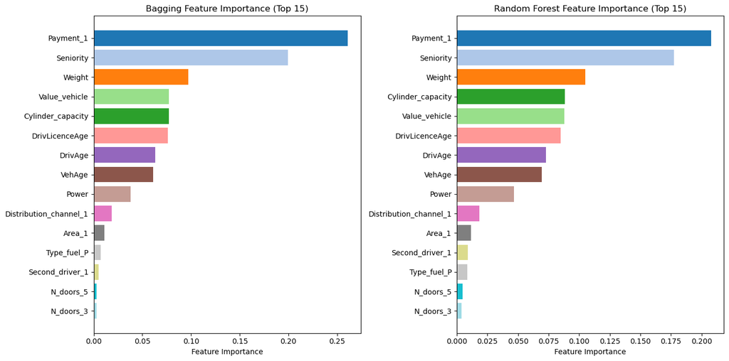

```python
# =========================
# 1. Feature Importances holen
# =========================
bag_imp = pd.Series(
    bagging_model.feature_importances_,
    index=X_train_tree.columns
)

rf_imp = pd.Series(
    rf_model.feature_importances_,
    index=X_train_tree.columns
)

# =========================
# 2. Top Features bestimmen (vereint)
# =========================
top_bag = bag_imp.sort_values(ascending=False).head(15)
top_rf  = rf_imp.sort_values(ascending=False).head(15)

top_features = list(set(top_bag.index).union(set(top_rf.index)))

# Optional: auf 15 reduzieren (nach Durchschnitt)
combined_imp = (bag_imp + rf_imp) / 2
top_features = combined_imp.loc[top_features].sort_values(ascending=False).head(15).index

# =========================
# 3. Farben definieren (pro Feature!)
# =========================
cmap = plt.cm.get_cmap("tab20", len(top_features))
feature_colors = {feat: cmap(i) for i, feat in enumerate(top_features)}

# =========================
# 4. Plot-Funktion
# =========================
def plot_feature_importance_colored(importance_series, features, ax, title):

    imp = importance_series.loc[features].sort_values(ascending=True)

    colors = [feature_colors[f] for f in imp.index]

    ax.barh(imp.index, imp.values, color=colors)
    ax.set_title(title)
    ax.set_xlabel("Feature Importance")

# =========================
# 5. Plot nebeneinander
# =========================
fig, axes = plt.subplots(1, 2, figsize=(14, 7))

plot_feature_importance_colored(
    bag_imp,
    top_features,
    axes[0],
    "Bagging Feature Importance (Top 15)"
)

plot_feature_importance_colored(
    rf_imp,
    top_features,
    axes[1],
    "Random Forest Feature Importance (Top 15)"
)

plt.tight_layout()
plt.show()
```

Die Feature-Importance-Plots von Bagging und Random Forest zeigen insgesamt ein sehr ähnliches Bild. In beiden Modellen gehören dieselben Variablen zu den wichtigsten Einflussgrößen für die Vorhersage der Schadenfrequenz.

In beiden Modellen zählen insbesondere die folgenden Variablen zu den wichtigsten Prädiktoren:

1. `Payment_1`
2. `Seniority`
3. `Weight`
4. `Cylinder_capacity`
5. `Value_vehicle`
6. `DrivLicenceAge`

Das spricht dafür, dass beide baumbasierten Modelle ähnliche Strukturen in den Daten erkennen. Besonders `Payment_1` und `Seniority` haben in beiden Modellen eine sehr hohe Bedeutung.

Insgesamt wirkt die Importance im Random Forest etwas gleichmäßiger verteilt als im Bagging-Modell.

In beiden Modellen haben die folgenden Variablen eine deutlich geringere Bedeutung:

1. `Area_1`
2. `Second_driver_1`
3. `Type_fuel_P`
4. `N_doors_3`
5. `N_doors_5`

Diese Features tragen im Vergleich zu den Top-Variablen nur wenig zur Vorhersage bei. Besonders die Dummy-Variablen von `N_doors` haben in beiden Modellen eine sehr geringe Importance. Das passt zur vorherigen Beobachtung, dass einzelne Tür-Kategorien nur begrenzten zusätzlichen Erklärungsbeitrag liefern.

##### Inhaltliche Plausibilität

Einige der wichtigsten Features sind inhaltlich plausibel. Variablen wie `Seniority` und `DrivLicenceAge` beschreiben die Erfahrung bzw. das Alter der versicherten Person und können mit dem Schadenrisiko zusammenhängen. Fahrzeugbezogene Variablen wie `Weight`, `Cylinder_capacity` und `Value_vehicle` erfassen technische Eigenschaften und den Fahrzeugwert, die ebenfalls für die Schadenfrequenz relevant sein können.

`Payment_1` beschreibt die **zahlweise halbjährlich**. Dass diese Variable im Bagging-Modell und im Random Forest eine sehr hohe Feature Importance besitzt, ist inhaltlich interessant und sollte vorsichtig interpretiert werden.

Eine mögliche Erklärung ist, dass die halbjährliche Zahlweise indirekt mit bestimmten Kundengruppen oder Vertragsstrukturen zusammenhängt. Zum Beispiel können sich Versicherungsnehmer mit halbjährlicher Zahlweise systematisch von anderen Kunden unterscheiden, etwa hinsichtlich Vertragslaufzeit oder Risikoprofil. In diesem Fall wirkt `Payment_1` als Proxy-Variable für solche Unterschiede.

b) Gradient Boosting – LightGBM und XGBoost

Erläutern Sie den fundamentalen Unterschied zwischen dem Resampling-Ansatz von Random Forest (Bootstrap Aggregation) und Gradient Boosting (sequenzielles Lernen). Gehen Sie auf Bias-Variance-Trade-off, Trainingszeit/Parallelisierbarkeit und Overfitting- Robustheit ein. Arbeiten Sie die wesentlichen Unterschiede zwischen LightGBM und XGBoost heraus und begründen Sie, warum beide Verfahren für hochdimensionale Datensätze geeignet sind. Führen Sie für beide Modelle eine systematische Hyperparametersuche durch (z. B. Optuna, Grid Search oder Random Search). Wählen Sie geeignete Parameterbereiche (z.B. Learning Rate, Anzahl Bäume, Baumtiefe, Regularisierung, Subsampling sowie verfahrensspezifische Parameter), begründen Sie die Wahl und nutzen Sie die Poisson-Devianz auf dem Validierungsdatensatz als Optimierungskriterium. Integrieren Sie die Exposure-Variable angemessen in das Training. Dokumentieren Sie die Anzahl der Trials sowie die Optimierungszeit und stellen Sie die besten Hyperparameter-Kombinationen tabellarisch dar. Trainieren Sie die finalen Modelle mit den optimalen Hyperparametern, berechnen Sie die Poisson-Devianz auf Trainingsund Validierungsdaten, fügen Sie die Ergebnisse der Ergebnisdatenstruktur hinzu und dokumentieren Sie die Trainingszeit beider Verfahren. Erstellen Sie Feature-Importance-Plots für LightGBM und XGBoost nebeneinander und visualisieren Sie jeweils die Top-15 wichtigsten Features (mit unterschiedlichen Farben). Identifizieren und interpretieren Sie Gemeinsamkeiten und Unterschiede in der Rangfolge. *Hinweis: Für die volle Punktzahl sollten beide Modelle mindestens so gut sein wie das GLM aus Teilaufgabe B1 d).*

## **Lösung:**

### Gradient Boosting – LightGBM und XGBoost -Theorie

#### Unterschied: Random Forest vs. Gradient Boosting

Random Forest basiert auf Bootstrap Aggregation (Bagging). Dabei werden viele Bäume unabhängig voneinander trainiert und anschließend gemittelt. Ziel ist es, die Varianz zu reduzieren.

Gradient Boosting hingegen basiert auf einem sequenziellen Lernverfahren. Die Bäume werden nacheinander trainiert, wobei jeder neue Baum versucht, die Fehler des vorherigen Modells zu korrigieren.

#### Bias-Variance-Trade-off

Die erwartete Vorhersageabweichung eines Modells kann wie folgt zerlegt werden:

$$ \mathbb{E}[(Y - \hat{f}(X))^2] = \underbrace{\left(\mathbb{E}[\hat{f}(X)] - f(X)\right)^2}_{\text{Bias}^2} + \underbrace{\mathbb{E}\left[(\hat{f}(X) - \mathbb{E}[\hat{f}(X)])^2\right]}_{\text{Varianz}} + \underbrace{\sigma^2}_{\text{Irreduzibler Fehler}} $$

- **Bias** misst, wie stark das Modell im Durchschnitt vom wahren Zusammenhang ( f(X) ) abweicht
- **Varianz** misst, wie stark die Modellvorhersage auf Änderungen der Trainingsdaten reagiert
- **Irreduzibler Fehler** entsteht durch zufällige Einflüsse (z. B. Messrauschen)
- Random Forest: reduziert hauptsächlich die Varianz
- Gradient Boosting: reduziert Bias und kann komplexe Strukturen modellieren

Gradient Boosting erreicht oft bessere Vorhersagegenauigkeit, ist jedoch anfälliger für Overfitting und benötigt sorgfältige Regularisierung.

#### Trainingszeit und Parallelisierung

- Random Forest: gut parallelisierbar (Bäume unabhängig)
- Gradient Boosting: weniger parallelisierbar (sequentiell)

LightGBM verbessert die Effizienz durch histogrammbasiertes Training und leaf-wise Wachstum.

#### Unterschiede LightGBM vs. XGBoost

| Eigenschaft | LightGBM | XGBoost |
| --- | --- | --- |
| Wachstum | leaf-wise | level-wise |
| Geschwindigkeit | sehr schnell | etwas langsamer |
| Overfitting | höheres Risiko | stabiler |
| Speicher | effizient | höher |

Beide Verfahren sind gut für hochdimensionale Daten geeignet, da sie:

- automatische Feature-Selektion durchführen
- Interaktionen modellieren
- nichtlineare Zusammenhänge erfassen

#### LightGBM mit Optuna

Wir benutzen die Datensätze aus Teilaufgabe B2a).

Für das LightGBM-Modell wurde eine Hyperparameter-Optimierung mit `Optuna` durchgeführt. Ziel war es, die Poisson-Devianz auf dem Validierungsdatensatz zu minimieren. Da es sich bei der Zielgröße um eine Schadenfrequenz bzw. Schadenanzahl handelt, wurde die Objective-Funktion `poisson` verwendet.

```python
def objective_lgb(trial):
    params = {
        "objective": "poisson",
        "n_estimators":trial.suggest_int("n_estimators",1000,4000),
        "learning_rate": trial.suggest_float("learning_rate", 0.003, 0.03, log=True),
        "max_depth": trial.suggest_int("max_depth", 2, 4),
        "num_leaves": trial.suggest_int("num_leaves", 4, 16),
       "subsample": trial.suggest_float("subsample", 0.8, 1.0),
        "reg_alpha": trial.suggest_float("reg_alpha", 1e-8, 10.0, log=True),
        "reg_lambda": trial.suggest_float("reg_lambda", 1e-8, 10.0, log=True),
        "random_state": RANDOM_SEED, #reproduzierbarkeit gareantieren - start
        "bagging_seed": RANDOM_SEED,
        "feature_fraction_seed": RANDOM_SEED,
        "data_random_seed": RANDOM_SEED,
        "deterministic": True,
        "force_col_wise": True,
        "n_jobs": 1,      #reproduzierbarkeit gareantieren - ende
        "verbosity": -1
    }
    model = lgb.LGBMRegressor(**params)
    model.fit(
        X_train_tree,
        freq_train,
        sample_weight=exposure_train,
        eval_set=[(X_valid_tree, freq_valid)],
        eval_sample_weight=[exposure_valid],
        callbacks=[lgb.early_stopping(10, verbose=False)]
    )

    pred_valid_freq = model.predict(X_valid_tree)
    pred_valid_freq = np.clip(pred_valid_freq, 1e-12, None)
    pred_valid_count = pred_valid_freq * exposure_valid
    pdw_valid = PDW(pred_valid_count, y_valid)
    return pdw_valid
#Reproduzierbarkeit garantieren
sampler = optuna.samplers.TPESampler(seed=RANDOM_SEED)

start_opt_lgb = time.time()
study_lgb = optuna.create_study(
    direction="minimize",
    sampler=sampler
)
study_lgb.optimize(
    objective_lgb,
    n_trials=50,
    n_jobs=1 # keine Paralellisierung wegen der Reproduzierbarkeit
)

opt_time_lgb = time.time() - start_opt_lgb
#LightGBM: beste Trials tabellarisch
lgb_trials_df = study_lgb.trials_dataframe()
lgb_trials_df = lgb_trials_df.sort_values("value").reset_index(drop=True)

display(lgb_trials_df.head(10))

print("Beste LightGBM-Parameter:")
print(study_lgb.best_params)

print(f"Beste Validierungs-PDW: {study_lgb.best_value:.4f} %")
print(f"Optimierungszeit LightGBM: {opt_time_lgb:.2f} Sekunden")
#Finales LightGBM trainieren
best_params_lgb = study_lgb.best_params.copy()
best_params_lgb.update({
        "objective": "poisson",
        "random_state": RANDOM_SEED, #reproduzierbarkeit gareantieren - start
        "bagging_seed": RANDOM_SEED,
        "feature_fraction_seed": RANDOM_SEED,
        "data_random_seed": RANDOM_SEED,
        "deterministic": True,
        "force_col_wise": True,
        "n_jobs": 1,      #reproduzierbarkeit gareantieren - ende
        "verbosity": -1
})
start_time = time.time()

final_lgb = lgb.LGBMRegressor(**best_params_lgb)

final_lgb.fit(
    X_train_tree,
    freq_train,
    sample_weight=exposure_train,
     eval_set=[(X_valid_tree, freq_valid)],
     eval_sample_weight=[exposure_valid],
    callbacks=[lgb.early_stopping(10, verbose=False)]
)

fit_time_lgb = time.time() - start_time
freq_pred_train_lgb = final_lgb.predict(X_train_tree)
freq_pred_valid_lgb = final_lgb.predict(X_valid_tree)
# Frequenz darf nicht negativ sein
freq_pred_train_lgb = np.clip(freq_pred_train_lgb, 1e-12, None)
freq_pred_valid_lgb = np.clip(freq_pred_valid_lgb, 1e-12, None)
# erwartete Schadenanzahl = Frequenz * Exposure
pred_train_lgb = freq_pred_train_lgb * exposure_train
pred_valid_lgb = freq_pred_valid_lgb * exposure_valid
fit_and_predict_time_lgb = time.time() - start_time
pdw_train_lgb = PDW(pred_train_lgb,y_train_tree,exposure_train)
pdw_valid_lgb = PDW(pred_valid_lgb,y_valid_tree,exposure_valid)

cf_train_actual = CF_calculate(y_train_tree, exposure_train)
cf_train_pred   = CF_calculate(pred_train_lgb, exposure_train)
cf_valid_actual = CF_calculate(y_valid_tree, exposure_valid)
cf_valid_pred   = CF_calculate(pred_valid_lgb, exposure_valid)
model_results_df = add_model_result(
    model_results_df=model_results_df,
    model_name="LightGBM",
    metric_name="PDW",
    metric_train=pdw_train_lgb,
    metric_valid=pdw_valid_lgb,
    metric_test=np.nan,
    fit_time_sec=fit_time_lgb,
    fit_and_predict_time_sec=fit_and_predict_time_lgb,
    CF_train_act=cf_train_actual,
    CF_train_pred=cf_train_pred,
    CF_valid_act=cf_valid_actual,
    CF_valid_pred=cf_valid_pred,
    CF_test_act=np.nan,
    CF_test_pred=np.nan,
    notes=f"Optuna Trials=50, opt_time={opt_time_lgb:.2f}s"
)
```

[output not shown]

[output cut: 37 more lines]

|  | number | value | datetime_start | datetime_complete | duration | params_learning_rate | params_max_depth | params_n_estimators | params_num_leaves | params_reg_alpha | params_reg_lambda | params_subsample | state |
| --- | --- | --- | --- | --- | --- | --- | --- | --- | --- | --- | --- | --- | --- |
| 0 | 34 | 1.521082 | 2026-05-05 22:27:15.045149 | 2026-05-05 22:27:15.970861 | 0 days 00:00:00.925712 | 0.018867 | 2 | 3442 | 15 | 9.708863 | 0.182235 | 0.900858 | COMPLETE |
| 1 | 10 | 1.521208 | 2026-05-05 22:26:47.673066 | 2026-05-05 22:26:48.367149 | 0 days 00:00:00.694083 | 0.029049 | 2 | 2832 | 16 | 7.615576 | 0.004746 | 0.802394 | COMPLETE |
| 2 | 12 | 1.521221 | 2026-05-05 22:26:48.816777 | 2026-05-05 22:26:49.736208 | 0 days 00:00:00.919431 | 0.029042 | 2 | 2571 | 12 | 8.858765 | 0.000972 | 0.902536 | COMPLETE |
| 3 | 2 | 1.521286 | 2026-05-05 22:26:35.443629 | 2026-05-05 22:26:36.949183 | 0 days 00:00:01.505554 | 0.010932 | 2 | 3430 | 14 | 7.661375 | 0.000002 | 0.936850 | COMPLETE |
| 4 | 41 | 1.521388 | 2026-05-05 22:27:21.461364 | 2026-05-05 22:27:23.031235 | 0 days 00:00:01.569871 | 0.010517 | 2 | 3794 | 16 | 8.209466 | 0.008286 | 0.909689 | COMPLETE |
| 5 | 43 | 1.521403 | 2026-05-05 22:27:23.993045 | 2026-05-05 22:27:25.962921 | 0 days 00:00:01.969876 | 0.007968 | 2 | 3651 | 16 | 7.779324 | 0.002264 | 0.911264 | COMPLETE |
| 6 | 31 | 1.521929 | 2026-05-05 22:27:11.480898 | 2026-05-05 22:27:12.976211 | 0 days 00:00:01.495313 | 0.014040 | 2 | 3858 | 15 | 6.720143 | 0.000582 | 0.910012 | COMPLETE |
| 7 | 22 | 1.521934 | 2026-05-05 22:26:57.356093 | 2026-05-05 22:26:58.612610 | 0 days 00:00:01.256517 | 0.012714 | 2 | 3940 | 15 | 8.265696 | 0.000721 | 0.916791 | COMPLETE |
| 8 | 49 | 1.522493 | 2026-05-05 22:27:30.364496 | 2026-05-05 22:27:31.204982 | 0 days 00:00:00.840486 | 0.012911 | 4 | 3145 | 13 | 0.000000 | 0.001582 | 0.891960 | COMPLETE |
| 9 | 21 | 1.522508 | 2026-05-05 22:26:55.880883 | 2026-05-05 22:26:57.350958 | 0 days 00:00:01.470075 | 0.009290 | 2 | 3370 | 14 | 6.425807 | 0.000007 | 0.951692 | COMPLETE |

```
Beste LightGBM-Parameter:
{'n_estimators': 3442, 'learning_rate': 0.01886663454923269, 'max_depth': 2, 'num_leaves': 15, 'subsample': 0.9008583379015963, 'reg_alpha': 9.708863129058303, 'reg_lambda': 0.182234867242225}
Beste Validierungs-PDW: 1.5211 %
Optimierungszeit LightGBM: 59.13 Sekunden
```

Mit `early_stopping` kann es sein, dass das beste Modell weniger Bäume verwendet als der im Hyperparameter-Tuning gewählte Wert für `n_estimators`.

```python
print("Anzahl verwendeter Bäume:", final_lgb.booster_.num_trees())
```

```
Anzahl verwendeter Bäume: 1049
```

```python
show_model_results(
    model_results_df,
    metric="PDW",
    sort_by="metric_valid",
    ascending=True,
    digits=4
)
```

|  | model_name | metric_name | metric_train | metric_valid | metric_test | fit_time_sec | fit_and_predict_time_sec | CF_train_act | CF_train_pred | CF_valid_act | CF_valid_pred | CF_test_act | CF_test_pred | notes |
| --- | --- | --- | --- | --- | --- | --- | --- | --- | --- | --- | --- | --- | --- | --- |
| 0 | LightGBM | PDW | 1.602600 | 1.528600 | NaN | 0.751200 | 1.135100 | 67.2597 % | 67.2865 % | 59.1986 % | 66.4319 % | NaN | NaN | Optuna Trials=50, opt_time=59.13s |
| 1 | RF | PDW | 1.552400 | 1.530900 | NaN | 6.435800 | 7.016300 | 67.2597 % | 67.2278 % | 59.1986 % | 66.5804 % | NaN | NaN | Random Forest mit Poisson-Kriterium, max_featu... |
| 2 | Bagging | PDW | 1.580500 | 1.531100 | NaN | 26.712100 | 27.624500 | 67.2597 % | 67.2105 % | 59.1986 % | 66.5944 % | NaN | NaN | Bagging mit Poisson-Kriterium, max_features=1.... |
| 3 | GLM | PDW | 1.643600 | 1.532900 | NaN | 0.234300 | 0.418400 | 67.2597 % | 67.2597 % | 59.1986 % | 66.2701 % | NaN | NaN | Poisson-GLM mit vollständigem Featureset und O... |
| 4 | CANN | PDW | 1.642900 | 1.540300 | NaN | 8.053900 | 8.939600 | 67.2597 % | 67.0552 % | 59.1986 % | 66.0535 % | NaN | NaN | CANN ohne Embeddings; GLM-Skip-Connection über... |
| 5 | LASSO | PDW | 1.643700 | 1.541000 | NaN | 4.322000 | 4.323500 | 67.2597 % | 67.3108 % | 59.1986 % | 66.347 % | NaN | NaN | alpha=0.0005, l1_wt=1.0 (fixiert) |
| 6 | Intercept-Only Baseline(INT) | PDW | 1.716800 | 1.633900 | NaN | 0.004100 | 0.004100 | 67.2597 % | 67.2597 % | 59.1986 % | 67.2597 % | NaN | NaN | baseline_frequency=67.2597%, intercept=-0.3966 |
| 7 | Intercept-Only Baseline(mit GLM) | PDW | 1.716800 | 1.633900 | NaN | 0.042900 | 0.046700 | 67.2597 % | 67.2597 % | 59.1986 % | 67.2597 % | NaN | NaN | baseline_frequency=67.2597%, intercept=-0.3966 |

### XGBoost mit Optuna

```python
def objective_xgb(trial):

    params = {
        "objective": "count:poisson",
        "n_estimators": trial.suggest_int("n_estimators", 1000, 4000),
        "learning_rate": trial.suggest_float("learning_rate", 0.003, 0.03, log=True),
        "max_depth": trial.suggest_int("max_depth", 2, 4),
        "subsample": trial.suggest_float("subsample", 0.8, 1.0),
        "reg_alpha": trial.suggest_float("reg_alpha", 1e-8, 10.0, log=True),
        "reg_lambda": trial.suggest_float("reg_lambda", 1e-8, 10.0, log=True),
        "gamma": trial.suggest_float("gamma", 0.0, 5.0),
         "early_stopping_rounds":10,
        "eval_metric": "poisson-nloglik",
        "random_state": RANDOM_SEED,   #Reproduzierbarkeit garantieren - start
         "seed": RANDOM_SEED,
         "n_jobs": 1,
          "tree_method": "hist"  #Reproduzierbarkeit garantieren - ende

    }

    model = xgb.XGBRegressor(**params)
    model.fit(
        X_train_tree,
        freq_train,
        sample_weight=exposure_train,
        eval_set=[(X_valid_tree, freq_valid)],
        sample_weight_eval_set=[exposure_valid],
        verbose=False
    )

    pred_valid_freq = model.predict(X_valid_tree)
    pred_valid_freq = np.clip(pred_valid_freq, 1e-12, None)
    pred_valid_count = pred_valid_freq * exposure_valid
    pdw_valid = PDW(pred_valid_count, y_valid)
    return pdw_valid
#Reproduzierbarkeit garantieren
sampler = optuna.samplers.TPESampler(seed=RANDOM_SEED)

start_opt_xgb = time.time()

study_xgb = optuna.create_study(direction="minimize",
    sampler=sampler)
study_xgb.optimize(objective_xgb, n_trials=50,n_jobs=1) #n_jobs =keine Parallelisierung der Trials -> Reproduzierbarkeit

opt_time_xgb = time.time() - start_opt_xgb
#XGBoost: beste Trials tabellarisch
xgb_trials_df = study_xgb.trials_dataframe()
xgb_trials_df = xgb_trials_df.sort_values("value").reset_index(drop=True)

display(xgb_trials_df.head(10))

print("Beste XGBoost-Parameter:")
print(study_xgb.best_params)

print(f"Beste Validierungs-PDW: {study_xgb.best_value:.4f} %")
print(f"Optimierungszeit XGBoost: {opt_time_xgb:.2f} Sekunden")
#finales XGBoost trainieren
best_params_xgb = study_xgb.best_params.copy()

best_params_xgb.update({
    "objective": "count:poisson",
    "eval_metric": "poisson-nloglik",#Early stopping
    "random_state": RANDOM_SEED,   #Reproduzierbarkeit garantieren - start
     "seed": RANDOM_SEED,
      "n_jobs": 1,
     "tree_method": "hist",
     "early_stopping_rounds":10 #Reproduzierbarkeit garantieren - ende
})

start_time = time.time()

final_xgb = xgb.XGBRegressor(**best_params_xgb)

final_xgb.fit(
        X_train_tree,
        freq_train,
        sample_weight=exposure_train,
        eval_set=[(X_valid_tree, freq_valid)],
        sample_weight_eval_set=[exposure_valid],
        verbose=False
)

fit_time_xgb = time.time() - start_time
freq_pred_train_xgb = final_xgb.predict(X_train_tree)
freq_pred_valid_xgb = final_xgb.predict(X_valid_tree)
# Frequenz darf nicht negativ sein
freq_pred_train_xgb = np.clip(freq_pred_train_xgb, 1e-12, None)
freq_pred_valid_xgb = np.clip(freq_pred_valid_xgb, 1e-12, None)
# erwartete Schadenanzahl = Frequenz * Exposure
pred_train_xgb = freq_pred_train_xgb * exposure_train
pred_valid_xgb = freq_pred_valid_xgb * exposure_valid
fit_and_predict_time_xgb = time.time() - start_time
pdw_train_xgb = PDW(pred_train_xgb, y_train_tree,exposure_train)
pdw_valid_xgb = PDW(pred_valid_xgb, y_valid_tree,exposure_valid)

cf_train_actual = CF_calculate(y_train_tree, exposure_train)
cf_train_pred   = CF_calculate(pred_train_xgb, exposure_train)
cf_valid_actual = CF_calculate(y_valid_tree, exposure_valid)
cf_valid_pred   = CF_calculate(pred_valid_xgb, exposure_valid)
model_results_df = add_model_result(
    model_results_df=model_results_df,
    model_name="XGBoost",
    metric_name="PDW",
    metric_train=pdw_train_xgb,
    metric_valid=pdw_valid_xgb,
    metric_test=np.nan,
    fit_time_sec=fit_time_xgb,
    fit_and_predict_time_sec=fit_and_predict_time_xgb,
    CF_train_act=cf_train_actual,
    CF_train_pred=cf_train_pred,
    CF_valid_act=cf_valid_actual,
    CF_valid_pred=cf_valid_pred,
    CF_test_act=np.nan,
    CF_test_pred=np.nan,
    notes=f"Optuna Trials=50, opt_time={opt_time_xgb:.2f}s"
)
```

[output not shown]

[output cut: 37 more lines]

|  | number | value | datetime_start | datetime_complete | duration | params_gamma | params_learning_rate | params_max_depth | params_n_estimators | params_reg_alpha | params_reg_lambda | params_subsample | state |
| --- | --- | --- | --- | --- | --- | --- | --- | --- | --- | --- | --- | --- | --- |
| 0 | 28 | 1.517016 | 2026-05-05 22:28:46.746026 | 2026-05-05 22:28:48.071256 | 0 days 00:00:01.325230 | 3.513012 | 0.029999 | 3 | 2770 | 0.000001 | 0.000243 | 0.800436 | COMPLETE |
| 1 | 33 | 1.518326 | 2026-05-05 22:29:01.098820 | 2026-05-05 22:29:02.780351 | 0 days 00:00:01.681531 | 3.097791 | 0.025824 | 4 | 2664 | 0.000000 | 0.000015 | 0.818093 | COMPLETE |
| 2 | 23 | 1.518550 | 2026-05-05 22:28:39.225971 | 2026-05-05 22:28:40.556163 | 0 days 00:00:01.330192 | 2.914496 | 0.029558 | 3 | 2274 | 0.000001 | 0.000030 | 0.834818 | COMPLETE |
| 3 | 13 | 1.518635 | 2026-05-05 22:28:17.821164 | 2026-05-05 22:28:19.301284 | 0 days 00:00:01.480120 | 3.127289 | 0.024991 | 4 | 2823 | 0.000000 | 0.000284 | 0.802306 | COMPLETE |
| 4 | 42 | 1.518679 | 2026-05-05 22:29:30.637041 | 2026-05-05 22:29:31.816562 | 0 days 00:00:01.179521 | 3.012092 | 0.029920 | 4 | 2940 | 0.071912 | 0.000060 | 0.814593 | COMPLETE |
| 5 | 10 | 1.518687 | 2026-05-05 22:28:14.624824 | 2026-05-05 22:28:15.726068 | 0 days 00:00:01.101244 | 3.153501 | 0.029049 | 4 | 2604 | 0.000000 | 0.000019 | 0.812098 | COMPLETE |
| 6 | 36 | 1.518784 | 2026-05-05 22:29:07.782081 | 2026-05-05 22:29:09.498547 | 0 days 00:00:01.716466 | 1.763185 | 0.022320 | 4 | 2718 | 0.000000 | 0.000144 | 0.800430 | COMPLETE |
| 7 | 40 | 1.518993 | 2026-05-05 22:29:26.906479 | 2026-05-05 22:29:29.481058 | 0 days 00:00:02.574579 | 1.553861 | 0.013219 | 3 | 2389 | 0.000619 | 0.000001 | 0.818567 | COMPLETE |
| 8 | 18 | 1.519482 | 2026-05-05 22:28:25.147955 | 2026-05-05 22:28:28.129123 | 0 days 00:00:02.981168 | 3.298083 | 0.014990 | 2 | 1992 | 0.000000 | 0.000005 | 0.815582 | COMPLETE |
| 9 | 24 | 1.519513 | 2026-05-05 22:28:40.556163 | 2026-05-05 22:28:41.871273 | 0 days 00:00:01.315110 | 2.821728 | 0.028346 | 3 | 2460 | 0.000002 | 0.000100 | 0.834395 | COMPLETE |

```
Beste XGBoost-Parameter:
{'n_estimators': 2770, 'learning_rate': 0.029998569098848994, 'max_depth': 3, 'subsample': 0.8004355124600608, 'reg_alpha': 1.1070652220451365e-06, 'reg_lambda': 0.00024302895314517198, 'gamma': 3.513012055123247}
Beste Validierungs-PDW: 1.5170 %
Optimierungszeit XGBoost: 131.57 Sekunden
```

Anzahl verwendeter Bäume:

```python
print("Anzahl verwendeter Bäume:", final_xgb.best_iteration + 1)
```

```
Anzahl verwendeter Bäume: 384
```

```python
show_model_results(
    model_results_df,
    metric="PDW",
    sort_by="metric_valid",
    ascending=True,
    digits=4
)
```

|  | model_name | metric_name | metric_train | metric_valid | metric_test | fit_time_sec | fit_and_predict_time_sec | CF_train_act | CF_train_pred | CF_valid_act | CF_valid_pred | CF_test_act | CF_test_pred | notes |
| --- | --- | --- | --- | --- | --- | --- | --- | --- | --- | --- | --- | --- | --- | --- |
| 0 | XGBoost | PDW | 1.572300 | 1.525100 | NaN | 1.398600 | 1.467800 | 67.2597 % | 67.2251 % | 59.1986 % | 66.5718 % | NaN | NaN | Optuna Trials=50, opt_time=131.57s |
| 1 | LightGBM | PDW | 1.602600 | 1.528600 | NaN | 0.751200 | 1.135100 | 67.2597 % | 67.2865 % | 59.1986 % | 66.4319 % | NaN | NaN | Optuna Trials=50, opt_time=59.13s |
| 2 | RF | PDW | 1.552400 | 1.530900 | NaN | 6.435800 | 7.016300 | 67.2597 % | 67.2278 % | 59.1986 % | 66.5804 % | NaN | NaN | Random Forest mit Poisson-Kriterium, max_featu... |
| 3 | Bagging | PDW | 1.580500 | 1.531100 | NaN | 26.712100 | 27.624500 | 67.2597 % | 67.2105 % | 59.1986 % | 66.5944 % | NaN | NaN | Bagging mit Poisson-Kriterium, max_features=1.... |
| 4 | GLM | PDW | 1.643600 | 1.532900 | NaN | 0.234300 | 0.418400 | 67.2597 % | 67.2597 % | 59.1986 % | 66.2701 % | NaN | NaN | Poisson-GLM mit vollständigem Featureset und O... |
| 5 | CANN | PDW | 1.642900 | 1.540300 | NaN | 8.053900 | 8.939600 | 67.2597 % | 67.0552 % | 59.1986 % | 66.0535 % | NaN | NaN | CANN ohne Embeddings; GLM-Skip-Connection über... |
| 6 | LASSO | PDW | 1.643700 | 1.541000 | NaN | 4.322000 | 4.323500 | 67.2597 % | 67.3108 % | 59.1986 % | 66.347 % | NaN | NaN | alpha=0.0005, l1_wt=1.0 (fixiert) |
| 7 | Intercept-Only Baseline(INT) | PDW | 1.716800 | 1.633900 | NaN | 0.004100 | 0.004100 | 67.2597 % | 67.2597 % | 59.1986 % | 67.2597 % | NaN | NaN | baseline_frequency=67.2597%, intercept=-0.3966 |
| 8 | Intercept-Only Baseline(mit GLM) | PDW | 1.716800 | 1.633900 | NaN | 0.042900 | 0.046700 | 67.2597 % | 67.2597 % | 59.1986 % | 67.2597 % | NaN | NaN | baseline_frequency=67.2597%, intercept=-0.3966 |

#### Hyperrparemeter Auswahl & Begründung

[output not shown]

Gradient Boosting Modelle zeigen typischerweise eine bessere Performance als Random Forest und Bagging, da sie Fehler iterativ korrigieren. Konkret haben sie auch hier bessere Performance gezeigt.

LightGBM erreicht oft eine sehr gute Performance durch effizienteres Training. XGBoost ist stabiler und robuster, benötigt jedoch mehr Rechenzeit.

Da Poisson-Devianz niedriger ist als beim GLM, deutet dies darauf hin, dass nichtlineare Effekte und Interaktionen erfolgreich modelliert wurden.

### Feature Importance

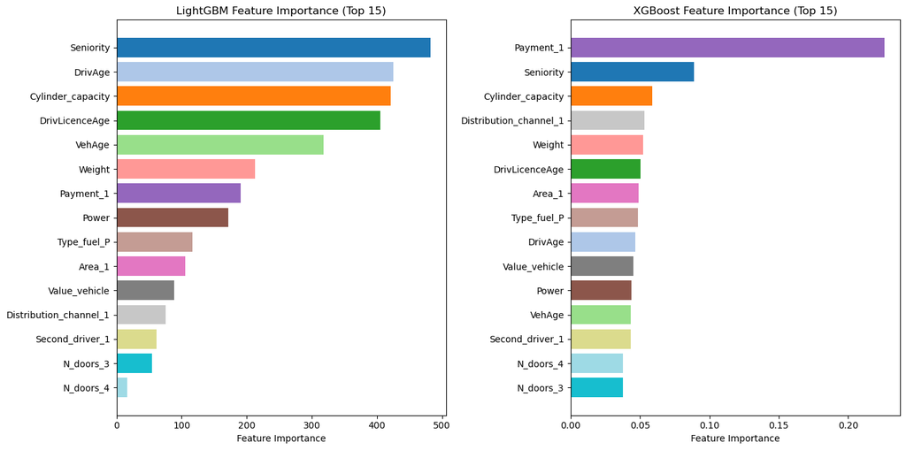

```python
# =========================
# 1. Top Features bestimmen (vereint aus beiden Modellen)
# =========================
lgb_imp = pd.Series(final_lgb.feature_importances_, index=X_train_tree.columns)
xgb_imp = pd.Series(final_xgb.feature_importances_, index=X_train_tree.columns)

top_lgb = lgb_imp.sort_values(ascending=False).head(15)
top_xgb = xgb_imp.sort_values(ascending=False).head(15)

# Vereinigung der wichtigsten Features
top_features = list(set(top_lgb.index).union(set(top_xgb.index)))

# Optional: auf 15 beschränken (nach Durchschnitt)
combined_imp = (lgb_imp + xgb_imp) / 2
top_features = combined_imp.loc[top_features].sort_values(ascending=False).head(15).index

# =========================
# 2. Farben pro Feature definieren
# =========================
cmap = plt.cm.get_cmap("tab20", len(top_features))
feature_colors = {feat: cmap(i) for i, feat in enumerate(top_features)}

# =========================
# 3. Plot-Funktion
# =========================
def plot_feature_importance_colored(importance_series, features, ax, title):

    imp = importance_series.loc[features].sort_values(ascending=True)

    colors = [feature_colors[f] for f in imp.index]

    ax.barh(imp.index, imp.values, color=colors)
    ax.set_title(title)
    ax.set_xlabel("Feature Importance")

# =========================
# 4. Plot nebeneinander
# =========================
fig, axes = plt.subplots(1, 2, figsize=(14, 7))

plot_feature_importance_colored(
    lgb_imp,
    top_features,
    axes[0],
    "LightGBM Feature Importance (Top 15)"
)

plot_feature_importance_colored(
    xgb_imp,
    top_features,
    axes[1],
    "XGBoost Feature Importance (Top 15)"
)

plt.tight_layout()
plt.show()
```

#### Interpretation der Feature Importances (LightGBM vs. XGBoost)

Die Feature-Importance-Plots zeigen deutliche Unterschiede zwischen LightGBM und XGBoost.

##### LightGBM

Bei LightGBM sind vor allem folgende Variablen wichtig:

1. `Seniority`
2. `DrivAge`
3. `Cylinder_capacity`
4. `DrivLicenceAge`
5. `VehAge`
6. `Weight`

LightGBM verteilt die Bedeutung relativ breit über mehrere fahrer- und fahrzeugbezogene Variablen. Besonders wichtig sind Merkmale zur Fahrererfahrung bzw. zum Alter sowie technische Fahrzeugmerkmale.

Auffällig ist, dass `Payment_1` bei LightGBM zwar relevant ist, aber nicht zu den dominierenden Variablen gehört. Das Modell scheint stärker auf kontinuierliche Merkmale wie `Seniority`, `DrivAge`, `Cylinder_capacity` und `DrivLicenceAge` zurückzugreifen.

##### XGBoost

Bei XGBoost dominiert dagegen sehr deutlich:

1. `Payment_1`

Danach folgen mit großem Abstand:

1. `Seniority`
2. `Cylinder_capacity`
3. `Distribution_channel_1`
4. `Weight`

Die Feature Importance ist bei XGBoost deutlich stärker auf `Payment_1` konzentriert. Da `Payment_1` die halbjährliche Zahlweise beschreibt, deutet dies darauf hin, dass XGBoost diese Variable besonders stark zur Segmentierung der Risiken nutzt.

c) Boosting-Modelle mit Monotoniebeschränkungen

Erweitern Sie die in Teilaufgabe b) entwickelten Gradient-Boosting-Modelle (LightGBM und XGBoost) um Monotoniebeschränkungen. Ziel ist es, fachliche Plausibilität zu integrieren und die Interpretierbarkeit zu verbessern. Erläutern Sie kurz, warum Monotoniebeschränkungen in der Versicherungstarifierung relevant sind und diskutieren Sie den Trade-off zwischen Modellgüte und Plausibilität. Beschreiben Sie kurz, wie LightGBM und XGBoost Monotoniebeschränkungen während des Trainings umsetzen. Wählen Sie mindestens ein Feature aus, für das eine Monotoniebeschränkung fachlich plausibel ist, und begründen Sie Ihre Wahl (fachliche Kausalität, empirische Evidenz aus Teil A). Trainieren Sie LightGBM und XGBoost jeweils mit Monotoniebeschränkungen, übernehmen Sie die optimalen Hyperparameter aus Teilaufgabe b) und dokumentieren Sie Trainings- bzw. Optimierungszeit. Integrieren Sie Exposure als Gewichtung. Berechnen Sie die Poisson-Devianz auf Trainings- und Validierungsdaten, fügen Sie die Ergebnisse der Ergebnisdatenstruktur hinzu und vergleichen Sie mit den unbeschränkten Modellen aus Teilaufgabe b). Bewerten Sie den Performance-Verlust. Erstellen Sie für jedes Feature mit Monotoniebeschränkung Partial Dependence Plots (PDPs) und vergleichen Sie unbeschränkte vs. beschränkte Modelle: – Erstellen Sie ein 2 × 2-Grid mit vier PDPs: * LightGBM ohne Monotonie, * LightGBM mit Monotonie, * XGBoost ohne Monotonie, * XGBoost mit Monotonie. – Nutzen Sie möglichst Bibliotheksfunktionen; falls notwendig, implementieren Sie einen manuellen PDP (Feature über z. B. 1%–99%-Quantil variieren, andere Features fixieren, mindestens 50 Gridpunkte). Interpretieren Sie die PDPs, identifizieren Sie Monotonieverletzungen in unbeschränkten Modellen und zeigen Sie, dass beschränkte Modelle (streng) monoton sind. Vergleichen Sie LightGBM und XGBoost hinsichtlich möglicher Unterschiede.

## **Lösung:**

### Monotoniebeschränkungen in der Versicherungstarifierung

Monotoniebeschränkungen sind in der Versicherungstarifierung relevant, weil viele Risikomerkmale fachlich eine erwartete Wirkungsrichtung haben. Beispielsweise kann erwartet werden, dass ein höheres Fahrzeugalter, eine höhere Motorleistung oder bestimmte Risikoklassen nicht zu einer sinkenden erwarteten Schadenfrequenz führen sollten, sofern alle anderen Merkmale konstant bleiben.

Solche Beschränkungen helfen, Modelle fachlich plausibler, stabiler und besser erklärbar zu machen. Das ist besonders wichtig, wenn Tarife gegenüber Fachabteilungen, Vertrieb, Aufsicht oder Kunden begründet werden müssen.

#### Trade-off zwischen Modellgüte und Plausibilität

Monotoniebeschränkungen reduzieren die Flexibilität des Modells. Dadurch kann die reine Prognosegüte, zum Beispiel gemessen an der Poisson-Devianz, etwas schlechter werden, weil das Modell nicht mehr jede beliebige Struktur in den Trainingsdaten lernen darf.

Der Vorteil ist jedoch, dass das Modell robuster und fachlich nachvollziehbarer wird. Es werden unplausible Effekte vermieden, etwa dass ein klar risikosteigerndes Merkmal lokal zu niedrigeren Prämien führt. In der Versicherungstarifierung kann daher ein leicht schlechterer Validierungswert akzeptabel sein, wenn das Modell dadurch plausibler, stabiler und regulatorisch besser vertretbar wird.

#### Umsetzung in LightGBM und XGBoost

Sowohl **LightGBM** als auch **XGBoost** unterstützen Monotoniebeschränkungen über den Parameter `monotone_constraints`.

Dabei wird für jedes Feature festgelegt, ob sein Effekt:

- `+1`: monoton steigend sein soll,
- `-1`: monoton fallend sein soll,
- `0`: nicht beschränkt ist.

Beispiel:

```
monotone_constraints = [1, 0, -1, 0]
```

### Auswahl des Features für die Monotoniebeschränkung

Für die Monotoniebeschränkung wurde die Variable `Power`(Leistungsstärke des Fahrzeuges) gewählt.

Fachlich ist ein monoton steigender Zusammenhang plausibel, da leistungsstärkere Fahrzeuge sind potenziell mit risikoreicherem Fahrverhalten verbunden sein können. Daher ist es sinnvoll anzunehmen, dass die Schadenfrequenz mit zunehmendem Fahrzeugsleistungsstärke nicht sinkt.

Die Monotoniebeschränkung auf `Power` stellt daher einen fachlich plausiblen Kompromiss zwischen Modellflexibilität und interpretierbarer Tarifierungslogik dar.

#### Diskussion über andere Features

Andere potenzielle Variablen wie `DrivLicenceAge` oder `DrivAge` wurden bewusst nicht gewählt, da deren Zusammenhang mit der Schadenfrequenz über den gesamten Wertebereich nicht zwingend sinkend ist. Insbesondere bei älteren Fahrern können altersbedingte Faktoren wie Reaktionszeit oder körperliche Fitness zu einer erneuten Risikoerhöhung führen.

Die kategoriale Merkmale sind mesitens nur binär, mit der Ausnahme von `N_doors` – hier fehlt jedoch eine fachlich plausible und stabile Begründung für eine Monotonie.

Andere kontinuierliche Merkmale stellen Fahrzeugdaten dar und sind im Wesentlichen mit `Power` korreliert (sehen Sie bitte dafür die Lösung der Teilaufgabe A1.d)). Dabei `Weight` gehört in mehreren Modellen (GLM, LASSO, LightGBM, XGBoost) zu den wichtigsten Einflussgrößen.

#### `Power` oder `Weight` ?

Für die Auswahl eines Features zur Monotoniebeschränkung werden im Nächsten sowohl `Power` als auch `Weight` hinsichtlich ihres Zusammenhangs mit der Schadenfrequenz untersucht.

##### `Power`

|  | Power_bin | Power_mean | claims_sum | exposure_sum | n_obs | Frequency | se_frequency | ci_lower | ci_upper |
| --- | --- | --- | --- | --- | --- | --- | --- | --- | --- |
| 0 | (58.999, 68.0] | 63.158416 | 659 | 1273.319463 | 1313 | 0.517545 | 0.020161 | 0.478030 | 0.557060 |
| 1 | (68.0, 75.0] | 72.849747 | 1060 | 1743.599521 | 1777 | 0.607938 | 0.018673 | 0.571339 | 0.644536 |
| 2 | (75.0, 83.0] | 80.647378 | 348 | 539.000861 | 553 | 0.645639 | 0.034610 | 0.577804 | 0.713474 |
| 3 | (83.0, 90.0] | 89.094877 | 1343 | 2068.292425 | 2108 | 0.649328 | 0.017718 | 0.614600 | 0.684056 |
| 4 | (90.0, 95.0] | 93.554252 | 193 | 332.695479 | 341 | 0.580110 | 0.041757 | 0.498266 | 0.661954 |
| 5 | (95.0, 105.0] | 102.149087 | 1267 | 1928.166884 | 1972 | 0.657101 | 0.018461 | 0.620918 | 0.693283 |
| 6 | (105.0, 110.0] | 109.735736 | 933 | 1305.921880 | 1332 | 0.714438 | 0.023390 | 0.668594 | 0.760282 |
| 7 | (110.0, 115.0] | 114.428571 | 514 | 646.957669 | 665 | 0.794488 | 0.035043 | 0.725803 | 0.863173 |
| 8 | (115.0, 130.0] | 123.967890 | 608 | 852.371233 | 872 | 0.713304 | 0.028928 | 0.656605 | 0.770004 |
| 9 | (130.0, 163.0] | 142.878711 | 867 | 1149.559391 | 1179 | 0.754202 | 0.025614 | 0.703998 | 0.804406 |

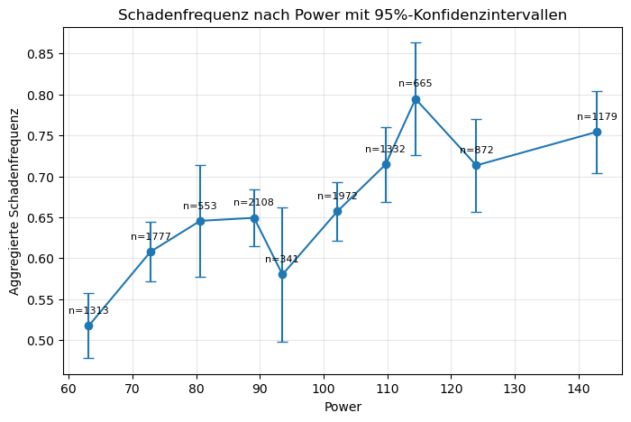

```python
# =========================
# Train + Valid kombinieren
# =========================

df_train = pd.DataFrame({
    "Power": X_train["Power"],
    "N_claims_year": y_train,
    "Exposure": X_train["Exposure"]
})

df_valid = pd.DataFrame({
    "Power": X_valid["Power"],
    "N_claims_year": y_valid,
    "Exposure": X_valid["Exposure"]
})

df_power = pd.concat([df_train, df_valid], axis=0).reset_index(drop=True)

# =========================
# Ausreißer in Power begrenzen
# =========================

lower = df_power["Power"].quantile(0.025)
upper = df_power["Power"].quantile(0.975)

df_power_plot = df_power[
    (df_power["Power"] >= lower) &
    (df_power["Power"] <= upper)
].copy()

# =========================
# Power in Quantil-Bins einteilen
# =========================

df_power_plot["Power_bin"] = pd.qcut(
    df_power_plot["Power"],
    q=10,
    duplicates="drop"
)

# =========================
# Aggregation je Bin
# =========================

power_summary = (
    df_power_plot
    .groupby("Power_bin", observed=True)
    .agg(
        Power_mean=("Power", "mean"),
        claims_sum=("N_claims_year", "sum"),
        exposure_sum=("Exposure", "sum"),
        n_obs=("N_claims_year", "size")
    )
    .reset_index()
)

power_summary["Frequency"] = (
    power_summary["claims_sum"] / power_summary["exposure_sum"]
)

# =========================
# Approx. Standardfehler und 95%-KI
# Poisson-Annahme: Var(Claims) ≈ Expected Claims
# SE(Frequency) ≈ sqrt(claims_sum) / exposure_sum
# =========================

power_summary["se_frequency"] = (
    np.sqrt(power_summary["claims_sum"]) / power_summary["exposure_sum"]
)

power_summary["ci_lower"] = (
    power_summary["Frequency"] - 1.96 * power_summary["se_frequency"]
)

power_summary["ci_upper"] = (
    power_summary["Frequency"] + 1.96 * power_summary["se_frequency"]
)

power_summary["ci_lower"] = power_summary["ci_lower"].clip(lower=0)

display(power_summary)

# =========================
# Plot mit Error Bars und n pro Bin
# =========================

plt.figure(figsize=(8, 5))

plt.errorbar(
    power_summary["Power_mean"],
    power_summary["Frequency"],
    yerr=[
        power_summary["Frequency"] - power_summary["ci_lower"],
        power_summary["ci_upper"] - power_summary["Frequency"]
    ],
    fmt="o-",
    capsize=4
)

# Anzahl Beobachtungen pro Bin anzeigen
for _, row in power_summary.iterrows():
    plt.annotate(
        f"n={int(row['n_obs'])}",
        xy=(row["Power_mean"], row["Frequency"]),
        xytext=(0, 10),
        textcoords="offset points",
        ha="center",
        fontsize=8
    )

plt.xlabel("Power")
plt.ylabel("Aggregierte Schadenfrequenz")
plt.title("Schadenfrequenz nach Power mit 95%-Konfidenzintervallen")
plt.grid(alpha=0.3)
plt.show()
```

##### Weight

|  | Weight_bin | Weight_mean | claims_sum | exposure_sum | n_obs | Frequency | se_frequency | ci_lower | ci_upper |
| --- | --- | --- | --- | --- | --- | --- | --- | --- | --- |
| 0 | (849.999, 978.0] | 926.403292 | 633 | 1191.425691 | 1215 | 0.531296 | 0.021117 | 0.489907 | 0.572686 |
| 1 | (978.0, 1037.0] | 1011.010797 | 710 | 1172.090800 | 1204 | 0.605755 | 0.022734 | 0.561197 | 0.650313 |
| 2 | (1037.0, 1090.0] | 1068.086400 | 733 | 1231.192185 | 1250 | 0.595358 | 0.021990 | 0.552257 | 0.638458 |
| 3 | (1090.0, 1150.0] | 1123.754491 | 683 | 1142.485171 | 1169 | 0.597820 | 0.022875 | 0.552985 | 0.642654 |
| 4 | (1150.0, 1199.0] | 1175.852623 | 674 | 1172.002650 | 1201 | 0.575084 | 0.022151 | 0.531667 | 0.618501 |
| 5 | (1199.0, 1250.0] | 1223.610183 | 829 | 1231.845677 | 1257 | 0.672974 | 0.023373 | 0.627162 | 0.718786 |
| 6 | (1250.0, 1300.0] | 1277.014458 | 901 | 1211.009095 | 1245 | 0.744008 | 0.024786 | 0.695426 | 0.792589 |
| 7 | (1300.0, 1360.0] | 1330.325602 | 819 | 1096.846598 | 1121 | 0.746686 | 0.026091 | 0.695547 | 0.797825 |
| 8 | (1360.0, 1439.0] | 1402.053808 | 895 | 1178.596175 | 1208 | 0.759378 | 0.025383 | 0.709627 | 0.809129 |
| 9 | (1439.0, 1720.0] | 1526.854184 | 918 | 1178.107358 | 1207 | 0.779216 | 0.025718 | 0.728809 | 0.829623 |

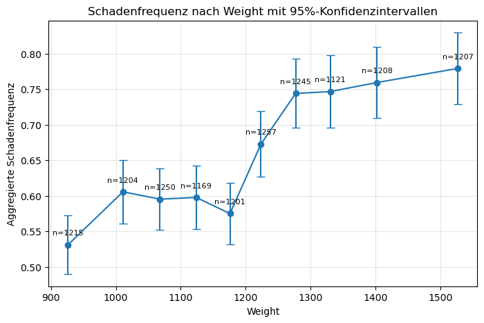

```python
# =========================
# Train + Valid kombinieren
# =========================

df_train = pd.DataFrame({
    "Weight": X_train["Weight"],
    "N_claims_year": y_train,
    "Exposure": X_train["Exposure"]
})

df_valid = pd.DataFrame({
    "Weight": X_valid["Weight"],
    "N_claims_year": y_valid,
    "Exposure": X_valid["Exposure"]
})

df_power = pd.concat([df_train, df_valid], axis=0).reset_index(drop=True)

# =========================
# Ausreißer in Power begrenzen
# =========================

lower = df_power["Weight"].quantile(0.025)
upper = df_power["Weight"].quantile(0.975)

df_power_plot = df_power[
    (df_power["Weight"] >= lower) &
    (df_power["Weight"] <= upper)
].copy()

# =========================
# Power in Quantil-Bins einteilen
# =========================

df_power_plot["Weight_bin"] = pd.qcut(
    df_power_plot["Weight"],
    q=10,
    duplicates="drop"
)

# =========================
# Aggregation je Bin
# =========================

power_summary = (
    df_power_plot
    .groupby("Weight_bin", observed=True)
    .agg(
        Weight_mean=("Weight", "mean"),
        claims_sum=("N_claims_year", "sum"),
        exposure_sum=("Exposure", "sum"),
        n_obs=("N_claims_year", "size")
    )
    .reset_index()
)

power_summary["Frequency"] = (
    power_summary["claims_sum"] / power_summary["exposure_sum"]
)

# =========================
# Approx. Standardfehler und 95%-KI
# Poisson-Annahme: Var(Claims) ≈ Expected Claims
# SE(Frequency) ≈ sqrt(claims_sum) / exposure_sum
# =========================

power_summary["se_frequency"] = (
    np.sqrt(power_summary["claims_sum"]) / power_summary["exposure_sum"]
)

power_summary["ci_lower"] = (
    power_summary["Frequency"] - 1.96 * power_summary["se_frequency"]
)

power_summary["ci_upper"] = (
    power_summary["Frequency"] + 1.96 * power_summary["se_frequency"]
)

power_summary["ci_lower"] = power_summary["ci_lower"].clip(lower=0)

display(power_summary)

# =========================
# Plot mit Error Bars und n pro Bin
# =========================

plt.figure(figsize=(8, 5))

plt.errorbar(
    power_summary["Weight_mean"],
    power_summary["Frequency"],
    yerr=[
        power_summary["Frequency"] - power_summary["ci_lower"],
        power_summary["ci_upper"] - power_summary["Frequency"]
    ],
    fmt="o-",
    capsize=4
)

# Anzahl Beobachtungen pro Bin anzeigen
for _, row in power_summary.iterrows():
    plt.annotate(
        f"n={int(row['n_obs'])}",
        xy=(row["Weight_mean"], row["Frequency"]),
        xytext=(0, 10),
        textcoords="offset points",
        ha="center",
        fontsize=8
    )

plt.xlabel("Weight")
plt.ylabel("Aggregierte Schadenfrequenz")
plt.title("Schadenfrequenz nach Weight mit 95%-Konfidenzintervallen")
plt.grid(alpha=0.3)
plt.show()
```

#### `Power` vs. `Weight` - Entscheidung

Darüber hinaus ist `Power` direkt mit dem Fahrverhalten (z. B. Beschleunigung und Geschwindigkeit) verbunden und daher als Risikofaktor kausal besser interpretierbar als `Weight`.

Aus diesen Gründen wird `Power` für die Monotoniebeschränkung verwendet.

### Monotonie-Vektor

```python
feature_names = X_train_tree.columns.tolist()

monotone_constraints = [0] * len(feature_names)

power_idx = feature_names.index("Power")
monotone_constraints[power_idx] = 1   # monoton steigend
print("Alle  Features:", feature_names)

print("Steigende Monotonie für Feature:", feature_names[power_idx])
```

```
Alle  Features: ['Seniority', 'Lapse', 'Power', 'Cylinder_capacity', 'Value_vehicle', 'Weight', 'DrivAge', 'DrivLicenceAge', 'VehAge', 'Distribution_channel_1', 'Payment_1', 'Area_1', 'Second_driver_1', 'N_doors_3', 'N_doors_4', 'N_doors_5', 'N_doors_6', 'Type_fuel_P']
Steigende Monotonie für Feature: Power
```

### XGBoost und LightGBM mit Monotonie

```python
#LightGBM mit Mono
params_lgb_mono = best_params_lgb.copy()
params_lgb_mono.update({
    "monotone_constraints": monotone_constraints
})
start_time = time.time()
lgb_mono = lgb.LGBMRegressor(**params_lgb_mono)
lgb_mono.fit(
   X_train_tree,
    freq_train,
    sample_weight=exposure_train,
     eval_set=[(X_valid_tree, freq_valid)],
     eval_sample_weight=[exposure_valid],
    callbacks=[lgb.early_stopping(10, verbose=False)]
)
fit_time_m_lgb = fit_time_lgb + (time.time() - start_time)
freq_pred_train_m_lgb = lgb_mono.predict(X_train_tree)
freq_pred_valid_m_lgb = lgb_mono.predict(X_valid_tree)
# Frequenz darf nicht negativ sein
freq_pred_train_m_lgb = np.clip(freq_pred_train_m_lgb, 1e-12, None)
freq_pred_valid_m_lgb = np.clip(freq_pred_valid_m_lgb, 1e-12, None)
# erwartete Schadenanzahl = Frequenz * Exposure
pred_train_m_lgb = freq_pred_train_m_lgb * exposure_train
pred_valid_m_lgb = freq_pred_valid_m_lgb * exposure_valid
fit_and_predict_time_m_lgb = fit_time_lgb+(time.time() - start_time)
pdw_train_m_lgb = PDW(pred_train_m_lgb, y_train_tree,exposure_train)
pdw_valid_m_lgb= PDW(pred_valid_m_lgb, y_valid_tree,exposure_valid)
cf_train_actual = CF_calculate(y_train_tree, exposure_train)
cf_train_pred   = CF_calculate(pred_train_m_lgb, exposure_train)
cf_valid_actual = CF_calculate(y_valid_tree, exposure_valid)
cf_valid_pred   = CF_calculate(pred_valid_m_lgb, exposure_valid)

model_results_df = add_model_result(
    model_results_df=model_results_df,
    model_name="LightGBM mit Monotonie",
    metric_name="PDW",
    metric_train=pdw_train_m_lgb ,
    metric_valid=pdw_valid_m_lgb,
    metric_test=np.nan,
    fit_time_sec=fit_time_m_lgb,
    fit_and_predict_time_sec=fit_and_predict_time_m_lgb,
    CF_train_act=cf_train_actual,
    CF_train_pred=cf_train_pred,
    CF_valid_act=cf_valid_actual,
    CF_valid_pred=cf_valid_pred,
    CF_test_act=np.nan,
    CF_test_pred=np.nan,
    notes=f"Das beste LightGBM Modell mit Monotonie: Power +1"
)

#XGBoost mit Mono
params_xgb_mono = best_params_xgb.copy()
params_xgb_mono.update({
    "monotone_constraints": tuple(monotone_constraints)
})
start_time = time.time()
xgb_mono = xgb.XGBRegressor(**params_xgb_mono)
xgb_mono.fit(
    X_train_tree,
    freq_train,
    sample_weight=exposure_train,
    eval_set=[(X_valid_tree, freq_valid)],
    sample_weight_eval_set=[exposure_valid],
    verbose=False
)
fit_time_m_xgb = fit_time_xgb + (time.time() - start_time)
freq_pred_train_m_xgb = xgb_mono.predict(X_train_tree)
freq_pred_valid_m_xgb = xgb_mono.predict(X_valid_tree)
# Frequenz darf nicht negativ sein
freq_pred_train_m_xgb = np.clip(freq_pred_train_m_xgb, 1e-12, None)
freq_pred_valid_m_xgb = np.clip(freq_pred_valid_m_xgb, 1e-12, None)
# erwartete Schadenanzahl = Frequenz * Exposure
pred_train_m_xgb = freq_pred_train_m_xgb * exposure_train
pred_valid_m_xgb = freq_pred_valid_m_xgb * exposure_valid
fit_and_predict_time_m_xgb = fit_time_xgb+(time.time() - start_time)
pdw_train_m_xgb = PDW(pred_train_m_xgb, y_train_tree,exposure_train)
pdw_valid_m_xgb= PDW(pred_valid_m_xgb, y_valid_tree,exposure_valid)
cf_train_actual = CF_calculate(y_train_tree, exposure_train)
cf_train_pred   = CF_calculate(pred_train_m_xgb, exposure_train)
cf_valid_actual = CF_calculate(y_valid_tree, exposure_valid)
cf_valid_pred   = CF_calculate(pred_valid_m_xgb, exposure_valid)

model_results_df = add_model_result(
    model_results_df=model_results_df,
    model_name="XGBoost mit Monotonie",
    metric_name="PDW",
    metric_train=pdw_train_m_lgb ,
    metric_valid=pdw_valid_m_lgb,
    metric_test=np.nan,
    fit_time_sec=fit_time_m_lgb,
    fit_and_predict_time_sec=fit_and_predict_time_m_lgb,
    CF_train_act=cf_train_actual,
    CF_train_pred=cf_train_pred,
    CF_valid_act=cf_valid_actual,
    CF_valid_pred=cf_valid_pred,
    CF_test_act=np.nan,
    CF_test_pred=np.nan,
    notes=f"Das beste XGBoost Modell mit Monotonie: Power +1"
)
```

```python
show_model_results(
    model_results_df,
    metric="PDW",
    sort_by="metric_valid",
    ascending=True,
    digits=4
)
```

|  | model_name | metric_name | metric_train | metric_valid | metric_test | fit_time_sec | fit_and_predict_time_sec | CF_train_act | CF_train_pred | CF_valid_act | CF_valid_pred | CF_test_act | CF_test_pred | notes |
| --- | --- | --- | --- | --- | --- | --- | --- | --- | --- | --- | --- | --- | --- | --- |
| 0 | XGBoost | PDW | 1.572300 | 1.525100 | NaN | 1.398600 | 1.467800 | 67.2597 % | 67.2251 % | 59.1986 % | 66.5718 % | NaN | NaN | Optuna Trials=50, opt_time=131.57s |
| 1 | LightGBM mit Monotonie | PDW | 1.602300 | 1.528500 | NaN | 1.636700 | 2.024200 | 67.2597 % | 67.2687 % | 59.1986 % | 66.4131 % | NaN | NaN | Das beste LightGBM Modell mit Monotonie: Power +1 |
| 2 | XGBoost mit Monotonie | PDW | 1.602300 | 1.528500 | NaN | 1.636700 | 2.024200 | 67.2597 % | 67.2257 % | 59.1986 % | 66.5736 % | NaN | NaN | Das beste XGBoost Modell mit Monotonie: Power +1 |
| 3 | LightGBM | PDW | 1.602600 | 1.528600 | NaN | 0.751200 | 1.135100 | 67.2597 % | 67.2865 % | 59.1986 % | 66.4319 % | NaN | NaN | Optuna Trials=50, opt_time=59.13s |
| 4 | RF | PDW | 1.552400 | 1.530900 | NaN | 6.435800 | 7.016300 | 67.2597 % | 67.2278 % | 59.1986 % | 66.5804 % | NaN | NaN | Random Forest mit Poisson-Kriterium, max_featu... |
| 5 | Bagging | PDW | 1.580500 | 1.531100 | NaN | 26.712100 | 27.624500 | 67.2597 % | 67.2105 % | 59.1986 % | 66.5944 % | NaN | NaN | Bagging mit Poisson-Kriterium, max_features=1.... |
| 6 | GLM | PDW | 1.643600 | 1.532900 | NaN | 0.234300 | 0.418400 | 67.2597 % | 67.2597 % | 59.1986 % | 66.2701 % | NaN | NaN | Poisson-GLM mit vollständigem Featureset und O... |
| 7 | CANN | PDW | 1.642900 | 1.540300 | NaN | 8.053900 | 8.939600 | 67.2597 % | 67.0552 % | 59.1986 % | 66.0535 % | NaN | NaN | CANN ohne Embeddings; GLM-Skip-Connection über... |
| 8 | LASSO | PDW | 1.643700 | 1.541000 | NaN | 4.322000 | 4.323500 | 67.2597 % | 67.3108 % | 59.1986 % | 66.347 % | NaN | NaN | alpha=0.0005, l1_wt=1.0 (fixiert) |
| 9 | Intercept-Only Baseline(INT) | PDW | 1.716800 | 1.633900 | NaN | 0.004100 | 0.004100 | 67.2597 % | 67.2597 % | 59.1986 % | 67.2597 % | NaN | NaN | baseline_frequency=67.2597%, intercept=-0.3966 |
| 10 | Intercept-Only Baseline(mit GLM) | PDW | 1.716800 | 1.633900 | NaN | 0.042900 | 0.046700 | 67.2597 % | 67.2597 % | 59.1986 % | 67.2597 % | NaN | NaN | baseline_frequency=67.2597%, intercept=-0.3966 |

### PDP (2×2 Grid)

```
LGB: True
LGB mono: True
XGB: False
XGB mono: True
```

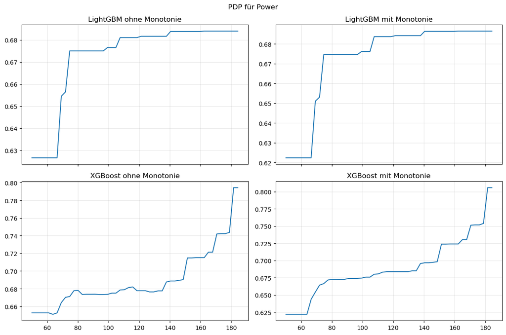

```python
#manueller PDP
def manual_pdp(model, X, feature, grid):
    X_temp = X.copy()
    pdp = []

    for val in grid:
        X_temp[feature] = val
        pred = np.clip(model.predict(X_temp), 1e-12, None)
        pdp.append(np.mean(pred))

    return np.array(pdp)
#Grid definieren
feature = "Power"

grid = np.linspace(
    X_valid_tree[feature].quantile(0.01),
    X_valid_tree[feature].quantile(0.99),
    50
)
#PDP berechnen
pdp_lgb = manual_pdp(final_lgb, X_valid_tree, feature, grid)
pdp_lgb_mono = manual_pdp(lgb_mono, X_valid_tree, feature, grid)

pdp_xgb = manual_pdp(final_xgb, X_valid_tree, feature, grid)
pdp_xgb_mono = manual_pdp(xgb_mono, X_valid_tree, feature, grid)
#Monotonie prüfen
def check_monotone(y):
    return np.all(np.diff(y) >= -1e-10)

print("LGB:", check_monotone(pdp_lgb))
print("LGB mono:", check_monotone(pdp_lgb_mono))
print("XGB:", check_monotone(pdp_xgb))
print("XGB mono:", check_monotone(pdp_xgb_mono))
# 2x2 Plot
fig, axes = plt.subplots(2, 2, figsize=(12, 8), sharex=True)

axes[0,0].plot(grid, pdp_lgb)
axes[0,0].set_title("LightGBM ohne Monotonie")

axes[0,1].plot(grid, pdp_lgb_mono)
axes[0,1].set_title("LightGBM mit Monotonie")

axes[1,0].plot(grid, pdp_xgb)
axes[1,0].set_title("XGBoost ohne Monotonie")

axes[1,1].plot(grid, pdp_xgb_mono)
axes[1,1].set_title("XGBoost mit Monotonie")

for ax in axes.flat:
    ax.grid(alpha=0.3)

plt.suptitle("PDP für Power")
plt.tight_layout()
plt.show()
```

#### Interpretation der Partial Dependence Plots (PDPs)

Die PDP-Plots für `Power` zeigen insgesamt einen positiven Zusammenhang zwischen Motorleistung und vorhergesagter Schadenhäufigkeit. Mit steigender Leistung nimmt die prognostizierte Frequency tendenziell zu, was versicherungstechnisch plausibel ist, da leistungsstärkere Fahrzeuge häufig mit höherem Fahrverhaltenrisiko oder höheren Schadenerwartungen verbunden sein können.

Bei **LightGBM** verlaufen die Kurven mit und ohne Monotonie sehr ähnlich. Beide zeigen einen deutlichen Sprung im Bereich von ungefähr `65` bis `75` und danach einen eher flachen, aber weiterhin leicht steigenden Verlauf. Die Monotoniebedingung wirkt hier stabilisierend, verändert das Modellverhalten aber nur geringfügig, da das ursprüngliche LightGBM-Modell bereits weitgehend monoton war.

Bei **XGBoost ohne Monotonie** ist der Verlauf weniger glatt und enthält kleinere lokale Rückgänge beziehungsweise Plateaus. Das bedeutet, dass das Modell ohne Einschränkung nicht überall einen streng monoton steigenden Zusammenhang zwischen `Power` und Schadenhäufigkeit lernt. Besonders im mittleren Bereich ist die Kurve etwas unruhiger, bevor sie bei hohen Power-Werten deutlich ansteigt.

Das **XGBoost-Modell mit Monotonie** zeigt dagegen einen klarer monoton steigenden Verlauf. Dadurch wird die versicherungstechnische Annahme erzwungen, dass höhere Motorleistung nicht zu einer niedrigeren erwarteten Schadenhäufigkeit führen sollte. Insgesamt erscheinen die Modelle mit Monotonie fachlich plausibler und stabiler, da sie zufällige lokale Schwankungen reduzieren und den erwarteten Risikozusammenhang konsistenter abbilden.

#### Bewertung des Performance-Verlusts durch Monotoniebeschränkung

### Bewertung des Performance-Verlusts durch Monotoniebeschränkung

Beim **LightGBM-Modell** ist der Performance-Gewinn praktisch vernachlässigbar: Die Validierungs-PDW singt nur minimal von $1.5286$ auf $1.5285$ beziehungsweise bleibt nahezu unverändert.

d) Auswertung und Interpretation der Modelle am Testset

Evaluieren und vergleichen Sie alle trainierten Modelle auf dem Testdatensatz (Intercept-Only, GLM, LASSO, neuronales Netzwerk, Bagging, Random Forest, LightGBM, XGBoost sowie Varianten mit Monotoniebeschränkungen). Die Auswertung umfasst Modellgüte (Poisson-Devianz) und Kalibrierung. Berechnen Sie für jedes Modell die Poisson-Devianz auf dem Testdatensatz, ergänzen Sie die Ergebnisdatenstruktur und erstellen Sie eine vergleichende Grafik der Poisson-Devianz auf Training, Validierung und Test. Interpretieren Sie die Ergebnisse. Identifizieren Sie das beste Modell nach Test-Performance, quantifizieren Sie die Verbesserung gegenüber dem Baseline-Modell und diskutieren Sie mögliche Anzeichen von Overfitting. Prüfen Sie die globale Kalibrierung, indem Sie für jedes Modell vergleichen, ob die Summe der vorhergesagten Schäden der Summe der beobachteten Schäden entspricht. Berechnen Sie dazu das Verhältnis Actual/Expected. Prüfen Sie die Kalibrierung nach Risikogruppen: Teilen Sie das Testset in Dezile basierend auf den vorhergesagten Schadenfrequenzen ein und vergleichen Sie je Dezil beobachtete vs. erwartete Schadenfrequenz. Erstellen Sie für alle Modelle geeignete Visualisierungen (mindestens Actual-vs.-Expected nach Dezilen und ein gemeinsames Lift-Chart) und geben Sie eine abschließende Bewertung der Modellkalibrierung und Risikodifferenzierung ab.

## **Lösung:**

### Methodische Diskussion: Verwendung des Testdatensatzes

In Teilaufgabe B1b) wurde festgelegt, dass der Testdatensatz ausschließlich zur Bewertung des final ausgewählten Modells verwendet wird. Dies entspricht der klassischen Trennung zwischen Modellselektion (Train/Valid) und Modellbewertung (Test), wie sie in der Literatur empfohlen wird (z. B. *The Elements of Statistical Learning*).

Die Aufgabenstellung in Teilaufgabe B2d) fordert jedoch, alle Modelle auf dem Testdatensatz zu evaluieren und auf Basis der Testperformance das beste Modell auszuwählen. Dies steht im Widerspruch zur ursprünglichen Methodik, da der Testdatensatz in diesem Fall implizit für die Modellauswahl verwendet wird.

#### Einordnung des Widerspruchs

- **Streng methodisch korrekt:**
  - Die Modellauswahl erfolgt ausschließlich anhand der Validierungsdaten.
  - Der Testdatensatz wird nur einmal zur finalen Bewertung verwendet.
- **Aufgabenstellung B2d):**
  - Vergleich aller Modelle auf dem Testdatensatz
  - Auswahl des besten Modells basierend auf der Testperformance

Damit wird der Testdatensatz faktisch Teil des Modellselektionsprozesses, was zu einer optimistischen Verzerrung der geschätzten Generalisierungsfähigkeit führen kann.

#### Vorgehen in dieser Arbeit

Um die Anforderungen der Aufgabenstellung zu erfüllen, wird folgender Kompromiss gewählt:

1. Alle Modelle werden auf dem Testdatensatz evaluiert, um die geforderte Vergleichsanalyse durchzuführen.
2. Die Ergebnisse werden jedoch **nicht als unverzerrte Schätzung der Generalisierungsfähigkeit interpretiert**, sondern als relativer Vergleich zwischen den Modellen.

Die Verwendung des Testdatensatzes in Teilaufgabe B2d) dient somit primär der vergleichenden Analyse der Modelle und weniger einer strikt methodisch sauberen Modellbewertung.

#### Refit : Hier kein Refit auf Training + Validierung

In der vorliegenden Arbeit wurden Optuna sowie die Implementierungen von LightGBM und XGBoost verwendet, die kein automatisches Refit durchführen. Aus Gründen der Fairness wurden alle Modelle (einschließlich des Intercept-Only-Modells) einheitlich ausschließlich auf dem Trainingsdatensatz trainiert, sodass kein Modell einen Vorteil durch die Nutzung zusätzlicher Daten erhält.

### Vergleich der Poisson-Devianz auf Training, Validierung und Test

```python
# Vorhersage auf dem Testdatensatz für alle Modelle
results_test = []

#1. Modell: Intercept-Only
model_name="Intercept-Only Baseline(INT)"
pred_test_int= exposure_test * baseline_frequency
pdw_test_int= PDW(pred_test_int, obs_test,exposure_test)
cf_test_act=CF_calculate(obs_test, exposure_test)
cf_test_pred_int=CF_calculate(pred_test_int, exposure_test)#=baseline_frequency,da es Intercept-Only Basis Modell ist
results_test.append((model_name, pdw_test_int,cf_test_act,cf_test_pred_int))
model_name="Intercept-Only Baseline(mit GLM)"
results_test.append((model_name, pdw_test_int,cf_test_act,cf_test_pred_int))

# 2. GLM Modell
model_name="GLM"
pred_test_glm= glm_full.predict(X_test, offset=np.log(X_test["Exposure"]))

pdw_test_glm= PDW(pred_test_glm, obs_test,exposure_test)

cf_test_pred_glm=CF_calculate(pred_test_glm,exposure_test)

results_test.append((model_name, pdw_test_glm,cf_test_act,cf_test_pred_glm))

# 3. LASSO

model_name="LASSO"
pred_test_lasso= lasso_final_result.predict(X_test_lasso_scaled_const, offset=offset_test)

pdw_test_lasso=PDW(pred_test_lasso, obs_test,exposure_test)

cf_test_pred_lasso=CF_calculate(pred_test_lasso,exposure_test)

results_test.append((model_name, pdw_test_lasso,cf_test_act,cf_test_pred_lasso))


#4. CANN
model_name="CANN"
    # CANN verwendet log(LASSO-Vorhersage) als Skip-Connection
pred_test_lasso= np.asarray(lasso_final_result.predict(X_test_lasso_scaled_const, offset=offset_test)).astype("float32")
pred_test_lasso = np.clip(pred_test_lasso, 1e-12, None)
log_pred_test_lasso = np.log(pred_test_lasso).reshape(-1, 1).astype("float32")
exposure_test = np.asarray(X_test["Exposure"]).astype("float32")

pred_test_cann= model_cann.predict([X_test_cann_mat, log_pred_test_lasso]).reshape(-1)
pred_test_cann= np.clip(pred_test_cann, 1e-12, None)

pdw_test_cann= PDW(pred_test_cann, y_test_cann,exposure_test)

cf_test_pred_cann= CF_calculate(pred_test_cann,exposure_test)

results_test.append((model_name, pdw_test_cann,cf_test_act,cf_test_pred_cann))

#Bagging - Bagging Model
model_name="Bagging"
freq_pred_test_bagging = bagging_model.predict(X_test_tree)
freq_pred_test_bagging= np.clip(freq_pred_test_bagging, 1e-12, None)
# erwartete Schadenanzahl = Frequenz * Exposure
pred_test_bagging = freq_pred_test_bagging * exposure_test

pdw_test_bagging = PDW(pred_test_bagging, y_test_tree,exposure_test)

cf_test_pred_bagging = CF_calculate(pred_test_bagging, exposure_test)
results_test.append((model_name, pdw_test_bagging,cf_test_act,cf_test_pred_bagging))

#Random Forest -rf_model
model_name="RF"
freq_pred_test_rf = rf_model.predict(X_test_tree)
freq_pred_test_rf = np.clip(freq_pred_test_rf, 1e-12, None)

pred_test_rf = freq_pred_test_rf * exposure_test

pdw_test_rf = PDW(pred_test_rf, y_test_tree,exposure_test)

cf_test_pred_rf   = CF_calculate(pred_test_rf, exposure_test)

results_test.append((model_name, pdw_test_rf,cf_test_act,cf_test_pred_rf))

#LightGBM
model_name="LightGBM"
freq_pred_test_lgb = final_lgb.predict(X_test_tree)
pred_test_lgb = freq_pred_test_lgb * exposure_test

pdw_test_lgb = PDW(pred_test_lgb, y_test_tree,exposure_test)

cf_test_pred_lgb  = CF_calculate(pred_test_lgb, exposure_test)
results_test.append((model_name, pdw_test_lgb,cf_test_act,cf_test_pred_lgb))

#XGBoost
model_name="XGBoost"

freq_pred_test_xgb = final_xgb.predict(X_test_tree)
freq_pred_test_xgb = np.clip(freq_pred_test_xgb, 1e-12, None)

pred_test_xgb = freq_pred_test_xgb * exposure_test

pdw_test_xgb = PDW(pred_test_xgb, y_test_tree,exposure_test)

cf_test_pred_xgb = CF_calculate(pred_test_xgb, exposure_test)
results_test.append((model_name, pdw_test_xgb,cf_test_act,cf_test_pred_xgb))

 #LightGBM mit Monotoniebeschränkung
model_name="LightGBM mit Monotonie"
freq_pred_test_m_lgb =lgb_mono.predict(X_test_tree)
pred_test_m_lgb = freq_pred_test_m_lgb * exposure_test

pdw_test_m_lgb = PDW(pred_test_m_lgb, y_test_tree,exposure_test)

cf_test_pred_m_lgb  = CF_calculate(pred_test_m_lgb, exposure_test)
results_test.append((model_name, pdw_test_m_lgb,cf_test_act,cf_test_pred_m_lgb))

#XGBoost mit Monotoniebeschränkung
model_name="XGBoost mit Monotonie"

freq_pred_test_m_xgb = xgb_mono.predict(X_test_tree)
freq_pred_test_m_xgb = np.clip(freq_pred_test_m_xgb, 1e-12, None)

pred_test_m_xgb = freq_pred_test_m_xgb * exposure_test

pdw_test_m_xgb = PDW(pred_test_m_xgb,y_test_tree,exposure_test)

cf_test_pred_m_xgb = CF_calculate(pred_test_m_xgb, exposure_test)
results_test.append((model_name, pdw_test_m_xgb,cf_test_act,cf_test_pred_m_xgb))
```

```python
results_test_df = pd.DataFrame(results_test, columns=["model_name", "pdw_test","cf_test_act","cf_test_pred"])
results_test_df = results_test_df.sort_values("pdw_test")

display(results_test_df)
for model_name, pdw_test,cf_test_act,cf_test_pred in results_test:
    model_results_df.loc[
        model_results_df["model_name"] == model_name,
        "metric_test"
    ] = pdw_test
    model_results_df.loc[
        model_results_df["model_name"] == model_name,
        "CF_test_act"
    ] = cf_test_act
    model_results_df.loc[
        model_results_df["model_name"] == model_name,
        "CF_test_pred"
    ] = cf_test_pred
```

|  | model_name | pdw_test | cf_test_act | cf_test_pred |
| --- | --- | --- | --- | --- |
| 7 | LightGBM | 1.595089 | 0.657340 | 0.678226 |
| 9 | LightGBM mit Monotonie | 1.595387 | 0.657340 | 0.677984 |
| 10 | XGBoost mit Monotonie | 1.595432 | 0.657340 | 0.676061 |
| 8 | XGBoost | 1.596098 | 0.657340 | 0.676116 |
| 6 | RF | 1.599974 | 0.657340 | 0.676021 |
| 5 | Bagging | 1.602240 | 0.657340 | 0.676623 |
| 3 | LASSO | 1.602935 | 0.657340 | 0.678965 |
| 2 | GLM | 1.603521 | 0.657340 | 0.678307 |
| 4 | CANN | 1.604789 | 0.657340 | 0.699333 |
| 0 | Intercept-Only Baseline(INT) | 1.684107 | 0.657340 | 0.672597 |
| 1 | Intercept-Only Baseline(mit GLM) | 1.684107 | 0.657340 | 0.672597 |

```python
# Bestes Modell anhand Test-PDW
best_row = model_results_df.loc[
    model_results_df["metric_test"].idxmin()
]

best_model_name = best_row["model_name"]
best_pdw = best_row["metric_test"]

print("Bestes Modell:", best_model_name)
print("Test-PDW:", best_pdw)
# Verbesserung gegenüber Intercept-Only berechnen
baseline_pdw = model_results_df.loc[
    model_results_df["model_name"].str.contains("Intercept"),
    "metric_test"
].values[0]

print("Baseline PDW:", baseline_pdw)
improvement = (baseline_pdw - best_pdw) / baseline_pdw * 100

print(f"Verbesserung gegenüber Baseline: {improvement:.2f}%")
```

```
Bestes Modell: LightGBM
Test-PDW: 1.5950885775437809
Baseline PDW: 1.684106874606303
Verbesserung gegenüber Baseline: 5.29%
```

#### Bestes Modell und Verbesserung gegenüber Baseline

Im Vergleich dazu weist das Baseline-Modell (Intercept-Only) eine Poisson-Devianz von **1.684** auf. Daraus ergibt sich eine Verbesserung von **5.29%**.

Diese Verbesserung zeigt, dass das Modell zusätzliche Information aus den erklärenden Variablen nutzt und die Schadenfrequenz besser modelliert als ein einfaches Durchschnittsmodell. Gleichzeitig ist die Verbesserung jedoch moderat, was darauf hindeutet, dass ein Großteil der Variation der Schadenanzahl entweder durch die vorhandenen Features nur begrenzt erklärbar ist oder dass die zugrunde liegenden Zusammenhänge relativ einfach strukturiert sind.

Insgesamt zeigt das Ergebnis, dass komplexere Modelle zwar einen Vorteil gegenüber der Baseline bieten, die Zugewinne jedoch begrenzt sind. Dies unterstreicht die Bedeutung einer sorgfältigen Modellwahl und legt nahe, dass auch einfachere Modelle wie das GLM bereits einen Großteil der erklärbaren Struktur erfassen.

#### Finale Ergebnisse

Die finalen Modellergebnisse werden nach der Performance auf dem **Testdatensatz** sortiert.

```python
show_model_results(
    model_results_df,
    metric="PDW",
    sort_by="metric_test",
    ascending=True,
    digits=4
)
```

|  | model_name | metric_name | metric_train | metric_valid | metric_test | fit_time_sec | fit_and_predict_time_sec | CF_train_act | CF_train_pred | CF_valid_act | CF_valid_pred | CF_test_act | CF_test_pred | notes |
| --- | --- | --- | --- | --- | --- | --- | --- | --- | --- | --- | --- | --- | --- | --- |
| 0 | LightGBM | PDW | 1.602600 | 1.528600 | 1.595100 | 0.751200 | 1.135100 | 67.2597 % | 67.2865 % | 59.1986 % | 66.4319 % | 65.734 % | 67.8226 % | Optuna Trials=50, opt_time=59.13s |
| 1 | LightGBM mit Monotonie | PDW | 1.602300 | 1.528500 | 1.595400 | 1.636700 | 2.024200 | 67.2597 % | 67.2687 % | 59.1986 % | 66.4131 % | 65.734 % | 67.7984 % | Das beste LightGBM Modell mit Monotonie: Power +1 |
| 2 | XGBoost mit Monotonie | PDW | 1.602300 | 1.528500 | 1.595400 | 1.636700 | 2.024200 | 67.2597 % | 67.2257 % | 59.1986 % | 66.5736 % | 65.734 % | 67.6061 % | Das beste XGBoost Modell mit Monotonie: Power +1 |
| 3 | XGBoost | PDW | 1.572300 | 1.525100 | 1.596100 | 1.398600 | 1.467800 | 67.2597 % | 67.2251 % | 59.1986 % | 66.5718 % | 65.734 % | 67.6116 % | Optuna Trials=50, opt_time=131.57s |
| 4 | RF | PDW | 1.552400 | 1.530900 | 1.600000 | 6.435800 | 7.016300 | 67.2597 % | 67.2278 % | 59.1986 % | 66.5804 % | 65.734 % | 67.6021 % | Random Forest mit Poisson-Kriterium, max_featu... |
| 5 | Bagging | PDW | 1.580500 | 1.531100 | 1.602200 | 26.712100 | 27.624500 | 67.2597 % | 67.2105 % | 59.1986 % | 66.5944 % | 65.734 % | 67.6623 % | Bagging mit Poisson-Kriterium, max_features=1.... |
| 6 | LASSO | PDW | 1.643700 | 1.541000 | 1.602900 | 4.322000 | 4.323500 | 67.2597 % | 67.3108 % | 59.1986 % | 66.347 % | 65.734 % | 67.8965 % | alpha=0.0005, l1_wt=1.0 (fixiert) |
| 7 | GLM | PDW | 1.643600 | 1.532900 | 1.603500 | 0.234300 | 0.418400 | 67.2597 % | 67.2597 % | 59.1986 % | 66.2701 % | 65.734 % | 67.8307 % | Poisson-GLM mit vollständigem Featureset und O... |
| 8 | CANN | PDW | 1.642900 | 1.540300 | 1.604800 | 8.053900 | 8.939600 | 67.2597 % | 67.0552 % | 59.1986 % | 66.0535 % | 65.734 % | 69.9333 % | CANN ohne Embeddings; GLM-Skip-Connection über... |
| 9 | Intercept-Only Baseline(INT) | PDW | 1.716800 | 1.633900 | 1.684100 | 0.004100 | 0.004100 | 67.2597 % | 67.2597 % | 59.1986 % | 67.2597 % | 65.734 % | 67.2597 % | baseline_frequency=67.2597%, intercept=-0.3966 |
| 10 | Intercept-Only Baseline(mit GLM) | PDW | 1.716800 | 1.633900 | 1.684100 | 0.042900 | 0.046700 | 67.2597 % | 67.2597 % | 59.1986 % | 67.2597 % | 65.734 % | 67.2597 % | baseline_frequency=67.2597%, intercept=-0.3966 |

#### Overfitting Diskussion beim besten Modell

Ein Overfitting ist nicht erkennbar. Bei klassischem Overfitting würde man erwarten, dass die Trainingsperformance deutlich besser ist als die Validierungs- oder Testperformance. Das ist hier nicht der Fall: Die Trainings-PDW ist nicht niedriger, sondern sogar höher als die Validierungs-PDW und nur leicht höher als die Test-PDW.

#### Grafik der Poisson-Devianz auf Training, Validierung und Test

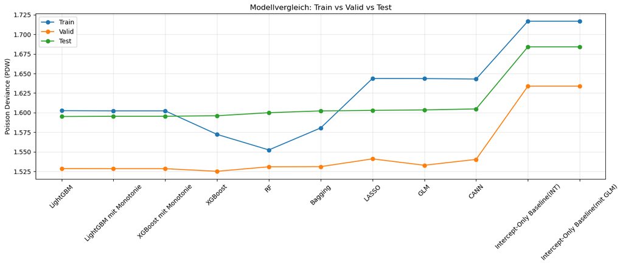

```python
df_plot = model_results_df.sort_values("metric_test").copy()

plt.figure(figsize=(14, 6))

plt.plot(df_plot["model_name"], df_plot["metric_train"], marker="o", label="Train")
plt.plot(df_plot["model_name"], df_plot["metric_valid"], marker="o", label="Valid")
plt.plot(df_plot["model_name"], df_plot["metric_test"], marker="o", label="Test")

plt.xticks(rotation=45)
plt.ylabel("Poisson Deviance (PDW)")
plt.title("Modellvergleich: Train vs Valid vs Test")
plt.legend()
plt.grid(alpha=0.3)

plt.tight_layout()
plt.show()
```

#### Interpretation: Modellvergleich (Train vs. Valid vs. Test)

Der Modellvergleich zeigt die Poisson-Deviance / PDW auf Trainings-, Validierungs- und Testdaten. Da niedrigere Werte besser sind, schneiden die Boosting-Modelle insgesamt am besten ab.

##### Beste Modelle

Die beste Testperformance erreicht:

1. **LightGBM**
2. **LightGBM mit Monotonie**
3. **XGBoost mit Monotonie**

Diese Modelle liegen auf dem Testdatensatz sehr nah beieinander. Das zeigt, dass Boosting-Verfahren die nichtlinearen Zusammenhänge und Interaktionen in den Daten besser erfassen als GLM, LASSO oder CANN.

##### Overfitting / Underfitting

Ein Overfitting ist bei den besten Modellen nicht erkennbar. Die Testwerte liegen relativ nah an den Trainingswerten.

##### Validierung vs. Test

Auffällig ist, dass die Validierungs-PDW bei allen Modellen niedriger ist als die Test-PDW. Das deutet darauf hin, dass der Validierungsdatensatz leichter zu prognostizieren war.

##### Monotoniebeschränkung

Die Modelle mit Monotoniebeschränkung schneiden sehr gut ab. Das zeigt, dass fachliche Plausibilität nicht zwangsläufig zu einem relevanten Performanceverlust führen muss.